# 免费:商业的未来（精编图文版）（中信商业经典） (信经典)

### 案例二：雅虎Vs.Google

2004年4月1日，Google公司发布了一篇新闻稿，宣称自己将推出新的网络邮箱Gmail服务。因为Google公司向来都喜欢在愚人节这天发表玩笑性质的假新闻，因此有人质疑这消息是否属实。

但是位于Google公司总部南边6英里的雅虎公司总部，那里的员工则认为Google发布的消息是千真万确的。雅虎高管们几年前就预料到这一天会到来，因为他们得悉Google公司将推出自己的邮箱服务，并注册了gmail.com网站。

雅虎无疑是最大的电子邮箱提供商，其用户总数超过1.25亿人。这是很好的一项生意，当时大多数用户使用的是雅虎的免费邮箱，总容量为10MB。如果人们想要更大的邮箱，那么就申请总容量为25MB或是100MB的付费版本，这些付费邮箱还可以免除广告的侵扰。雅虎的生意很赚钱，而它相较于对手微软和美国在线的领先优势也在逐渐扩大。

但是，2004年年初，Google有意进入邮件市场的传言让雅虎的高管夜不能寐了。这倒不是Google对所有接触的业务都有点石成金的能力，而是有传言说Google将推出1G的免费邮箱，容量达到了雅虎当时免费邮箱容量的100倍。

雅虎的高管丹·罗森维格、布拉德·加林豪斯和中山戴夫赶紧聚在一起商量对策。雅虎必须要采取对策，因为Google的风头很劲，如果有这个打算的话，会一下子抢走雅虎很大的一块市场。如果Gmail邮箱真要提供1G的免费储存空间，那么雅虎想要比肩的话，对公司而言也是很可怕的一件事。

雅虎所遇到的问题也是免费世界里的典型困境。新加入网络竞争的公司总比早先进入的公司更有优势。一方面，早先进入的公司有固定的收入流，因此害怕新的业务模式会影响原先的客户。另一方面，因为雅虎这样的公司客户数目更多，因此如果要给上亿的用户提供和Gmail一样的服务，资金投入将是一个天文数字。

Google提供电子邮箱服务之初还没有用户，因此它即便提供1G的免费邮箱储存量，也不用马上兑现，几台服务器就可以应付最初几千用户的需求了（实际上，Google在第一年提供的邮箱需要用户经由别人引介才能申请到，这也就确保了它无须购买大量的硬件设备就能满足最初的需求）。雅虎则不同了，它有上亿用户，如果它也提供和Google一样的服务，那就需要买下满满一仓库的服务器才能满足储存邮件的需要。

在线股票交易为什么能够免费？

如果说E*Trade是利用在线高效沟通平台、冲击传统证券交易行业的第一家企业，那么Zecco.com网站则掀起了第二波高潮。在Zecco.com网站，如果你的股票账户余额超过25 000美元，就可以每个月进行10笔在线交易而不用交手续费。自从这家网站从2006年开始提供在线券商服务之后，已有超过15万用户成为该网站的开户股民。即便是在2008年秋季股市暴跌的时候，该网站的股民开户数依然增长了50%，日均交易量也增加了三成。为什么某家券商即便提供优惠手续费都要收取股民100美元的费用，而Zecco.com网站却能够做到不收手续费而经营下去呢？

Zecco.com网站是如何从一个交易并不算很活跃的客户那里赚到179美元的？

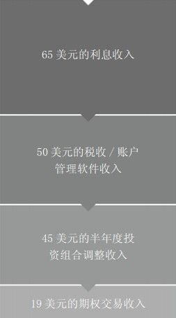

- 设置账户最低余额，对超过10笔的交易收费 股民想要能够得到每月10笔交易免费的优惠，其前提条件是他的股票账户余额不能少于25000美元。如果余额不足25000美元，那么Zecco.com网站就会收取4.5美元的费用。同样，如果在线开户股民每月的交易笔数超过了10笔，那么就要支付4.5美元的费用。Zecco.com网站的开户股民中有1/4的人每月交易笔数会超过10笔，因此网站每月的这项收入至少有17万美元。尽管该网站的大多数股民每个月只有一两笔交易，而且账户余额都在25000美元以上，但是他们每年也可能会有一两次对投资计划进行大调整的时候，每一次这种调整都相当于15次交易（每年45次交易套餐收费45美元，而且其中的10到20次交易是免费的）。
- 借客户没有投资的可用资金来赢利？这一点大家都很容易想通，一家在线券商也能因此受益。平均每个Zecco. com网站的开户股民在户头上会留有1500美元的未投资现金，为的是捕捉可能出现的投资良机。就像银行一样，Zecco.com网站可以得到2%的利息收入（全年就是30美元）。如果某个客户在保证金账户里有500美元，那么Zecco.com网站能够得到7%的收入（每年再增加35美元）。
- 辅助以收费服务和广告收入？对于那些想要减少资本利得税的客户，Zecco.com网站会向他们出售税收计划和投资管理软件。客户可以免费使用两个月，然后每半年付费25美元（每年付费50美元）。交易活跃的客户还会订阅市场信息，每月付费20美元（每年付费240美元）。和大多数商业网站一样，Zecco.com网站上也登载大幅广告。

雅虎的高管考虑得越多，就越觉得形势严峻。那些使用雅虎100MB的付费邮箱的用户给公司带来的并非广告而是直接收入，如果他们能从Gmail那里得到10倍大的免费邮箱，会不会另觅他途？邮箱用户们会不会滥用扩容后的邮箱，把很大的邮箱当成是个免费仓库？更糟糕的是，雅虎高管觉得自己很难和Google的邮箱媲美，如果要保持自己的领先地位，就要提供比Google更大的邮箱容量才行。

雅虎的高管头脑中浮现出了一栋装满了旋转圆盘（最昂贵的存储器）的房间，当然不论是这样的硬件购置费用还是电力成本，都是为了反击Google的那篇新闻稿。雅虎的高管越想越焦虑，也觉得心里很不平衡，但是他们还有什么别的选择呢？

布拉德·加林豪斯和中山戴夫两个人好好算了一笔账，会议室的白板上画满了各种图表。他们计算了存储器的成本，还好这项成本在不断降低；他们还计算了对存储器的预期需求量，这呈现出了一个经典的长尾曲线，少数用户会消耗大量的存储容量，而大多数人只需要消耗一点存储容量就够了。但是，这一点过多久会变化呢？如果人们觉得没有必要删邮件，那么当他们看完邮件之后会养成习惯把邮件删了吗？

雅虎的高管还讨论了该如何把不同的邮件放置在不同的存储器上，有的存储器运行速度比较快，有些比较慢，有些则更慢。也许雅虎可以把日期比较久远的邮件储存在便宜、反应速度比较慢的存储器上，只把那些比较新的邮件储存在价格更高、反应速度更快的存储器上，这样邮箱用户就能很快地查阅近期邮件。然而，要把邮件进行这样划分的话，就需要建立一种全新的软件架构，这或许需要更高的成本并冒更大的风险。

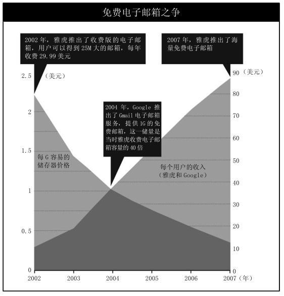

雅虎的高管最后还不得不考虑公司的收入问题。雅虎邮箱不仅能给公司增加广告收入，带来收费邮箱用户，还能给雅虎网站其他服务带来更多忠实的客户。当雅虎邮箱用户从邮件界面进入到雅虎网站主页，或是浏览金融和新闻等内容时，公司赚到了很多钱。雅虎承受不起邮箱用户减少的损失，因为这些用户对于雅虎网站其他的生意而言都是很重要的，而且随着广告数目的增多，每个用户的价值也在提升。

到2004年，事态也变得越来越明显，Google确实会发布自己的Gmail邮箱服务，雅虎也需要做好应对的准备。当年4月1日，Gmail邮箱面世了，而且情况正如雅虎所担心的那样，Gmail邮箱将为使用者提供1G的免费空间。作为应对之举，时任雅虎首席运营官的丹·罗森维格大笔一挥，批准公司购买了价值数千万美元的服务器和存储设备。5月15日，在一次行业分析师参加的会议上，雅虎宣布给邮箱用户提供的免费存储量马上将从10MB提高到100MB，而且以后容量还会扩大到更多，而付费得到100MB的用户将得到退款。到当年年底，雅虎的邮箱容量已经和Gmail的1G免费空间持平了。到2007年，雅虎更上一层楼，宣布用户可以免费得到容量上不封顶的海量邮箱（而在同期，Gmail邮箱的容量也逐渐增大，但现在的免费空间只有8G）。

在雅虎推出了邮箱新服务之后，事态的发展也让雅虎高管们感到惊奇。雅虎的付费用户并没有成群地离开雅虎，他们觉得还是有一些功能值得掏腰包的，例如付费的邮箱没有广告邮件的骚扰。那些没有新续约的收费邮箱用户也并没有马上就离开雅虎，因为他们是按年和雅虎签订的合同。人们的邮箱使用习惯并不会一夜之间就发生巨变，而且他们依然看完邮件后会删除，所以储藏量增长的势头并没有雅虎高管担心得那么恐怖。

中山戴夫的团队编制出了能够抓住滥用邮箱者和散发垃圾邮件者的程序。所谓容量上不封顶的海量邮箱也是雅虎能够控制的。你可以把自己想要的邮件加入到雅虎邮箱，但是如果你上载速度过快的话，雅虎就会发现，这就是滥用邮箱的一个表现。正如中山戴夫所说的那样：“你想把车开到多远就开多远，但是你不能想开多快就多快。”这句话的意思是说雅虎能够以很慢的速度来增加存储器容量，雅虎能等得越久，相应的存储器也会变得越便宜。

雅虎的策略最后收到了效果，它依旧保持着电子邮箱市场领头羊的地位，而Gmail只是用户数远远落后的季军。电子邮箱并没有成为雅虎看不见底的一个销金窟，而是继续给公司带来了赢利。它和Google的免费邮箱展开了对攻，而且变得比Google邮箱更加实惠，并首先实现了各大网站最终必定要承诺的海量邮箱服务。雅虎干脆把服务优惠到底，而这一招也收到了效果。

不过，Google的发展并没有画上句号。实际上，Google正在开始新的征程，它用免费来打入每一块新市场并和竞争对手展开厮杀。在这些新市场上，软件和信息经济推翻了原有的经营模式并创立了全新的模式。

如果一个门槛很高的会议能够在线观看，如何还能保持极高的票价？

要想得到一张只能凭邀请入场的美国科技、娱乐、设计大会（TED）门票，你需要掏6000美元。每年，公司的首席执行官们、好莱坞名流以及美国的前总统都会齐聚加州的某个度假胜地（过去25年一直在加州的蒙特利半岛开会，现在已经改到了加州长滩）。如果你能拿到这样一张门票，那么就可以听到达尔文主义科学家理查德·道金斯、《模拟人生》游戏设计者威尔·怀特、阿尔·戈尔（偶尔会是我）所做的18分钟主旨演讲。在多年的闭门会议传统之后，会议的主办方开始把演讲放到了网上免费供大家下载。时至今日，这项会议的演讲已经被下载或在线收听了超过5000万次。那么，会议的主办方为什么会放弃王冠上的宝石呢？

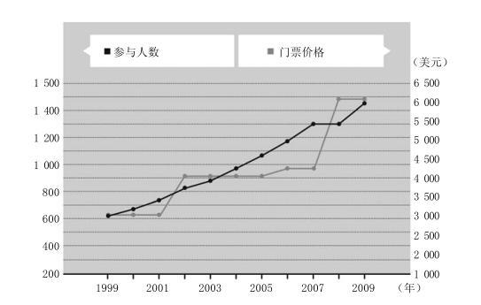

[1] Linux 的标志是一只小企鹅。—译者注

## 去货币化：Google和21世纪经济模式的诞生

导读

互联网是新的市场平台。

要追踪钱的去向，你就必须转换对市场的基本认识，从认为市场是买卖双方相匹配的系统转变为一种更为开阔的观点，即市场是多方共存的生态系统，其中只有某些方面直接进行现金交易。

20世纪以前的古代市场是买卖分立的单层结构，21世纪后的现代市场是统分结合的双层结构：“统”的一层是基础业务平台，是免费生态系统；“分”的一层是多元增值业务，直接进行现金交易。

Google的基础业务平台，就是它的搜索业务。Google不仅围绕“免费”创立了一种商业模式，而且发明了一种全新的计算方法，它将过去在我们自己电脑桌面上运行的各种功能越来越多地转移到“云”中，即在远程数据中心运行并通过我们的互联网浏览器（其中非常理想的一款浏览器就是Google推出的“Chrome”）在线接入。

为何Google要采取“免费”策略？因为这是覆盖最大规模市场并为大量商家采用的最佳方式。施密特将其称为Google的“最大化战略”，而且他认为这种战略将界定信息市场。道理非常简单：“不管你正在开发的是何种产品都接受它，并依据分销量尽可能多地进行生产。换句话说，既然分销的边际成本为零，你就可以使产品遍布全球。”

如今位于加利福尼亚山景城圆形剧场大道1600号的“免费城堡”已成为一处旅游胜地。这里就是以免费赠送而著称的史上最大公司的总部—Googleplex。城堡之外，颇具天赋的工程师在玩沙滩排球，骑山地自行车。城堡里面，他们把衬衫搭在椅背上，一起研究如何运用他们巨型数据中心所具有的非同寻常的边际成本优势开辟新业务领域，使这个“搜索巨人”的“触角”得到进一步延伸。

现在，Google提供将近100种产品，从照片编辑软件到文字处理器和电子表格，而且几乎所有软件都是免费的。实实在在的免费—而非耍花招。它按照任何现代数字公司都应当遵循的方式运营：赠送大部分产品而只从少数产品中赢利。

Google通过为一小部分核心产品做广告而赚取大部分利润，大多数搜索结果和广告被其他网站转载，而后者与Google分享收益。这也是它能在其经营的其他各种业务领域采取免费营销策略的原因。推出新业务时，公司通常会提出以下看似滑稽可笑的问题：“这会很酷吗？”“人们会喜欢它吗？”“它是否很好地运用了我们开发的技术？”而不会平淡无奇地问：“这能赚钱吗？”

听起来有点傻吧？通用汽车公司（GM）或通用电气公司（GE）可能会觉得这么做有些离谱，但对于纯粹开展数字业务的公司而言，采取这种方式真是太明智了。如今在你拥有一套商业模式前就着手创建一个规模巨大的观众群并不是什么蠢事，因为现在的情况已和20世纪90年代末网络时代刚刚开启时大不相同了，那时你需要同时具备大量风险投资资金和太阳微系统公司服务器（Sun servers）。如今，各网络创业公司与Google共用相同类型的大型服务器中心，这使在线提供服务的成本变得异常便宜。由于“虚拟主机”业务的存在，例如亚马逊公司的EC2业务，各公司能够在完全没有实体基础设施的情况下投入运营，有可能使用相对较低的成本向数百万用户提供服务。

因此，各公司就能够以小笔资金启动，并在无须承担巨大金融风险或严密筹划如何赚钱的情况下放眼长远。保罗·格雷厄姆—专注于小规模创业公司的风险投资公司Y Combinator 创始人，给未来的企业家提出了看似非常朴素的建议：“提供一些客户需要的产品或服务。”他的公司为那些启动资金只有5000美元的公司提供资金支持，鼓励它们使用开源工具、托管服务器并在家中办公。大多数创业型公司会采取免费营销策略检验其想法是否切合实际并与客户进行互动。如果它们这么做了，接下来要面对的问题是客户实际上有可能为哪种商品买单或者如何利用其他商品赢利。经过几年运营后，公司才会面对上述问题（而且有时公司从来不会面对这样的问题），但由于一开始推出服务的成本非常低，巨额资本遭遇风险的概率就微乎其微。

如今有大大小小无数与此类似的网络公司，但迄今为止Google是规模最大的一家，而且由于它在自己的一部分业务领域赢利如此丰厚，因此免费策略不只是向某种商业模式演进过程中的过渡性步骤，它成为了其“产品哲学”的核心。

为了弄明白Google如何成为免费战略的“旗帜”，应当看看它是如何演进的。我们可以将Google的历史概括为三个阶段：1.（1999～2001）随着互联网规模逐步扩大，Google创建了一种获得更佳搜索结果的方法（与之前所有的搜索引擎有所不同）。

2.（2001～2003）为广告商提供一种“自助服务”方法以创建与关键字或内容相匹配的广告，而后使它们相互间竞价以竞标最显著的广告位。

3.（2003年至今）开发了其他多种服务及产品以扩展Google的覆盖面，增进消费者与公司间的关系。在适当的条件下，将广告扩展到其他产品领域，但不以牺牲客户体验为代价。

这一经营战略已经收到奇效。如今，在成立10年后，Google成了市值200亿美元的“搜索巨人”，其赢利水平（2008年超过40亿美元）高于美国所有航空公司和汽车企业盈利的总和（是的，如今这些已不必多说）。它不仅围绕“免费”创立了一种商业模式，而且发明了一种全新的计算方法，它将过去在我们自己电脑桌面上运行的各种功能越来越多地转移到“云”中，即在远程数据中心运行并通过我们的互联网浏览器（其中非常理想的一款浏览器就是Google推出的“Chrome”）在线接入。

“云”在哪儿？让我们去位于俄勒冈州达尔斯的另一个地方看看，此处位于距波特兰80英里的哥伦比亚河沿岸。我们在这儿就能一睹“云”之端倪，至少从它的外面看。这是Google的一座数据中心—一座工厂大小的建筑物，里面堆满了成千上万块电脑主板和安装在可拆卸服务器中的硬盘，所有这些设备都与网络连接在一起，而这座建筑最终通过很粗的一束光纤电缆接入互联网。

这些数据中心是三重技术—处理、带宽和存储的融合。随着Google在世界范围内新建的此类“信息工厂”越来越多，它们的成本并未降低，但发挥的作用却越来越大。每一个新数据中心的计算机都比已建数据中心的计算机运算速度更快，而且其硬盘中存储的信息量更大。因此，这些数据中心需要连接到外部世界的更大规模通路。其总容量增加后，我们就知道为何Google建立的各个数据中心能在成本不变的情况下（与其在一年半之前建立的数据中心的成本相同）将运算量提高两倍。

每18个月Google为客户提供超大Gmail邮箱的成本就会降低约50%。起初提供这一服务所需成本就很低，之后成本又逐年下降。你使用“Google地图”辨别方向、浏览“Google新闻”摘要及欣赏YouTube娱乐短片同样如此。Google投入巨资持续建设此类数据中心，但由于各中心处理的数据量增长速度远超过基础设施投资增速，在每字节基础上，Google为客户提供服务的成本每天都在下降。

### 电话号码查询服务如何免费？

美国电话电报公司及其竞争对手每年从电话号码查询服务中卷走70亿美元，每次查询电话收费50美分到1.75美元不等。与此相对，Google推出了旗下的GOOG-411免费查询服务。“搜索巨人”又是如何做到免费提供服务的？

Google放弃收益转而获得热点市场的进入权

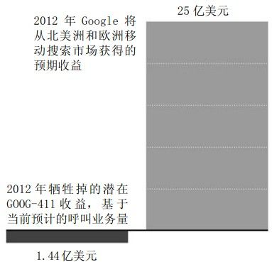

- 获取免费数据：每次GOOG-411来电用户请求帮助查询某号码时，他们其实都在为Google提供宝贵的信息。每一次呼叫均提供了口音、措辞、商业名称方面独特变化的语音数据，Google可用其改善语音识别算法。自2008年春天推出该项免费服务后，估算获得数据的市场价值达1400万美元。
- 投资下一项大买卖：语音数据的价值无法与Google对每次呼叫收取1美元费用而获得的潜在收益相提并论。那么为何要放弃巨额现金收益？Google研究主任彼得。诺威格已经指出，GOOG-411是适用于移动电话的语音驱动搜索引擎的“试验台”。如果它能将广告投放到手机上，Google在该市场中所占份额将达到数十亿美元。

如今，Google在超过36个数据中心拥有约50万台服务器，大部分位于电价较低的地区，如太平洋西北岸的水电站附近。（颇具讽刺意味的是，在Google电是较为昂贵的少数几种资源之一。确实，经分析家计算得出，随着电脑工作时间的增加，一块典型的Google电脑主板消耗的电能成本要高于这台电脑本身的价值。因此该公司的可再生能源项目有助于开发更便宜的低碳型能源。）

当今世界任何其他公司的基础设施都无法与Google的这一大规模基础设施相媲美，尽管微软、雅虎、IBM、惠普和亚马逊以及其他几家公司在此方面与之相近。这赋予了Google在“免费”竞赛中的巨大优势。虽然其他公司的数据运算处理成本并不高，由于具有规模经济优势，Google的数据成本较之更低，而且成本下降更快。凭借其超大容量，Google可以通过谈判获得最佳硬件、带宽甚至供电费率。（的确，CEO埃里克·施密特打趣说道，Google的计算机群之所以发展势头迅猛，就在于当数据中心所有者破产时它们仍能派上用场，正如开始拥有自己的数据中心前Google与之合作的各公司的情况。对于那些并未做出正确估算的公司而言，对免费的追求将是一种伤害。）

### 最大化战略

为何Google要采取“免费”策略？因为这是覆盖最大规模市场并为大量商家采用的最佳方式。施密特将其称为Google的“最大化战略”，而且他认为这种战略将界定信息市场。道理非常简单：“不管你正在开发的是何种产品都接受它，并依据分销量尽可能多地进行生产。换句话说既然分销的边际成本为零，你就可以使产品遍布全球。”

他列举了一个与电视节目有关的例子。设想你和我是热播剧《黑道家族》（The Sopranos）的制片人。你正在想我们如何推广这部电视剧。碰巧，我在HBO电视台有位朋友，而且他们已经同意每周在该频道播放这部连续剧并筹钱资助该剧的拍摄。按说情况已经很不错了，但这只是免费策略的一部分。

随后我们认为需要开办一个博客以在该剧开播前积聚一些人气。临近播出时，我们需要联系一家公关公司以获得媒体的关注。也许我们还需要借助某些网络造势手段，像Facebook 页面或某种“病毒视频”。而后，在节目播出过程中，我们将通过文本消息和Twitter 介绍最新剧情。这将促使人们登陆电视剧官方网站，他们可以通过网站进一步了解剧中角色，这将使他们对该剧产生更为浓厚的兴趣。

之后我们会将所有未公开上映的片花放到周日集锦节目中，并上传到YouTube网站。由于我们在拍摄《黑道家族》过程中使用了大量胶片，我们能集齐所有的片场花絮。因此，为了吸引更多关注，我们将对本应在剧中播出却被剪辑掉的内容进行筛选……最终我们找到了使观众认可《黑道家族》核心理念的方法并将这部电视剧传播到消费者可能会注意到的每一个市场领域。也许只有借助其核心策略，即HBO交易才能赚钱，但所有其他方面都有助于最终赢利的实现。

这就是最大化战略。

如施密特指出的，如果你已经创作出一部HBO热播剧，那么这一战略就非常有效。而且在某种意义上讲，这也是Google广告业务所具有的优势（为广告商提供的服务被称为AdWords，而为出版商提供的服务被称为AdSense系统）。但你尚未拥有自己的热门产品时又该如何？如果是这样，最大化战略仍能赢得广泛关注并且有可能树立良好的产品声誉，但你要面临弄清楚如何将其转化为现金收益的挑战。这还称不上生意场里最难应付的问题—大多数公司竭力提高产品的流行程度，而不是从中赢利—但如果你从未彻底理清这一小细节，“最大”也只是意味着为获取小回报而为带宽支付的大账单。

幸运的是，这并非Google的问题。能找到一种像网页应用一样发展迅速的赚钱之道堪称幸运（这种方法发展势头甚至更为迅猛，因为它持续蚕食其搜索和广告竞争对手的市场份额）。唯一能够限制Google增长势头之处在于互联网自身的扩展步伐。因此Google设计出众多产品，以扩展包括免费无线接入和免费存储在内的互联网应用。

这些其他类别的产品就是经济学家所说的“互补品”。互补品通常是一起提供给消费者的产品或服务，例如啤酒和花生米或汽车和汽车贷款。对于Google而言，互联网上出现的一切均可被视为其主营业务的互补品。博客中发表的每一则帖子都为Google的网络爬虫和指数提供更多信息，以助其给出更好的搜索结果。Google地图上的每一次点击都提供了更多有关消费者习惯的信息，而Gmail中的每一封邮件都是我们现实生活中各种社会关系网络的线索，Google可在它们的帮助下开发新产品或提高广告业绩。

互补品消费的有趣之处在于它们通常都会出现一前一后的增长势头。因此使用互联网的人越多，这对Google的核心业务而言就越有利。如果Google能借助免费策略鼓励人们将更多的时间花在互联网上，那么最终它的赢利也会更高。

今天，绝大多数Google雇员忙于设计可以免费赠送的新产品。有部门专门研究赠送Wi-Fi服务的方法，而另外一些部门则编写开源软件。它为科学家提供免费数据存储服务并扫描经典书籍将其放在网络上。它赠送相片管理软件及网上相片存储空间。它免费提供Google地图业务并能通过环绕地球运转的卫星获得最新影像，从而提高其电子地图分辨率。它还运营着411免费语音查号台。如果你想自制一部新手机，它也会提供给你足以完成这项工作的操作系统软件。所有这些都是免费的。

施密特举了个例子以解释为何此类看似利他主义的做法有其不可替代的意义：“对Google新闻的最初研究认为浏览Google新闻的网友更有可能在随后的搜索中点击搜索广告，因此每个人都会说，‘太棒了。’这是赔本赚吆喝的产品—仅仅为了获取网络流量。毫无疑问这确实是公司为广大网友提供的一项服务，但一种更为务实的看法则是这种产品不是Google新闻而是Google。这完全与网友对Google的忠诚度有关，而且如果我们能在一定程度上借助网友对Google的感情最终使他们购买我们能从中赢利的产品或服务，那么总体上看这一策略就是成功的。”

或者如《IT不再重要》 <sup>[1]</sup> （The Big Swich）作者尼古拉斯·卡尔所言：“Google希望信息是免费的，因为随着信息成本的下降，它赚到手的钞票越来越多。”

这就是互补品的力量。

因为Google的核心业务赢利如此丰厚，而且建立在如此大规模的计算基础设施上，它所从事的其他一切产品或服务的研发或推广成本都更低且效率更高。对于Google而言很容易开发新产品，因为它们都建立在已经完成的工作基础上，而且当产品下线时，凭借Google对全球注意力市场的统治，更容易使其获得成功。可以在产品最终研制完成前将其推向市场（推出“测试版”），而且如果经大规模试用证明值得对这些产品继续进行研发，则可以迅速做出判断。即使Google的“败笔”，如Orkut社会关系网服务或Google聊天（Google Chat）服务，仍拥有百万用户。对Google而言，失败的代价很小，因此它在尝试开发具有一定风险的产品时并无后顾之忧。

所有这一切听起来都很灵活，但它并不像看起来那么缜密。尽管Google确实拥有御用经济学家和商业战略家，但其拥有的大部分员工是工程师，他们拿着薪水思考手中掌握的技术能为客户提供何种产品或服务，以及客户希望得到何种产品或服务。只有到后来才轮到某些MBA（他们通常是这种“极客文化”中的二等公民）思考工程师们设计出的产品或服务如何能够恰到好处地成为广告销售的互补品。

有时，企业主管们会对此表示反对，理由是“分神成本”（distraction cost）给工程师其他项目造成的损失非常大，或者说新产品并不像工程师设想的那样完美，但主管们从未因这并不赚钱而表示反对。在“免费城堡”中，免费是默认的，无须宏大理论作支撑。当你身处这个有史以来规模最大的三重成本削减机器的核心区域时，结论不言自明。

### 一声巨大的吸气音

所有这一切听起来都是那么令人恐惧。尽管科技通常能降低成本这一点确实很棒，但当此类定价之一是你的薪水来源时，它无疑就具有破坏性。从威尔士的煤矿工人到底特律的汽车工人，各行业的生产经营模式无不向成本最小化方向演进，而这一最具生产效率的模式具有实实在在的人力成本。如美国国家广播环球公司（NBC Universal）首席执行官杰夫·扎克所言，电视行业对“为获得数字便士而交易模拟美元”深感恐惧。然而他和其他人都难以阻挡这一趋势：电视是具有稀缺性的业务领域（只有这么多电视频道），而互联网并非如此。你无法在一个供给充足的市场里开出稀缺价格，你也无须这么做，因为成本很低。

很容易看明白为何对于正逐渐失去其定价优势的行业而言这就是匮乏的表现。对那些受到影响的行业来说，“去货币化”无疑是令人痛苦的。但回过头来看你就能明白：与其说失去了价值，不如说以并非总是用金钱来衡量的方式对其进行了重新分配。

要弄明白正在出现的“去货币化”过程，只需看一看免费分类网站Craigslist的整个运营。在其成立后13年的时间里，其免费列表服务就一直备受诟病，人们认为正是它抢占了至少300亿美元的美国报业公司股票市场市值。与此同时，Craigslist自身每年的赢利仅够支付服务器费用和几十位员工的薪水。2007年，该网站从收费产品和服务中（包括11座城市的工作职位列表和纽约城的公寓名单）赢利约4000万美元。这笔收入约为3.26亿美元的12%，受其影响当年分类广告收益出现下降。

但“免费”并不像它听起来那么简单，或者说它具有破坏性。因为产品是免费的并非意指某个人在某个地方未赚到大笔钱，或者很多人中的每个个体都没有赚到多少钱。Craigslist 网站属于第二类，大部分价值并没有落入克瑞格·纽马克包中，而是相反在该网站的众多用户间分配。

与某些将分类广告置于平面报纸的用户相比，Craigslist 用户通过在线发布广告可节约成本且拥有更长的广告清单。对于浏览广告的网友而言，Craigslist 具备互联网通常所具有的优势—从简易搜索到自动化通知。由于这两大优势吸引了众多网友（请牢记最大化战略），发帖者更容易找到他们准备出售公寓的买家或拟招聘职位的应聘者。而且由于免费增加了参与者数量，与通过发布付费广告相比，这就有可能找到一处更适宜居住的公寓、一个更适合自己的职位（或者综合素质更高的应聘者）。

免费给所有市场都带来了更强的流动性，而更强的流动性意味着它所处的市场能够运转得更为顺畅。这是Craigslist 网站经营如此多分类广告业务的真正原因—免费吸引人，而与免费相伴的市场效率最终使客户关系得以维持。

“流动性”通常仅被视为一个金融术语，但实际上它适用于存在关联方的任一系统。在技术领域，它被称为“等级”（scale）。归结起来就是“越多就越与众不同”。如果在某学校100名六年级志愿者中，愿意帮助编写年报的仅占总人数的1%，就无法完成这一任务。但如果维基百科网站的访问者中仅有1%决定创建一个条目，你就能得到有史以来最为丰富的信息量。（实际上，维基百科网站的访问者中活跃的条目贡献者接近万分之一。）多了之所以就不一样是因为能够产生大的影响，而且会使情况变得更好。

关键在于，通过使每个人免费进入全球数百万人构成的大市场，互联网成为了流动性机器。因为它覆盖了这么多用户，它能够以巨大的参与率投入运转，而在传统非零边际成本领域，这一参与率将造成一场灾难。YouTube 网站上传自己制作视频的用户仅为千分之一。在具备百万分之一回复率的情况下，Spammers就能够赢利。（以我所在的杂志行业为例，对直邮订购服务低于2%的回复率就被视为营销失败。）

相对于在线运营的所有成本优势而言，流动性优势更为明显。市场上存在有待开发的大量供给（尚未流行开来的高质量产品和服务）及同样巨大的未得到满足的需求（人们拥有却无法实现的需求或者不知道自己已经拥有的各种需求）。像Craigslist 这样的业务能够将二者联系起来，它们能在保持如此巨大规模的基础上将成本降到如此低的水平进而取得成功。

然而Craigslist网站并却没有多少钞票可赚，它只是从报纸盈利中分得很小一杯羹。利润都跑哪儿去了？

要追踪钱的去向，你就必须转换对市场的基本认识，从认为市场是买卖双方相匹配的系统转变为一种更为开阔的观点，即市场是多方共存的生态系统，其中只有某些方面直接进行现金交易。考虑到如今Craigslist 网站的规模（每月5000万用户），很容易弄清楚在该网站进行的现金交易相比任何报纸分类广告版上进行的现金交易多出多少，这会产生匹配更为完善的供/需关系并为参与者带来更好的经济成果，即便存留在市场中的现金更少了。分类广告市场中蕴藏的价值恰恰从少数人手中转移到了多数人手中。

风险投资家对免费的此种运用方式，即收缩一个行业而潜在地开放其他行业，有着自己的界定—“创造免费业务领域”。 合广投资（Union Square Ventures）合伙人弗雷德·威尔逊解释道：“它描述了进入市场的某种业务，像分类广告或新闻，而且凭借其惊人的运营效率，市场领导者只需依靠一小部分收益就能实现盈利。”

另一位风险投资家乔希·科派尔曼用这样一个例子说明了其中的道理：我的第一家公司Infonautics 是一家将目标客户定位在学生中的在线咨询和调查公司。我在此任职期间获得了有关“不对称竞争”的切身体验。1991年，当我们初创之时，百科全书市场已经是一个市值约合12亿美元的庞大产业。执市场牛耳者为《大英百科全书》，其销售额约为6.5亿美元，被视为百科全书市场的“金本位”。《世界大百科全书》牢牢占据次席。每年《大英百科全书》和《世界大百科全书》均能卖出数十万本，每本定价超过1000美元。

然而，在1993年，该行业发展态势出现根本性转变。当年微软推出了定价99美元的大百科全书“Encarta”。最初，“Encarta”只不过被视为芬克-瓦格诺（Funk & Wagnalls）百科全书的CD版，但微软技术和制作成本方面的变化使他们能够提升整个竞争环境。到1996年，《大英百科全书》的销售额已经下降到了3.25亿美元，约为1991年销售额的一半，出版公司也解雇了其出色的上门销售人员。而到1996年，百科全书市场已经缩水到少于6亿美元，当年，《大英百科全书》在美国的销售额约为1亿美元。

现在“维基百科”这一无须支付任何费用的在线百科全书，使百科全书市场再次缩水，纸版和CD-ROM版百科全书市场份额均大幅下降。它本身并不赢利，但如今由于一个无可比拟的信息资源可被无偿提供给所有人使用，我们自身借助更丰富知识赚钱的能力得到了改进。

《大英百科全书》创造的价值曾一度被认为是下述二者在某种程度上的结合，即这本百科全书的直接收入与有幸拥有该书的读者不断提高的生产效率。免费浏览且易于接入、海量存储，以及对更多人越来越有用，具有上述优点的维基百科在提高更多用户工作效率方面的表现正逐渐超越《大英百科全书》。但它没有一分钱的直接收益，同时又“抢走”了“大英百科”的许多收益。换句话说，它正使我们能够衡量的价值（直接收益）不断缩水，但却在大幅度增加我们无法衡量的价值（我们的共有知识）。

这就是“免费”的成就：它将上亿美元的产业转变为百万美元的产业，但通常情况下，财富似乎并未蒸发，相反，它只是以难以衡量的方式被重新分配了。

就分类广告而言，报纸老板、雇员及股东损失巨大而我们这些人获得了一些收益，而我们的人数远多于他们的人数。完全有可能出现的情况是，增加的损失的300亿美元报纸市值最终将在增长的GPD中以数倍于之前的市值出现，尽管我们永远无法清楚地解释其中的相关性。

采用这一策略的公司并不一定会计算赢家和输家的总数。相反，他们仅仅在做最简单的事情：免费赠送人们想要得到的产品或服务，而且只有当他们不得不运用某种商业模式时才那么做。但从表面上看，这似乎是一种“革命行动”。如莎拉·莱西在《商业周刊》上发文指出的：“就像侠盗罗宾汉，我们把财富从富人精英手中分给贫者，这里的‘贫者’包括那些想要节省下更多开支的消费者以及能很容易制造竞争性替代品的暴发户。”

这一现象随处可见，手机便是一例。由于拨打美国国内长途电话免费政策的推出，手机已经将长途业务去货币化。你看到有谁（除了长途提供商）抱怨吗？Expedia公司实现旅行代理业务的去货币化，而E*TRADE 更是将股票经纪人业务去货币化（并为更多免费交易公司，包括Zecco的出现铺平了道路）。在每种情况下赢家数量都远超输家。不可否认，免费具有破坏性，但它却常常能导致更高效市场的出现，其中的奥妙在于确保你将赌注压在将要获胜的一方。

### 免费的代价

但如果条件并不是很公平怎么办？如果财富并未从少数人手中彻底转移到多数人手中，使更多人富裕起来又如何？如果财富最终真的消失了，或者出现更糟糕的情况，即赢家比输家更少又该怎么办？

这就是Google的施密特所担忧的。互联网是经济学家所说“网络效应”最为突出的市场。在此类市场中，参与者相互间很容易进行交流和沟通，每个人都倾向于效仿其他人的做法，从而导致“羊群行为”（herd behavior）的出现。由于市场份额的微小差别可以被放大，在任何领域中排名第一的公司与排名第二及之后的公司间存在的差距通常会非常大。

在传统市场中，如果有三个竞争对手，排名第一的公司将获得60%的市场份额，排名第二的公司获得30%，排名第三的只能获得5%。而在网络效应较为突出的市场中，这一比例更接近95%、5%和0。网络效应往往会造成力量的聚集，导致“富者愈富”的结果。

尽管在20世纪90年代，这一观点被用于证明对微软进行反垄断诉讼的正当性，但在当前条件下施密特所关心的并非持续的垄断。如今互联网市场的准入门槛较低，新竞争者很容易崭露头角。（当然，这也是Google用来为自己辩护的说辞，它就被竞争对手指控为垄断者。）况且互联网不是限定性选择：那些很低的准入门槛确保了市场上存在众多竞争对手，而且所有规模较小的公司以及其他“长尾理论”的信徒也能够共享一个大市场。相反，需要的是对赢利的关切：每家公司都可以运用免费经营模式，但大多数都表现平平，只有最具实力的公司才能借助这一模式真正实现赢利。

为何Google应当关心其他公司是否能够将免费变成经济优势？因为它需要获得其他公司积累的经验，从而对其进行排序、组织和再包装，以创造属于自己的经营模式。如果数字免费模式使各行业不再赢利，特别是在新商业模式能够使其重新复苏前，那么每个人都将成为输家。

考虑一下报纸的困境就清楚了。免费网站Craigslist的成功已经造成大城市日报的广告业务日渐缩水，使大批专职记者无事可做，而低成本和由读者提供的“超本地化”替代方案并未适时而起填补空缺。也许有一天它们能发挥作用，但至少目前还没有表现出来。这意味着Google可用于制作索引的本地新闻数量更少了。也许会有更多的本地信息，但无法再将下述事实，即这些信息来源于一家专业新闻机构，作为信息质量的衡量指标。相反，必须指出哪些信息是可靠的，而哪些又是虚假的，这可以说是个更难处理的问题。

因此，Google会非常乐见报纸仍维持其运营，即便它自己的广告模式在抢占报纸广告市场份额方面取得的成功使报纸运营更加困难。这就是令施密特感到忧虑的两难困境。我们也许正处于这样一个时刻：去货币化的长期积极效应显现之前出现了短期消极后果。免费只能使我们中的一小部分变得“富可敌国”，而不是让大家都更得富有吗？

在这个“免费堡垒”中坐拥亿万家财的老板看来，这似乎是个颇具讽刺意味的说法，但对于Google而言存在大量赢家这一点很重要，因为这些赢家将为Google创造的下一波信息浪潮买单。

“从传统意义上讲，价格对市场进行了区隔，高端、中端和低端产品各有一定市场空间。”施密特解释道，“免费的问题在于它消除了市场中存在的所有价格差别结构。它倾向于造成一种‘赢家通吃’的局面，而非对各种产品区别定价。”他的担忧，简言之就是，免费使他收益颇多，而并没有给其他人带来同样的好处。

在《福布斯》每年公布的美国最富有400人排行榜中，我数了一下，只有11位的财富建立在免费商业模式基础上。其中包括施密特在内的4位来自Google，两位来自雅虎，另有两位则来自Broadcast.com网站（该网站之前曾是一家网络视频公司，后来在网络泡沫巅峰时期被雅虎收购，其创始人马克·库班和托德·瓦格纳随后的投资生意顺风顺水），之后便是Facebook 网站的马克·扎克伯格，如果你愿意也可以将奥普拉·温弗瑞算在内（她27亿美元的身价建立在免费电视节目基础上）。

我并没有将所有媒体大亨—从鲁伯特·默多克到巴里·迪勒包含在内，因为他们每个人都掌管着各种不同的大型联合企业，不仅提供免费业务，也有付费业务。而且《福布斯》并未将很多已属富翁但非百万富豪的企业家收入名单之中，包括免费模式运营的典型代表，如MySpace创始人，以及一些在开源软件方面成就卓著者，如MySQL 创始人（2008年MySQL 被太阳微系统公司以10亿美元价格收购）。施密特认为，如果我们以能否创造分散在更多人而非少数人中间的大笔财富衡量是否成功，那么免费仍无法与付费相比。

但有迹象表明事情正在发生变化。要弄明白如何变化的，你就必须看一看最初的免费业务—媒体不断演变的性质。

[1] 《IT 不再重要》已由中信出版社出版。—编者注

## 新媒体模式：免费媒体并非新鲜事物，但其仍具有新鲜之处，即免费模式向其他在线领域的拓展

### 导读 互联网是新的媒体平台。

免费媒体并非新鲜事物，但其仍具有新鲜之处，即免费模式向其他在线领域的拓展。

广播和电视节目均为免费播放而且有广告商赞助，这就是所谓免费的媒体模式的开端：第三方（广告商）为播放内容提供赞助以便第二方（听众或观众）可以免费收听收看。当广告超越媒体进而支持由普通人而不仅仅是媒体公司创造的软件、服务和内容时，它会发生何种变化？

Google取得成功的AdSense项目对大众的吸引力在于它将广告与内容相匹配。为何这种相关性匹配在纸质媒体中饱受诟病却在线上媒体中受到热捧呢？这一问题的核心是随着线上广告的兴起，广告发布的核心要素出现了变化。

大量网站广告是人工发布的，而且很容易通过贿赂改变一个广告排序法则。Google模式则恰恰相反：运用软件仅将广告展示给最希望看到它的人，使10%对其不感兴趣的人感到厌烦而覆盖90%可能对此感兴趣的人。

各大公司只为结果付费。如果你确信自己花在市场营销上的10分钱总能赚回1元钱，那么广告市场的发展空间就是无限的。将其与古老的麦迪逊大街格言“我用来做广告的钱有一半浪费掉了，但我并不知道究竟是哪一半”相比较，得出的结论是根本不具可比性。

这就是广告赞助的免费模式已经远超乎在线媒体之外的原因。

1925年，商业广播行业发端之年，无线电风靡美国，聚百万家庭于小小的“电子壁炉”周围，并创造出“距离迷”（distance fiends），他们是惊叹于自己能借助广播收听到远在千里之外的城市信息的听众。广播将信息同时送到百万听众耳中的神奇力量，使广播电台必须创作出能够成为大众传媒的内容—娱乐、新闻和具有最广泛吸引力的信息。这是20世纪流行文化的开端，只是存在这样一个问题：没有人知道如何为收听到的内容付费。

直到那时，广播节目以极低成本维持运营（某些地方电台甚至让刚入行的新人直接做节目）或者由收音机制造商自掏腰包支付运营费用。戴维·沙诺夫—美国无线电公司副总裁当时做出了这样的解释：“如今广播在媒体界占据主导地位，因此那些购买RCA广播设备的客户都有能力维持接收仪器的正常运转。”但随着广播的发展，形势已经变得很清楚—对新内容的无止境需求无法由少数几家制造商满足。

《无线电广播》（Radio Broadcast）杂志宣布征集“谁为广播付费及如何付费”这一问题的最佳答案。当苏珊·思慕然（Susan Smulyan）在《无线电销售》一书中对该问题进行详细叙述时，共有800人参加了这项活动，他们提出的想法从自愿听众捐助（如“hi， NPR!”节目）到政府许可不一而足，有些人甚至别出心裁地提出为节目单付费。最终评出的最佳答案是将对真空管所征的税作为“广播消费指数”（index of broadcast consumption）。（换句话说，实际上，这是在英国已被采纳的一种模式，即听众和观众为其收听收看的广播电视节目支付年度税，作为回报可收看无广告版的BBC节目。）

有些建议认为广告也许是最佳答案，但这个答案并不受欢迎。一个新媒体充斥着赞助商赞助的信息似乎是可耻的。一篇文章颇为不安地指出“通过造就无动于衷的公众，损害听众的利益并减少接收设备的销量，夸夸其谈的广告……掐住了广播的‘命脉’……”

但NBC（一家新广播公司）决定进行测试以观察是否广播广告发挥了作用。1926年，它任命弗兰克·阿诺德（著名的广播广告拥护者）为测试运行主管。阿诺德将广播描述为“广告的第四个维度”，超出了传统的三维度—报纸、杂志和广告牌。其他人则在谈论广播如何神奇地使广告商成为“听众家中的一位客人”。

然而，广播存在的一个问题是由于其对距离的“蔑视”，距离这一外部因素正开始进行回击。东海岸的很多电台都在使用越来越强大的无线电发射装置，从而将广播传送到千里之外的城市，但随着地区和当地广播电台的兴起，更具地方特色的广播内容“淹没”了国家台的声音。（在某种程度上为了恢复无线电广播行业的秩序，联邦通信委员会应运而生。）因此，广播似乎归属于当地广告业，而后者不会去尽力地满足观众对内容的所有需求。

美国电话电报公司扭转了这一状况。威廉姆·派克·百宁这位后来的美国电话电报公司副总裁回忆道，在20世纪20年代初“没有人知道广播的出路在何方。在我看来，由于我们是一家电话制造企业，我们肯定将以某种方式被囊括在广播业中”。这就涉及到如何证明是经由美国电话电报公司的线路以无干扰方式在远程传输广播节目，从而使节目能由全国各地的广播站重新播送。美国国家广播网络由此应运而生，而且第一个广播广告的美国国内市场随之出现。（在此之前仅限于在地区性广播站覆盖范围内，各公司在本地发布广告这样的小打小闹。）

几十年后，电视也经历了与之相同的发展历程。广播和电视节目均为免费播放而且有广告商赞助，这就是所谓免费的媒体模式的开端：第三方（广告商）为播放内容提供赞助，以便第二方（听众或观众）可以免费收听/收看。

如今，这一三方模式正处于价值3000亿美元的广告业的核心。它不仅支持免费媒体（如传统无线电广播），也赞助大部分付费媒体（从报纸和杂志到有线电视），使这些媒体比在没有第三方赞助时运营成本更低。不过随着网络的兴起，上述媒体不再在传媒手段中具有特权地位，网络支持所有传媒方式。

### 超越媒体的广告

当广告超越媒体进而支持由普通人而不仅仅是媒体公司创造的软件、服务和内容时，它会发生何种变化？答案是：变化有很多。对于创建者而言，通常的信任规则被颠覆了。我将根据自己的经验为你展示一个例子。

前不久，一位来自Google公司的朋友访问了我们在《连线》的办公室。我向他展示了我们的“杂志间”，我们将正在编辑的一期杂志的所有页面一排排贴在房间的墙壁上。当这些页面编辑完成后，我们就能在墙上任意移动它们以找到这期杂志的最佳排版并避免文章或插图间出现冲突。

我们在这面墙上做的另一件事便是注意观察“广告/编辑冲突”，这是指表面上看起来与内容有关的广告。这源于大多数传统媒体在其编辑和广告团队之间树立的“中国墙” <sup>[1]</sup> ，之所以在这两个团队间横亘上这么一堵“墙”，是为了确保广告商无法对媒体编辑施加影响，但这并不够。我们还需要使读者对我们产生信任感，因此我们要竭力避免这种影响露头，具体做法就是确保不将一则汽车广告与汽车新闻或报道放在一起，或者不在刊载索尼产品评论的任何版面发布索尼广告。理想状态是，我们甚至不会在同一期杂志上刊登指向相同的新闻稿和广告。

当我就此向我那位来自Google的朋友解释时，他用越发疑虑的眼光盯着我。他不会像我们那么做，因为Google的做法与我们恰恰相反。

Google取得成功的AdSense项目对大众的吸引力在于它将广告与内容相匹配。商家向Google支付了大笔费用，让Google做我们绝对禁止的事情：将索尼广告放在有关索尼的新闻评论旁。而且读者喜欢这种做法—这被称为相关性。

为何这种相关性匹配在纸质媒体中饱受诟病却在线上媒体中受到热捧呢？这一问题的核心是随着线上广告的兴起，广告发布的核心要素出现了变化。

我对此的不很充分的解释是人们将不同的体验带入在线世界。不知何故，人们凭直觉能够理解我那位来自Google的朋友和我站在那间贴满杂志内页的房间里想到的一切。人们将杂志编辑成册交付出版，而人又往往禁不住金钱的诱惑而贪污腐化。但网上广告则是由软件进行编辑排版，而且在一定程度上使广告业务变得更为纯粹。

当然，这只是一种设想。大量网站广告是人工发布的，而且很容易通过金钱改变一个广告排序法则。但Google将广告置于其他人创建的内容之上时，二者之间就会保持一定距离以致人们似乎不必担心不正当的影响。

也完全有这样一种可能，即身处传统媒介中的我们将其完全搞错。也许我们正以对宗教和政治纯洁的追求而自诩，而且读者并不关心或者说甚至未曾注意是否在有关索尼的评论新闻旁附着一则索尼广告。读者也许喜欢这种方式，而真正的阻力其实来自我们的作者—担心有人会认为他们的观点已被收买。我对此一无所知，但我确实知道我所在行业的同业公会对此类事情有着严格的规定，而且如果我恣意破坏规定，我的杂志将失去评奖资格而且还会遭受其他类似惩罚。

但显而易见的是在线广告的属性有所不同。从本质上讲，传统的广播模式是这样的：令90%对你产品并无兴趣的听众感到厌烦，而使其覆盖10%可能对此感兴趣的听众（就像足球比赛中的假牙广告）。

Google模式则恰恰相反：运用软件仅将广告展示给最希望看到它的人，使10%对其不感兴趣的观众感到厌烦，而覆盖90%可能对此感兴趣的观众。

当然，在线广告并非总是以这种方式发挥作用，而且很有可能你已经观看过Google发布的大量令人生厌的广告。但由于精确定位广告供应数量的不断增加满足了消费者不断增加的精确定位内容需求，二者相互匹配得更好。例如，在我的空中机器人网站上，我们运行了能为与“三轴加速传感器”类似的特殊产品投放超精确广告的Google AdSense软件，随后我在我们的读者中展开了调查，询问他们是否希望我将其中的广告移除。

大多数读者要求我保留这些广告，因为它们的相关度非常高，正是这些读者需要的内容；一个规模更小的群体甚至根本没有注意到广告的存在；而想要去除这些广告的群体规模最小。（我保留了这些广告。）

### 新兴媒体如何改变传统媒体

广告支持的免费模式的有趣之处在于，在传统媒体企业中这一模式实际上正处于衰退中。随着电视节目从免费的过渡到收费有线电视，节目内容越来越多地由多种收入来源支撑，包括与广告并无多大关系的内容联合和有线许可费。即便是以卫星广播形式出现的无线电广播也正向直接订购和发布广告的方向演变。它现在看起来似乎更像印刷媒体业务，后者将订阅和报摊销售收入与广告收益相混合。

但互联网的兴起彻底改变了这一趋势。经过几年要求人们为内容付费的在线测试后，几乎每个人都清楚地认识到与数字经济作斗争是行不通的，而且免费策略已经获胜。不仅如此，在线设定的价格预期也开始向线下渗透。

报界意识到“Google一代”不会继承他们父母的习惯—每天买一份报纸，因此它们推出了面向年轻人的免费报纸并在街角和地铁站免费发放。其他报纸维持原价但随报免费发放赠品（包括音乐CD、银器等）。随着报业传统部门的衰落，免费报纸成了报界的唯一“希望之灯”，此类报纸年均增长20%（主要位于亚洲和欧洲）且占2008年全球报纸发行总量的7%。

与此同时，广播电视观众数量似乎已经达到峰值，至少热衷于电视节目的18～24岁的观众人数确实如此，他们越来越多地观看剪辑或在线（在YouTube或Hulu网站上）观看全部免费表演。宽带如今成了新的免费广播渠道，而且吸引观众的付费有线电视如今似乎也开始走下坡路。

### 付费内容的终结

这种转变是某种更为严重的内容贬值，这不仅是不同时代的人口味不同所致，而且也受到技术趋势的影响。洛杉矶一位娱乐业律师乔纳森·汉德尔给出了娱乐节目向免费转变的6个理由，我将对其做如下解释：1.供需关系。由大大小小的媒体公司创作的节目数量不断增加，但需求并没有出现质变：我们仍然只有两只眼睛、两个耳朵，一天也只有24小时。当然，所有节目内容的创作并非完全相同，而且Facebook 网站无法与《纽约时报》相提并论—除非Facebook 页面上有你的朋友，在那种情况下也许对于你而言它比时报更有趣。区别在于Facebook的页面比时报的版面多得多，而且编程人员在编写这些网页时并未期待用户付费登陆。

2.实体形式的缺失。我们对此无能为力：我们珍视现实世界超过虚拟世界。由于节目从装在CD盒里的光盘转入到通过线路和网络传输的电子文档中，它变得无可遁形，甚至有些抽象。此外，由于失去了实体形式，某些不具备上网条件的人无法看到它，而且内容以电子形式呈现使得想收看节目的观众必须付钱—数字文件本不应该如此。

3.接入的便捷。通常情况下，下载节目比四处寻找并从商店里购买轻松得多。由于此类“搜索成本”的下降，我们为所提供节目付费的意愿也随之降低。

4.广告赞助内容的转变。互联网上形成的阅读习惯迁移到生活的其他领域。如果在线内容是免费的，难道其他媒体提供的内容不应当同样是免费的吗？

5.计算机行业希望内容是免费。苹果公司并不是靠销售音乐文件而赢利过亿的，它出售的是iPod播放器。免费内容使得播放这些音乐的设备变得更有价值，一如20世纪20年代无线电广播业的情形。

6.免费的一代。伴随着互联网成长起来的这一代年轻人已经将数字经济学理念嵌入到他们自身的DNA中。无论他们是否曾经听说过“接近零边际成本”，他们凭直觉就能理解这一概念。这就是他们对版权不是无动于衷就是充满敌意的原因。他们并不明白其中的道理。

这就是为何广告赞助的各种免费模式在互联网上取得成功的原因，而且它们仍将继续获得成功。

在这一点上，对此持怀疑态度的读者应当保持高度警惕。可以肯定的是存在对线上广告赞助的限制。广告无法支持一切手段。确实，某些广告在互联网上的价值甚至低于其在平面媒体上的价值。

### 如何使银器成为免费品？

Controlinveste是葡萄牙领先的媒体公司，旗下拥有多家报社、电视台、广播、杂志及互联网企业。它的两份主打报纸是《Global Notícias》（该国发行量最大的报纸，该报免费发行），以及《Jornal de Notícias》（该报收费）。与许多欧洲报纸相同，这两份报纸也主要通过报摊出售，在这一销售渠道的竞争中，你必须每天都赢得读者的青睐。因此免费赠报就成了经常使用的市场营销手段（就像英国的《每日邮报》随报赠送歌星普林斯的CD）。然而，Controlinveste公司在这方面的动作幅度远大于多数竞争对手。

2008年，Controlinveste随报赠送一套60件的银器礼盒以纪念《Jornal de Notícias》报发行120周年。从周一到周五，这套银器中的一件会与报纸捆扎在一起送出。每到周六，你会随报纸得到一套餐具。如果有一天没买报纸，你就会错失这套纪念品中的一件。

赠送的银器均单独包装后分发到报纸经销商处，他们负责将这些银器随报纸免费送出。这在读者中引起了强烈反响，在短短三个月时间内报纸发行量增加了36%。

在付费报纸发行量逐年下滑的这样一个成熟产业中，Controlinveste旗下报纸取得的成绩确属优异。但它又是如何做到赢利的呢？两种方法：其一，银器比我们想象得更便宜，特别是成批购买时；其二，从超额完成的报纸销售量中获得的边际利润也远高于我们的估算。报摊上《Jornal de Notícias》的售价是每份0.88欧元（周一到周六的平均价），折合1.32美元（从周一到周六平均计算）。考虑到税金、印刷和分销成本及报摊利润，报纸的赢利空间相对较大而且全部固定成本（人员、办公场所及其他设备）均被囊括在发行收入和广告费中。如果你卖出的报纸越多，固定成本分摊的基数就越大，读者数量就会增加，利润率自然随之提高。如何卖出更多报纸？那就免费赠送一些东西吧！

Controlinveste公司从中国大量买进银器，每件银器的成本仅为数美分。当公司卖出一份报纸就附赠一把汤匙时，这一买赠促销活动就消耗了大部分利润，但最终，当其固定成本被涵盖在其中时，赢利的前景就一片光明了，因为这些额外卖出的报纸的边际成本非常低。而且如果上述赠送活动能够持续增加发行量，它们就能保证为广告商带来更多客户，如此一来报社就可以向广告商收取更高的广告费。

免费礼物不仅仅是银器 仅2008年一年，Controlinveste公司还开展了下述买赠活动：

- 带工具的免费工具箱。工具箱随周日报纸赠送（最畅销的一期，而且定价比工作日出版的报纸更高）。之后从周一到周五每天随报纸赠送一件新工具（总共177件）。成果：三个月中发行量增加20%。
- 每周六赠送免费DVD光盘 为了获得赠品，你须持有周五报纸上的优惠券，之后当你购买周六的报纸时就能获赠当前热门电影的光盘。成果：两个月时间里发行量增加了47%。
- 免费餐盘套装 和DVD赠送活动一样，在周六出版的报纸上得到优惠券而后买周日的报纸时获赠餐盘。同样，你必须购买一周中最贵的两期报纸，而且一整套餐盘包括19件。成果：4个多月时间里发行量增加了70%。
- 免费语言课 分几部分赠送学习各种外语的多媒体课程，这些语言包括英语、西班牙语、汉语、法语、俄语、意大利语、德语、阿拉伯语、希腊语、日语和希伯来语。每天你将随报纸获赠一张CD-ROM或一本教材，共48张光盘、22本书以及两个盒子。成果：4个多月时间里发行量增加了63%。

原因仍与匮乏和充裕有关。正如新闻业务和分析公司Publishing2创始人斯考特·卡普对此所做的评论：“传统媒体（无论报纸、杂志还是电视）上发布的广告全都是在销售稀缺资源—空间。问题在于互联网上最不缺少的恰恰就是空间。因此当传统媒体公司试图以它们在线下出售空间的方式出售线上空间时，他们发现自己只拥有一小部分定价权。”

一本印装精美的杂志可以向广告商收取每千位印刷版读者100美元的广告费，但拿到每千位在线读者20美元的广告费就算幸运了。在线竞争则更为激烈—广告商有更多选择而且价格降到了市场能够承受的水平，但这是因为“展示型广告”—意在推广某一品牌的标语和图像，并不必然促成即时销售业绩。

还有另一种形式的广告，Google的文字广告就是此类广告中的典型代表，此类广告被投放在搜索结果旁和第三方网页上。只有当读者点击该广告时，广告商才需支付费用。Google并不出售网上广告位，它出售的是以检索提问形式呈现出来的用户关注度—这也是用户们宣称感兴趣之处，而且这也是稀缺资源。毕竟不论哪天在搜索栏输入“伯克利干洗店”的人数都是有限的。

结果就是尽管在线传统广告数量有限，但Google重新界定广告的方式—将产品与强烈的需求相连接—仍在迅速扩张。据Google公司CEO埃里克·施密特估算，如今在线广告的潜在市场价值高达8000亿美元，或者说约为全部广告市场（在线和线下）总值的三倍。很容易发现原因所在：各大公司只为结果付费。如果你确信自己花在市场营销上的10分钱总能赚回1元钱，那么广告市场的发展空间就是无限的。将其与古老的麦迪逊大街格言“我用来做广告的钱有一半浪费掉了，但我并不知道究竟是哪一半”， 相比较得出的结论是它们根本不具可比性。

### 媒体模式的胜利

这就是广告赞助的免费模式已经远超在线媒体之外的原因，但这仅仅是在金钱能够发挥作用的领域。纽约风险投机资本家弗雷德·威尔森认为：“大部分网页应用程序将以某种媒体模式被货币化。我所说的并不是标语广告，而是各大公司及想要得到此类关注的人为你所提供服务的广告浏览者对广告的关注而付费的各种方式。”

随着媒体商业模式向其他各个行业领域的拓展，你可以观察一下网络公司。根据传统定义，Google并不是一家传媒公司，但它从媒体商业模式中获利颇丰。Facebook、Myspace以及Digg 网站均是如此，它们在本质上都属于软件公司。其中一些公司组织、编辑其他人发布的内容，而另外一些公司则为人们提供创建自己内容的平台。但它们本身并不以传统媒体公司采取的方式创建或传播内容。

但当提到“媒体商业模式”时，人们通常只会想到广告。可以肯定广告确实是这种商业模式的很大一部分，但正如我们这些身处媒体圈中的人所知，它远不止于此。

首先，广告业向互联网领域的扩展已经创造出很多超越广告传统“印象”模式的新广告形式，前者以每千位观众或听众为单位收费。（这被称为“每千人成本”或简称CPM，此处混用罗马数字M表示“千”。）在线广告计费模式包括“每点击成本”（CPC），这是Google使用的计费方法；以及“每交易成本”（CPT），这是指广告商只在浏览广告者成为付费客户时才支付广告费，例如亚马逊网站的Amazon's Associates程序。

其次，广告业存在“引导性促成销售模式”，在该模式中广告商因获得被免费内容吸引的消费者的姓名和电子邮件地址或与这些消费者相关的信息而向网站付费。广告商可以固定金额赞助整个网站或其中一个部门，而不按流量支付广告付费。它们也可以付钱使网站搜索结果中含有自己公司的广告，Google和其他一些网站均提供此类搜索结果。或者它们可以转而借助高质量的老式安插广告并付钱将自己的品牌或产品广告安插在视频或游戏中。

所有这些文本、视频、动画片、音频和“虚拟世界”（视频游戏）版广告的出现，以及你所能看到的广告业向互联网领域的发展—整个广告世界发生了何等巨大的变化。20年前，广告可以分成以下5种类别：印刷（展示和分类列表）广告、电视广告、广播广告、户外（广告牌和海报）广告以及小广告（传单等）。如今至少有50种不同的广告模式活跃在互联网上，而且每种模式都在随时发生着变化。看到一个行业在面对新媒体时进行彻底改革确实令人感到头疼，但又不免让人兴奋。

### ORC经济

我们认为所谓“媒体”就是广播、电视、杂志、报纸和新闻类网站，但实际媒体是各种内容的聚合，而且衡量其对我们社会影响的最佳标准就是人们花在媒体上的时间。以此种方式进行衡量，上述各种类型的媒体很少能与一种我们几乎从来没有将其算做媒体的形式相竞争，即便它直接与媒体竞争关注度。此种形式为视频游戏，从Xbox360射击类游戏到PC在线多玩家游戏等。

游戏产业不仅已经在产品销量方面上升为好莱坞大片的对手，而且在用户时间方面与电视展开了直接竞争，但它正以一种更为迅速的步伐实现自身转变。在加速向免费经营模式转变方面，没有哪一行比视频游戏来得更快。

从前人们在商店里购买视频游戏，这些游戏都装在CD盒里且一般标价40～50美元。你会把它们买回家，插入光盘并玩上一个礼拜，而之后就很少再碰这些游戏了。事实上一款游戏的全部销量会在其发布之后的6周内完成，就像好莱坞大片，但视频游戏没有能够继续从中赢利的后续DVD和聚合市场—而这是不可错失良机的热门生意。

实际上，这仍然是人们购买视频游戏的主要方式（听起来有些疯狂），而且游戏是仍然主要以此种方式出售的最后一类数字产品，但这种营销模式不久就会“寿终正寝”。正如音乐和电脑软件日渐成为在线市场的主要组成部分，视频游戏同样如此。一旦你从购买游戏软件（盒带和光盘）转变为在线下载游戏，免费就成为必然结果。10年之后，这一价值100亿美元的产业将从主体为传统包装零售产品的商业模式转变为建立在零准入成本上的在线商业模式。

这一转变的最初标志于2003年左右在亚洲出现。由于市场上存在的软件盗版行为使按照通常的方式销售视频游戏变得很困难，同时，游戏开发商变成了增速最快的在线市场。在中国，网吧遍地开花，使那些家中买不起电脑的人都能够接触到电脑。在韩国，“PC baangs”网吧或电脑游戏厅开始取代其他娱乐场所，成为年青一代经常光顾的地方，在这个国家大多数年轻人结婚前仍与父母住在一起。

对于玩家而言，在线游戏的优势在于其很有竞争力的质量和多样性：你正在与真人对战，对手并非仅仅是人工智能机器。最受欢迎的一类游戏被称为大型多玩家在线游戏，像《魔兽世界》或之前推出的《永恒任务》，游戏本身永远不会终结而且能使玩家为之深深着迷，在数年时间里欲罢不能。因此，当前的冠军常常被称为“Warcrack世界”就不足为奇了。

对于游戏开发商而言，经营在线游戏的优势有许多。无须生产光盘、手册与包装盒，而后再让零售商买入这些游戏。他们只消允许玩家下载软件即可，这节省了大笔用于生产制造和分销的开支。转变为在线经营开启了无限制的“货架空间”，如此一来年代更为久远的“利基”视频游戏就不会遭到新推出的、更为主流的游戏排挤，因为二者在互联网上具有相同的可接入性。而且这一模式提供了更新软件以增加新特色并去除瑕疵的相对容易的方式。

但视频游戏向在线领域扩展的最重要原因在于这是一种更好的赚钱之道。它允许游戏开发商从漫无目的的“销售终端”收入模式转向基于与玩家间建立可持续发展关系的收入增长模式，就像吉列公司实现了剃须刀业务从剃刀销售向长期刀片销售的战略转型。

如此一来，在线游戏产业已经成为当今世界免费领域最具活力的实验。据估算包括仅仅推出网络版的游戏与那些实际上可以在线玩的游戏，2008年美国该产业产值约合10亿美元，而在中国其产值更高—2010年有望达到26.7亿美元。这包括各种各样的游戏：可通过iTunes应用程序下载的iPhone游戏（免费、付费或二者兼而有之），可在线玩的“休闲类游戏”（如扑克和数独），儿童类游戏（如“企鹅俱乐部”、“尼奥宠物”、“网娃”），以及方兴未艾的大型多人游戏。

这些游戏市场都已经变成了“免费”新形式的“培养基地”，结果形成了一个密切关注各种创新型新商业模式的产业，这些创新商业模式中的许多都被应用于游戏领域之外。当然，对游戏产业而言免费并不新鲜：基本的免费加收费模式一直是该产业采取的主要营销策略，各游戏开发商通常都会推出带有某种限制条件的演示版，随游戏杂志或在线分发给各位玩家并允许玩家免费试玩演示版游戏的某些级别。如果你对这款游戏感兴趣，则可购买完整版本或付款获取密码以解除对你手中版本其他等级的锁定。但过去的几年里，我们已经看到了更多围绕免费建立起来的创新型商业模式快速发展，只有具备普遍的宽带互联网接入条件时上述模式才具有可行性。以下是5种最成功的创新商业模式类别。

1.出售虚拟装备

2008年，塔吉特售出价值超过百万美元的塑料卡片，对于这家百货店的大多数顾客而言，这着实令人费解。这种塑料卡片上只不过刻有玩“枫叶物语”时用的数字密码，而且其售价增幅在10～25美元之间。“枫叶物语”是什么？问问一个20岁出头的年轻人（或其家长）就知道了。这是一款在韩国非常流行的在线多玩家游戏，在韩国国内这款游戏的玩家已超过1500万，而后于2005年由游戏开发商Nexon公司将其引进美国。如今全球注册玩家已超过6000万。

像其他许多在线多玩家游戏一样，“枫叶物语”可以免费试玩，你可以轻松愉快地升级，与其他玩家互动，无须花钱就可以享受游戏的快乐。但如果你想升级更快，你可能就想要购买一个“心灵传送石”，它能使你从一处迅速跳跃到另一处而无须长途跋涉。要做到这一点，你就需要得到“mesos”（信用），你可以赚取信用也可以从刻有“枫叶物语”数字密码的塑料卡上得到（或者，如果你是成年人且办有信用卡，则可在线购买）。

与之相似，在“枫叶物语”中你也可以购买虚拟装备，而这些装备能使你更迅速地捡拾meso或者在各个地图间移动而无须等待通行“巴士”。你可以买一个“守护天使”，它会立刻使你所扮演的角色复活，而无须从“复活重生点”跋涉回来。用手中的Nexon点卡，你可以购买新的装备、换发型和化妆。重要的是，你无法购买“超级武器”，因为那么做是不公平的—游戏公司不希望玩家能够买通路子获得力量，从而创造一个双重社会。钱可以用来节约时间、装扮得更酷，或者用更少的精力做更多事情。付款的机会是“非惩罚性的”，Nexon北美区前任总裁阿莱克斯·加登如是表示。你不必付钱，但也许你想要这么做。

这一虚拟产品领域最大规模的市场玩家是成年人，而非孩子。2008年初，Google高管们注意到“WOW”这个词一直是互联网上搜索次数最多的10个词之一。这是一种全球性狂热？这么说并不准确。实际上这是“魔兽世界”的缩写，而且人们正在搜索的是“金子”—不是实实在在的金子，而是虚拟金币—游戏中内部流通的货币。在我写作本章时，“魔兽世界”的虚拟金币与美元的兑换比率约为20个WOW金币换1美元。许多高楼大厦里满是这样的玩家，他们不停地点击该游戏赚取虚拟装备，再转手倒卖给游戏之外的二级市场。

虚拟资产交易是一笔划得来的买卖，而且在很多情况下它的收益比直接的游戏收入更高。为何在能够长期在线销售虚拟资产的情况下还要一次性高价出售光盘呢？可以说那些选择付钱的玩家是最热衷于此、最为痴迷的用户，因此也是最不具价格敏感性且最乐于掏腰包的用户。（应当注意到此类人不仅存在于网络游戏中。Facebook 也采用这一经营模式，该交友网站的会员可以为彼此购买数字“礼物”，对现实社会关系网而言仅此一项每年就耗去约3000万美元。）

当你出售光盘时，你在冒好莱坞“第二周末”效应的风险：当电影并不像追捧者们描绘得那样精彩时，人们就会感到受了蒙骗，流言便会四起。但游戏可以进行免费试玩，且只要人们明白为何他们想要得到这些装备，游戏开发商就只向他们收取装备费用。令客户失望的风险相对较低且客户回报率相对较高。简而言之：你正在向那些想要掏腰包的人收费，因为他们明白自己所得之物的价值。

“如果包装商品游戏营销模式与电影的营销模式相似，”加登说，“我们的在线游戏就更像电视剧。”此种营销模式的目标是与客户建立持续性关系，而不仅仅是让消费者度过一个痛快游戏的周末。

在某些情况下，运营游戏产品的公司本身也出售数字装备。在其他情况下，他们只是创建了一个玩家们可以将虚拟商品出售给其他人的市场，而且公司从交易费中赚钱，像eBay的做法。举一个第二种模式的例子：索尼在其《无尽的任务2》游戏中创建了一个被称为Station Exchange的交易场所，它要求玩家交纳1美元的挂牌费后方可在交易网站上出售游戏装备，而且买卖双方最终谈妥的价格中包含10%的过户费。该网站甚至提供第三方支付服务以确保买家买到他们付费的商品。最终它只取得了有限的成功，但对于索尼高管而言，运用这一经营模式赢利的希望很大，完全可以将其视为该行业的未来的发展方向。

2.订购

2007年，迪士尼宣布将斥资7亿美元打造一家儿童网站，在这个网站上孩子们可以装扮成在冰雪世界里玩耍的小小卡通企鹅。如果你认为10亿美元中的大半花在这样一个有关飞不起来的小鸟（无论它们可爱与否）的游戏上未免过于奢侈，很可能你自己并没有孩子。如果你有，你就有可能对“企鹅俱乐部”早有耳闻，这是一个在线社区，被迪士尼收购时已经吸引了1200万儿童（他们中间就有我的几个孩子）加入其中。2006年和2007年，“企鹅俱乐部”在孩子们中间迅速走红。

孩子们也可以免费玩耍“企鹅俱乐部”网站的各种游戏项目。据估计90%的网站用户（大多为6～12岁的儿童）从未向俱乐部支付过一分钱。但如果你想用家具“装饰你在冰雪世界里的小屋”，或者为你的小企鹅购买一个宠物，你就必须央求爸爸妈妈从钱包里掏出信用卡并支付每月6美元的会员费。在被迪士尼收购后，企鹅俱乐部拥有了70万名付费会员（占用户总数的6%），他们为网站带来了超过4000万美元的年收入。

这是一种最为常见的在线游戏模式，特别是多见于那些拥有“死忠”社会成员的游戏网站。另一款在线多人角色扮演游戏《江湖》拥有100万注册会员（共有600万用户），这些会员支付每月5美元会费，为游戏网站创造了6000万美元的年收入。作为参照物，这一会员数与年收入规模堪比《华尔街日报》订阅网站的订户基数和年经营收益，后者是全球报界规模最大的付费新闻网站。在《纽约时报》2008年放弃收费经营模式转而采取免费策略前，该游戏网站会员数也比《纽约时报》的付费在线订户基数大。人们似乎更愿花钱在虚拟世界里痛痛快快玩一把也不愿去读获得普利策奖的新闻。（无论对其他人而言是好还是坏，我都不会这样。）

3.广告

在2008年总统大选的预热阶段，一款被称为“火暴狂飙”的Xbox Live 赛车游戏的玩家在常规赛道竞速时注意到赛道边的一块广告牌异常惹人注目。这是一张巴拉克·奥巴马的海报，印有请玩家们去vote forchange.com（一个竞选阵营创办的网站）投票的邀请。这并非游戏开发商的政治声明，而是奥巴马阵营所做的付费广告，而且这只是上千条游戏广告中的一条，它们如今被置入各款游戏机（如Xbox 360和索尼 PS3）及个人电脑的视频游戏中。

这些广告中的一部分是付费游戏的额外收益来源，但日益增加的广告数量也给免费模式以资金支持。有时这些广告被置入原创游戏中，但随着越来越多的游戏开始接入互联网，在线插入广告成为可能，如今可以随时更新所在城市墙壁上的游戏广告牌和海报，甚至还可为游戏角色更换服装。

在某种意义上，游戏中的广告已经变成了终极置入式广告：不仅每位玩家能够收到不同的广告，而且每次玩游戏时广告都会有所改变以确保相关性和多样性。有时游戏广告看起来与现实世界中的广告并无二致，而有时它们制作得更为精妙，从滑雪游戏中的靴子品牌广告到背景音乐中的乐队组合广告。而且有时整个游戏本身就是一则广告，例如置入“汉堡王”广告的Xbox 竞速、撞击和动作类系列游戏中均有“汉堡”这一角色。

这种广告的最常见形式为休闲类游戏市场，即你打开网页浏览器就可以玩的简单小游戏。此类游戏的数量之大令人瞠目：雅虎游戏网站和MTV公司的AddictingGames 网站月覆盖用户数均超过1000万，而且这两家网站都建立在免费的广告赞助游戏基础上。从总体上计算，这一市场的市值已超过2亿美元一年。而且据咨询公司扬基集团估算，到2010年其市值将超过7亿美元。

4.房地产

确切地说，“第二人生”并不是款游戏—它是一个供你进行探索并与他人相识的世界—它像其他电脑游戏一样流行，活跃用户账号达50万。它是免费的，而且你可以下载软件，无须信用卡支付就可随心所欲展开探索之旅。但如果你真的喜欢上这款游戏，你就会想在这个“虚拟世界”里落脚生根并创造属于自己的家。为了实现这一目标，你需要得到一些“土地”，而那就是运营这款游戏的林登实验室的赢利所在。

林登实验室涉足虚拟房地产业务，而且这是一项业绩表现颇为良好的业务。不像现实世界的房地产商，林登实验室能够按己所需进行“圈地”，而用户使土地变得生机勃勃，他们自己设计建设整个城镇—住房、办公楼、商场及其他景点。用户的月租费从5美元到195美元不等，这取决于所租用土地的面积。或者你也可以一次性交纳1675美元外加每月295美元租金，购买一个属于自己的岛屿。

对于林登实验室而言，这并非只是棵“摇钱树”，它也在“虚拟人生”游戏里创造了一个房地产经纪人的二级市场，这些经纪人倒卖已经开发的楼盘，其中最成功的一位经纪商“钟安舍”声称通过此类倒卖已赢利百万。

大量其他在线游戏同样运用这一模式，尽管有时它们出售的不是“土地”而是“太空站”、“城堡”，甚至供海盗船停泊的港口。在某种意义上，这只是虚拟财产系列的一个子集，就像“魔兽争霸”里的“金子”或“企鹅俱乐部”的服装。区别在于这些并非真正的买卖，它们只是“土地使用费”或租金，而且当你不再支付相关费用时，这块土地或住所通常都会被转手卖给其他人。

5.商品

2008年的圣诞节清晨。在数百万美国家庭的圣诞树下出现了一个看似普通的毛绒玩具，但这个小玩具带着个特殊的标签。标签上有个密码，拿到这个毛绒玩具的幸运儿就可以用密码登陆网站与毛绒玩具的“虚拟版”玩耍。这一简单组合—相匹配的一对毛绒玩具和虚拟宠物—已经使“网娃”（Webkinz ）连续两年成为美国头号热卖玩具。

“网娃”模式是“免费”与“付费”的巧妙结合。它的主要吸引力在哪？毛绒玩具还是游戏？很难说，但如果没有另一个做伴，它们都无法取得成功。在某种意义上，这仅仅是20世纪经济学和21世纪经济学一前一后对同一问题做出的合乎规律的表达：现实世界（如毛绒玩具）需要花钱，而虚拟世界（如网络游戏）则是免费的。尽管大多数孩子对毛绒玩具的兴趣并不是很大，但在游戏世界里能够收集到所有的虚拟宠物则是孩子们玩游戏的最大动力。而且增加更多虚拟动物的唯一方式就是购买更多的毛绒玩具，这就形成了一个良性循环，从而导致自“豆豆娃”（Beanie babies）玩偶问世以来原本并不流行的这类玩具创造了百万美元的惊人营销业绩。

包括乐高和美泰在内的各家玩具公司现在均运用这一线上/线下相混合的营销模式，玩具厂商向孩子们赠送带有密码的玩具，使他们能够与其网站上免费在线游戏中的虚拟宠物玩耍。面向孩子们开发的另一款免费在线游戏 “尼奥宠物”销售整副的宠物交换卡片，而“枫叶物语”为其虚拟角色也设计了同样的道具。其他游戏销售的商品则五花八门，从可收集的小雕塑到T恤衫不一而足。

这是边际成本经济的最初级形式—免费赠送那些分发成本为零的商品以提高商店里具有40%利润率的商品价值。免费商品使付费商品变得更为有利可图。

### 免费音乐

如果说视频游戏业是一种向免费模式加速演进的商业类型，那么音乐就属于踉踉跄跄地向免费方向发展以减缓其衰落速度的商业类型。当然，早期的试验还是鼓舞人心的。到目前为止，电台司令乐队（Radiohead）在其《彩虹之中》专辑发行时尝试开展的“顾客自主出价”试验所取得的成功仍堪称一段传奇。乐队并没有像往常一样将其第七张专辑放入音像店，他们采取了在线发布的方式，请乐迷们自行决定购买专辑的价格。有些听众选择免费下载，包括我自己在内（并不是因为我认为它不值一文，而是因为我想看一看实际上是否允许乐迷们这么做），而另一些听众则支付了超过20美元的费用。总体上，这张专辑的平均售价为6美元。

《彩虹之中》成为电台司令乐队在商业方面运作最为成功的一张专辑。在一个大多数音乐销量急转直下的时代，电台司令创造了下列令人惊愕的数据：此张专辑在全球大卖300万张，包括乐队官方网站的下载版、实体CD、双碟精装版和黑胶盒装版销量，以及iTunes 和其他数字零售商的销量。

豪华盒装版，售价80美元，共售出10万张拷贝。

电台司令乐队从该专辑实体CD发行前的数字音乐下载服务中赢利数额超过其之前发行专辑各种版本的总收入。

实体CD发行时，也就是“乐迷自主出价”数字格式专辑发行两个多月后，该专辑仍位居美国和英国歌曲排行榜榜首，而且iTunes的付费数字音乐下载也占据榜首位置，首个星期销量达到3万张。

该专辑发布之后，电台司令乐队进行的巡演规模属历来最大，售出门票共计120万张。

有很多像电台司令乐队一样的艺术家，他们明白“免费”在覆盖更多观众方面具备的价值，这些观众某一天可能会成为参加音乐会、购买T恤衫或抢购音乐CD的付费客户。包括“九寸钉”乐队的特伦特·雷兹和普林斯在内的一干音乐家都已经采纳了相似的免费宣传推广策略。而且在主流音乐产业之外，还存在大量从免费音乐中获益颇丰的公司，苹果公司便是其中的佼佼者，该公司推出的超大容量iPod播放器就能花掉你上千美元以下载付费音乐。

但是当我们说“音乐业务”时，我们通常指传统的唱片厂商，它们将自身的经营惨淡归因于“免费”（多以盗版形式出现）。这种指控也许并不为过，但将厂商的利益与普遍音乐市场的利益相提并论就有失公允了。从传统意义上讲，各大厂商包装并出售录音音乐，众所周知这一业务领域正出现终结性衰退。但事实上，除厂商之外的其他音乐市场正逐步发展壮大，而它们运用的通常都是免费策略。”

如何使音乐CD成为免费品

2008年7月，普林斯的新专辑——《行星地球》首发。首发CD零售价19美元，随280万份周日版伦敦《每日邮报》赠送给读者。（这份报纸经常附赠CD，但这是第一次重磅推出歌星的全新作品。）一位铂金级艺术家何以能免费发行新专辑？而一家报社又何以能免费向读者分发这一新专辑呢？

普林斯借助免费赠送新专辑CD赢利

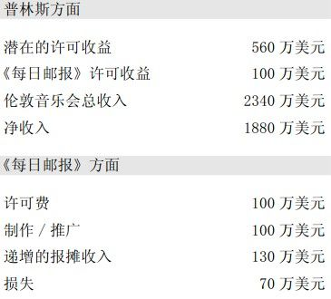

1）普林斯提升门票销售  
严格讲来，这位艺术家在这桩买卖上吃了亏。他向《每日邮报》收取了每张光盘36美分的许可费而非他通常2美元的要价。但他的演唱会门票销售大大弥补了差额。这位天王巨星8月份在伦敦02剧场开唱21场，这为他带来了在该地区创纪录的音乐会收入。

2）《每日邮报》提升了自身品牌  
在赠品CD推动下，当日报纸发行量当日陡增20%。这为报社带来了额外收入，不过不足以弥补支出。但《每日邮报》管理层仍认为买赠活动是一项成功之举。总编辑斯蒂芬。迈伦称，该促销活动经过了编辑审议并得到了资金支持。“因为我们是开拓者，广告商希望与我们在一起。”

如今无论是乐队数量还是创作的音乐数量都较以往大幅增加。2008年，美国最大的音乐零售商iTunes向其播放列表中添加了400万个新音轨（约合40万张专辑的价值）。如今，很难找到一个没有自己MySpace 主页的乐队。在很多乐队的MySpace主页上，你都能免费听上四五首歌。如今有更多的人每天听音乐的时间越来越长，这得益于iPod，它使你能够将喜欢听的音乐随身携带。电视、电影、商业广告或电脑游戏中的音乐许可规模也远超以往，而且移动音乐产业，如铃声、“彩铃”蓬勃发展，个性音乐销售发展迅猛。再后来便是“苹果”提出的那句宣传Mac品牌的著名口号“筛选、编辑、烧录”，它无疑为宣传其电脑、音乐播放器和电话的免费音乐增添了力量。

最为重要的是，音乐会业务正在繁荣发展，这在一定程度上得益于免费音乐扩大乐迷基础的能力。现场演出一直是该业务领域最为赢利的一部分。据普林斯顿大学经济学家艾伦·克鲁格统计，2002年，排名前35位的巡演乐队（包括“鹰乐队”和“戴维·马修乐队”在内）开演唱会的收入是唱片和版权销售收入的四倍。有些乐队，如滚石乐队，其收入的90%来自巡演。门票很容易就被炒到数百美元一张，从而形成了一个倒卖巡演门票的“欣欣向荣”的二级市场。（2008年，eBay收购了StubHub，后者便是全美最大的票务转售拍卖网站之一。）为什么不这么做呢？门票紧张总成为我们难忘的记忆。

如今，夏季音乐节延长到半年时间，围绕音乐节安排自己生活的一代人正逐步成长起来。况且乐队收入不只来自门票销售：巡演通常都能拉到赞助，如Vans Warped Tour音乐节（该大型露天音乐节由著名极限运动品牌Vans 赞助），而且像“骆驼”这样的公司也会向音乐节主办方付费以获得为参加节日活动着免费提供香烟或其他产品的机会。在食物、饮料、商品和住房之间，各种音乐节本身就是一个完整的旅游产业，它建立在众多乐迷从未想过付费以享受音乐饕餮的基础上。

大厂商都很清楚地知道它们在音乐世界的地位正处于持续衰落中。“音乐行业正在不断发展壮大，”华纳音乐主席爱德加·布朗夫曼在2007年如是对投资者说，“唱片业不会再扩张。”要如何去应对是另一个问题。有些厂商已经决定奋起抗争以求得生存，它们通常采取反盗版诉讼的做法，并向那些试图为消费者创造获取音乐的新途径，如向提供互联网广播服务的公司提出巨额版税要求。其他厂商则决定通过采取向“360 模式”演进的方式实现创新从而冲破乱局，在这一模式中它们对一位艺人的职业生涯进行全方位展示，包括巡演、许可、签名和制造相关商品。（迄今为止这一模式难言成功，主要是因为各厂商并不擅长做这些“分外之事”，而且艺人们经常抱怨厂商从中提成比例过高。）

某些小厂商在创新方面取得的成绩更为显著，它们通常借助某种形式的免费策略。热门博客博主彼得·罗杰斯创办的公司RCRD LBL，提供广告商赞助发行的免费音乐。听众自主出价模式得到广泛应用，而且那些销售复古版黑胶木密纹唱片以博得音乐发烧友欢心的小厂商通常都会提供免费数字版唱片下载服务以供乐迷试听。2006年末在纳什维尔，INO Records唱片公司以德里克·韦布的《知更鸟》为蓝本进行了一项试验。歌手对此做出了如下解释：

我发行了一张自认为很不错的唱片，但厂商疏于市场推广，销量一直不景气。因此我确认厂商有意让我向乐迷们免费赠送这张唱片。这可有点难为人了。我们不仅要询问每个下载了唱片的听友姓名、电子邮件地址和邮政编码，还要请他们通过登录用的电子邮箱（但我们并未保留这些邮箱地址）将专辑推荐给他们认为有可能也想下载该专辑的另外5位朋友。3个月时间里我送出了8万多张唱片。打那以后我就能够按照邮编筛选电子邮件列表从而找到我的乐迷的地址，而后发邮件邀请他们参加音乐会。现在我的音乐会门票场场告罄，而且还能在现场推销大量宣传品。我拥有了自己的事业。

还有很多与韦布相似的例子。但最有趣的是，与唱片业采用新模式的需求相同的实用主义，也为旧模式的最大赢家所分享。2008年创立的 “G-Unit Records”受文件分享影响而接受采访时，说唱巨星50 Cent 表示作为作为艺人仍具备厂商不具有的优势。毋庸置疑，文件交换对他的厂牌构成了负面影响，但要克服的困难远不止于此：

技术的进步影响着每一个人，而且我们都必须适应这种变化。音乐界要明白的很重要一点就是这实际上并未伤害到艺人。无论年轻乐迷是买CD听还是去“偷盗”，他仍会是所崇拜艺人的忠实拥泵。音乐会挤满了乐迷，而业界必须明白他们不得不对旗下艺人进行全方位包装。他们（业界）必须通过音乐会和宣传品来捞取尽可能多的收入。

### 免费图书

最后，如果本章不对免费图书做些评论就难言完整，从本质上讲本书也是其中之一（至少数字版是免费的）。在印刷类出版物中，图书是一种特例，我喜欢印刷精美的杂志，而印刷版杂志仍是大多数读者的首选。值得庆幸的是，图书产业并未陷入破产困境中，但这并未阻止众多作者（以及少数出版商）自行开展免费试验。

对大多数人而言，图书和音乐的最大区别在于，图书的高级版本仍是印刷版，而非数字版。对于它们在成本方面的劣势而言，以木浆为原料制作成书后具有很长的保存期、清晰度和便携性，更不用说摆在书架上看起来更顺眼了。但数字图书—音频书、电子书以及网络下载图书市场正迅速扩张，主要是为了满足印刷版图书无法满足的需求，包括读者在开车时仍能看书的需求以及无论身处何地都能看到想看的图书这种需求。

大部分免费书营销模式均建立在某种免费加收费策略基础上。无论是允许读者在有限时间内免费下载其中几章或者一直允许读者免费下载整本书的PDF版，数字版都是使最大多数读者试读新书的一种方法，以期某些读者会购买印刷版。

例如，2008年科幻小说家尼尔·盖曼推出了为期4周的免费赠送其作品《美国众神》（American Gods）数字下载版的活动。常见的恐慌和反对在第一时间呈现于作者面前：这么做将打压书店中印刷版图书的销量，而且更为极端的说法是，限定时间的免费下载方式有可能适得其反，因为到许多读者知晓这一消息时，可能免费下载时间已截止了。我们很难对第二种担忧之词恰当与否做出判断，但第一种说法确实被证明是错误的。不仅《美国人的上帝》成了畅销书，而且在该书提供免费下载的那段时期，实体书店中盖曼所有作品的销量一路飙升了40%。8.5万名读者在线试读了这本书，每位读者平均读了45页。超过一半的读者表示他们并不喜欢在线阅读这种方式，但这是鼓励读者购买更适于阅读的精装书的激励手段。之后，盖曼免费推出了他的另一本儿童书《墓地》（Graveyard），以在线流视频的形式提供免费阅读，一次播放一章内容，而这本书同样成为了畅销书。

对于非小说类作品，特别是有关商业主题的作品，免费书籍与免费音乐所采取的营销模式更为相近。低边际成本数字书籍实际上是为高边际成本演说或深入探讨而开展的市场营销。你可以拥有阐释作者免费观点的各种通用版本，但如果你希望这些观点与你自己的公司、行业大会或投资者会议的实际情况相契合，你就必须为作者“稀缺的”时间付费。（是的，这也是我所遵循的模式。讲师团的详细介绍就在我的网站上！）

这一观点甚至也适用于印刷版图书。咨询师们经常购买上千册他们自己出的“战略智慧”丛书并将其免费分发给潜在客户，这一策略太过普通以致现在编辑们在制定畅销书单时会使用特殊方式以锁定并忽略那些批量销售图书。在欧洲，有时候报社会提供小册平装本图书，有时以系列图书形式呈现，在报摊免费发放，这有助于增加报纸的销量。而且作家们越来越多地向任何希望对自己著作进行赏鉴的博主提供赠阅本图书，这可以说是“书评家的长尾”—理由是用一本书几美元的成本换取此种“口碑”非常值得。

就像免费领域的其他事物，免费图书并未得到一致称赞。霍华德·汉迪克斯—这位后来的美国科幻小说作家协会副主席就曾将免费赠送自己著作的作者称为“网络无赖”，而且也有出版商仍质疑免费图书刺激了更多的需求却无法予以满足（某些情况下他们的质疑是基于经验）。但在一个书店书架空间不断缩水且报纸上的图书评论版面逐渐消失的世界，作者们热切期望尝试一切能帮助他们建立读者群的方式。正如出版商蒂姆·奥莱利所言：“作者的敌人不是盗版，而是不为人知。”免费是使最大多数读者接触作品的成本最低的方法，而且如果样书真能发挥作用，一些读者就会购买“高级”版本。只要读者们仍希望读到印刷版著作，他们就会继续为这些图书买单。

如何使教科书成为免费品？

大学生每年花在教科书上的费用高达1000美元。这简直太多了，特别是一本定价160美元的生物学课本有可能一学期都躺在书架上，这就是为何旧书市场规模如此庞大，出版社如此费尽心机用新版本取代旧版本（二者只不过在页码方面有所不同）的原因。最终，这种模式将走向失败。何种出版模式会取而代之？也许是与纽约出版商Flat World Knowledge采用的“开源教科书”相似的模式。读者可以对这些免费作品进行编辑、更新并将其重新编写进定制的课程材料中。但出版商或作者如何从免费赠送定价160美元的教科书中赢利呢？

1）不仅销售教科书：可以按照不同版式和购买需求将传统教科书的内容分解（或重新编辑）成若干部分。重新编辑后的书目会吸引更多学生的关注，例如他们不愿意在线阅读整本书而会购买其中几章的MP3为期中考试做准备。

数字图书（在线）……免费  
印刷版图书（黑白）……29.95美元  
印刷版图书（彩色）……59.95美元  
（按需求印刷可以降低成本）  
可印刷的PDF版—全本……19.95美元  
（在Kinko’ s印刷/装订的开支为每本40美元）  
可印刷章（PDF）……1.99美元  
音频书（MP3）……29.95美元  
音频章节（MP3）……2.99美元  
音频摘要（10分钟）……0.99美元  
电子书阅览器—全本……19.95美元  
电子书阅览器—章节……1.99美元  
闪存卡—全本……19.95美元  
闪存卡—一章……0.99美元

2）诱惑作者：经过一段时间后，FKW为作者提供一个更高的版税和利润回报。由于书店方面涨价，传统出版商从一本价值160美元的教科书中可以获得净利润105美元，作者得到15%的利润。在一个共有100名学生的班级里，其中75名学生会选择购买这本160美元的教科书。之后的每个学期，由于旧版教科书越来越容易买到，销量下降幅度可达50%（出版商和作者均无法从旧版教科书销售中赢利）。到第四个学期，可能只有5位学生会付全价购买新书。作者的版税收入及出版商的收益将持续下降直到新版面世。  
但在FWK模式中，由于准入成本非常低，甚至免费，因此基本上不存在旧教科书市场。2008年在20所大学进行的一项测试中，不到一半的学生购买了某种形式的FWK教科书。尽管每位学生支付的平均书费仅为30美元，但FWK出版社仍能在6年后获得相同数额的收益（所付出的经常性开支更少且运营成本更低）。版税在教科书销售总收中所占比例为20%，如此一来两年内作者就可以赚得更多的版税收入。

[figure not shown]

[1] “中国墙”原为金融术语，指投资银行部与销售部或交易人员之间的隔离，以防敏感消息外泄，从而构成内幕交易，这里为引申义。—编者注

## 免费经济的“底盘”有多大：用美元和美分来衡量远远不够

### 导读

让我们赶快摒弃将“免费”当做市场营销噱头的做法。免费几乎就相当于整个经济。

注意力和声誉的价值显然很重要，否则各大公司不会花大本钱进行广告宣传以期影响人们的关注度，树立品牌声誉。每天我们都在为注意力设定价码：30秒内广播听众数达到1000的成本，决定商业的成败。

可进行衡量的最简单免费模式是“三方市场”，这是指得到广告商赞助的免费媒体圈。现在我们都很熟悉的第二种免费模式是免费加收费，在这一免费模式中少数付费客户补贴很多非付费客户。这既包括拥有不同产品定价等级的成熟型公司，也包括将所有产品或服务免费赠送的创业型公司。此外还有直接交叉补贴和非货币市场两种免费模式。

3000亿美元可以说是对免费经济相对合理的大致估算，这尚属于保守估计。

简言之，免费经济的规模堪与一个国家相比，而非微不足道。

这个问题一直困扰着我：免费经济的规模有多大？对于这一问题有一个合理的补充问题：你所说的是何种免费经济？这一点至关重要，因为有很多种免费经济，从正式的商品经济到非正式的志愿主义经济。令事情进一步复杂化的是，很难对真实经济形式进行衡量，假冒经济形式反而易于衡量。是的，确实如此。每天我们出于善意或社会责任而彼此间无偿地相互帮助都是免费的，但我们并没有对此进行过统计。而且“买一赠一”并未被当做一种值得推崇的新经济模式。

### 汉堡大王的营销策略

让我们赶快摒弃将“免费”当做市场营销噱头的做法。免费几乎渗透于整个经济。我猜没有哪个行业不以某种方式运用免费策略，从免费试用到商品内含的免费奖品。但大多数免费策略并非真正免费—这只是某种形式的直接交叉补贴，将你支付的款项从一处转移到另一处。这不是一个比“折扣经济”或任何其他市场营销策略更为独特的市场。

那么作为非货币经济形式的声誉经济和注意力经济又当如何呢？它们属于实体经济，这是就它们代表的市场具有可以衡量和估价的准货币（从“眼球”到Facebook好友）而言的。但由于它们本身又是非货币市场，根据定义无法以货币对其进行衡量。但这并未阻止人们进行尝试的努力，而且人们的尝试常常是富有创造性的。

2009年初，汉堡大王（Burger King）发布了颠覆市场营销宣传模式的商标。这一品牌活动被称为“汉堡王牺牲品”，参与该活动的Facebook 网站会员有机会得到一个免费汉堡，只要他从Facebook 好友列表中“删除”10位好友。（这是为了证明“你喜欢自己的朋友但更爱超级汉堡”，或者说得更好听一点，这是为“汉堡王”在众多食客热捧中赢得某种“美名”。）

当面对这种情况时，我们可以发现其实以汉堡来衡量经济状况的传统早已有之。《经济学人》提出的“巨无霸指数”比较了不同国家的麦当劳汉堡价格，观察各国货币汇率是否得到了合理评估（这基于如下理由，即卢比可以被伪造，但“巨无霸”就是“巨无霸”）。因此博主们迅速着手以“汉堡王牺牲品”和Facebook 开展相似的工作。

Facebook上的“好友”属于典型的声誉货币单位。你拥有的在线“好友”越多，你在Facebook 虚拟世界中的影响力就越大，而且你可以利用的社会资本就越多。确实，Facebook的绝大部分价值在于这样一个事实，即它已经创建了也许算是这个世界上最大的、使用声誉货币的封闭市场，而后者正是其数十亿美元估价的基础。

但切实搞清楚Facebook 究竟值多少美元一直是桩棘手的事情。它的价值也许就在于其拥有的众多用户及用户间的连接数，而这正关乎某人要创建何种“朋友关系”的问题。具体做法就是声誉货币的兑换，对于支付这种货币的人而言，它必然具有某种价值。但究竟值多少呢？而且那对Facebook的评估意味着什么？

### 免费经济规模堪比一个国家

注意力和声誉的价值显然很重要，否则各大公司不会花大本钱进行广告宣传以期影响人们的关注度，树立品牌声誉。每天我们都在为注意力设定价码：30秒内广播听众数达到1000的成本，迫使“超级碗”观众中断收看比赛直播的费用。而且每当电影明星的经纪人进行片约谈判时，影星的声誉就被赋予一定价值。但除了媒体和名流中备受关注的注意力和声誉外，上述两项因素在现实生活中屡见不鲜。问题是我们并不清楚这种例子还有多少。

注意力的全球供应是固定的吗？是否存在一个特定的注意力集合，而且每位YouTube明星人气大涨时，另一位的受关注度必然会下跌，以维持某种“宇宙常数”？一代人能比另一代人的注意力容量更大，或者说多重任务处理恰恰更为精细地分割了相同的注意力容量？

让我们再回顾一下“顿巴数字”（Dunbar number），人类学家通过观察得出了个体所能维系的人际关系网络规模，在这一有限的人际关系网中他或她熟悉结交的每一位朋友以及朋友之间如何交往。数十年的人类学研究及长期的文化研究将这一数字确定为150，但这是在Myspace及类似软件出现前的情况。如今借助各种交友软件，你可以维系的朋友关系数量是“顿巴数字”的许多倍。Myspace成员的平均朋友数约为180，而很多用户在Myspace 上拥有上千朋友。高科技已经增强了我们的声誉容量？或者说我们恰恰在淡化“朋友”的意义？

这些都是值得进行深入思考的问题， 而且也许答案还需要下一代人揭晓。与此同时，让我们浏览一下免费的某些具体形式并对其规模做出大致正确的评估。

可进行衡量的最简单免费形式是“三方市场”，这是指我们之前讨论过的得到广告商赞助的免费媒体圈。而且，主要是无线电和广播电视、大部分互联网媒体以及免费出版物的传播，包括报纸和“赠阅发行”的杂志。仅在美国排名前100位的媒体公司中，2006年广播和电视（不包括有线电视）广告收入就高达450亿美元。

几乎所有的媒体公司都提供免费且有广告商赞助的在线服务，正如许多非媒体类公司如Google所为，因此我将把整个在线广告市场囊括在“消费者不必为内容付费”一类。这类企业的广告收入在210亿美元到250亿美元之间。免费纸质报纸和杂志的广告收入可能还要多出10亿美元。毫无疑问我省略的其他一些较小市场类别及许多独立公司并未被包含在上述数字中。不过我们仍然保守估计美国线上线下内容和服务的广告总收入在800亿到1000亿美元之间。

现在我们都很熟悉的第二种免费形式是免费加收费（经济学家称之为“愿景”），在这一免费形式中少数付费客户补贴很多非付费客户。这既包括拥有不同产品定价等级的成熟型公司，也包括将所有产品或服务免费赠送的创业型公司，当然，它们要弄明白是否其提供的产品或服务存在发展为一种商业模式的充分市场需求（如大部分Web 2.0 公司）。

几乎不可能恰当地列举出使用该免费经营模式的所有公司，但位于马萨诸塞州坎布里奇的弗雷斯特研究公司（Forrester Research）已经预计2008年从公司方面（在Web 2.0服务方面进行投入的公司，它们中大多数使用的是免费加收费服务中的“增值”版）获得的免费加收费服务收入约为8亿美元。可以肯定从客户方面获得的收入约为公司增值服务收入的1/4，因此我们认为二者相加的总收入为10亿美元。

然后我们再将开源软件市场的收入加入其中。据另外一家咨询公司IDC研究，如今“Linux生态系统”（从红帽公司到IBM公司的开源咨询业务）约合300亿美元。据该公司估算，其他以开源起家的公司，如MySQL（年收入5000万美元）和SugarCRM（年收入1500万美元），免费加收费服务收入总计不到10亿美元。

此外还出现了“免费试玩”的在线视频游戏市场，其中大部分公司采用了免费加收费经营模式，而且大多是大型多人在线游戏，玩家可免费玩游戏，但游戏公司通过向大多数专注于赚取“数字财产”（升级、服装、新等级等）的玩家收费赢利。此类游戏首先在韩国和中国兴起（现在此类游戏产业在两国的产值为10亿美元），而现在已经进军美国，像角色扮演游戏RuneScape 和Neopets 均属此类。目前“休闲游戏市场”（从在线纸牌游戏到flash 游戏）免费加收费业务收入约为30亿美元。此类在线游戏市场业务收入总值为40亿美元。因此，免费加收费市场总值约为360亿美元。

为何免费自行车租赁业在一座城市发展势头如此迅猛，而在另一座城市却无人问津？

在巴黎，上班族可以免费租借一辆自行车并使用30分钟。自2007年推出这项业务以来，在广告商赞助下，Vélib'（“免费单车”自助服务系统的简称）如今运营着1451个自行车租赁站，共有可租赁自行车20000辆。相同的服务也在巴塞罗那、蒙特利尔以及华盛顿特区推出。为Vélib'提供资金支持的广告公司JCDecaux集团还负责在伦敦和维也纳推广这一单车租赁项目。然而，该公司在布鲁塞尔启动的“单车分享”活动—“城市自行车”却只是昙花一现。为何免费单车在巴黎盛行却在布鲁塞尔遭遇失败呢？

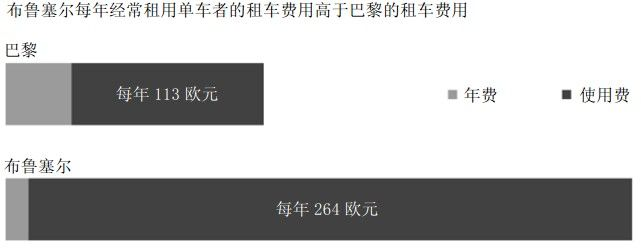

1）不要讨价还价  
在巴黎，只要租车人付费进行注册他们就可以获得不受次数限制的30分钟免费用车时间（租金随租用期限的增加而增加，分别为日租1欧元、月租5欧元以及年租29欧元）。30分钟免费时间过后就需要付费了，各时段租金分别为：60分钟1欧元，90分钟3欧元，2小时7欧元，以此类推。在布鲁塞尔，租车人只需付10欧元的年租赁费，但单次租赁的费用为每30分钟0.5欧元。公司在这座城市推广单车租赁业务的做法与其他城市恰恰相反：在布鲁塞尔只有骑行较长距离时租车才更为划算。但在布鲁塞尔这样大小的城市里平均骑行旅程也就20分钟。由此得出的经验是：人们更愿意支付固定的年租金自由骑行而不愿时时为计时租赁费困扰。

2）更多的租赁站加上更多可租赁的单车等于更多用户  
遍布巴黎的单车租赁站共1451个，可租赁单车共20000辆，这使得Vélib'能够为各个社区的居民提供服务，而非仅迎合这座城市特定部分人的需要。如此一来，参与这一活动的很多骑车人都是上班族。将其与布鲁塞尔的情况相比可以发现，布鲁塞尔仅有23个租赁站和250辆可用单车，而且全部集中于市中心。那么为何不在该市其他区域扩大租赁网络呢？其竞争对手清晰频道传媒公司（Clear Channel）握有该城市特定区域的单车租赁服务合同，这就阻止了“城市自行车”组织在这些区域设立有广告商赞助的自行车租赁站。

最后一类是礼品市场。无法对这一类产品的免费加收费收入进行恰当量化，特别是因为此类产品中的大多数根本没有附加的币值，但我将列出一些具有附加币值的例子，这样大家就能对此类产品的赢利规模有个初步认识。如果用户不必为播放器中的音乐库支付上万美元的使用费，苹果的iPod（苹果公司之所能从中赢得大部分利润正是因为这款播放器能存储上万首歌曲）才具有价值。当然许多人并未为此支付巨额费用，因为他们从朋友或文件交换网站中免费下载音乐。如此一来，苹果公司40亿美元的iPod年销售收入中有多大一部分应归因于免费策略的实施呢？

同样，Myspace 650亿美元估价中的多大部分源于其中包含的免费音乐服务？20亿美元音乐服务中的多大部分又是由P2P文件共享系统驱动的？还有许多诸如此类的问题。免费创造了大量衍生价值，但正如许多在货币经济中“行不通”的事物，很难恰当地对其进行量化分析。一场暴风雨或一个大晴天的价值何在？二者都能使土壤更为肥沃，但这样的益处过于分散以致无法对其进行精确说明。

因此，3000亿美元可以说是对免费经济相对合理的大致估算，这尚属于保守估计，而且肯定属于不完全统计，因为该统计根本没有将免费的初级形式—交叉补贴（“免费”获得一件商品的同时为另一件商品付费）考虑在内。在统计中也没有正确看待免费的影响，人们在用货币单位对其进行衡量的同时也用付费货币单位对其进行评估。但这确实让我们感受到免费经济的规模：在这一经济类型中存在大量“免费”商品，而且这种免费商品为商家带来了丰厚利润。

衡量“免费世界”规模的另一种方法是观察在其中工作的劳动力，这正是《连线》创始人凯文·凯利对互联网所做的研究。他注意到Google已经计算出互联网上存在超过1万亿各不相同的网页地址（URL）。（很难知道哪些网页可算做单独页面，因为像网页日历这样的网站能弹出无数网页—如果你点击“下一天”链接，但Google很容易将其分辨出来并从统计中剔除。）

比如，为了进行粗略计算，平均需要一小时对每个网页（或站点或任何带有永久链接的网页）进行搜索、组合、设计或编程，那么整个互联网就需要投入1万亿小时的工作量。

在15年里花1万亿小时建设互联网就相当于在相同时间内13800万人全职工作。如果说将其中40%的工作量投入“免费”生产—Facebook 和 Myspace 网页、博客、无数论坛的帖子和评论，这就需5500万人（约为德国的劳动人口总数）。如果为他们支付薪水，他们的报酬又是多少？姑且按2万美元算，那每年仅薪水支出一项就将超过1万亿美元。

简而言之，免费经济的规模堪与一个国家相比，而非微不足道。

# 第三部分 免费经济和一个免费的世界

## 免费经济学：一个老掉牙的笑话何以摇身一变成为数字经济学的定律

### 导读

免费经济中的产业组织结构具有双重性：既垄断，又竞争。

这使关于垄断竞争和报酬递增的理论在经济学中获得了新的活力。

如果“价格等于边际成本”是市场规律，那么免费就不只是选项之一，它是无可回避的终点。它是经济规律所具有的力量，而你只能长期与它进行抗争！

微软创造了一种能从网络效应中获利颇丰的产品。用某种产品的人越多，更多人就会感到不得不采取同样的做法。这易于造成赢家通吃的市场。不仅软件业如此，任何产品价值主要存在于知识产权而非物质资料中的行业均是如此。

垄断权变了模样。赢家通吃的行业从所谓的“递增收益”中获利，收益递增规律认为尽管产品的固定成本（研发、工厂建设等等）可能会很高，但如果边际成本相对较低，那么产量越大，利润率越高。追求“最大化”战略的回报在于投资者的固定成本被分摊到更多的单位中，从而使得每个单位的收益都有所增加。

赢家面向大多数人提供产品和服务时折本，而通过向少数客户提供有偿服务弥补损失。因为这些公司追求“最大化”战略，那些相对少数客户带来的回报能抵得上为千百万人提供服务创造的利润。

搭便车问题属于免费午餐的阴暗面。但对互联网来说，搭便车远称不上问题，因为大量消极顾客正是对少数做出贡献者的回报—他们被称为观众。

1838年，寓居巴黎的数学家安东尼·库尔诺出版了如今被视为经济学名著的《关于财富理论之数学原则的研究》（尽管在当时并不为外界称道）。在这本书中，他尝试着提出了公司竞争的经济学模型，并且在经过大量数学推算后得出结论：公司间的一切竞争关系都与他们生产产品的数量有关。如果市场中已经存在一个生产碗的工厂，而另一家公司也想开办一个生产碗的工厂，那么就要注意避免产量过剩，因为市场上同类产品过多将造成价格下跌。无论如何这两家公司都会不约而同且各自独立地规划产量，以尽可能使价格保持高位运行。

这本书很快就被外界遗忘了，即使对最具启发意义的著作而言，这也是常有的事儿。当时在法国经济圈占主导地位的法国自由学派对库尔诺的理论并不感兴趣，这无疑令他感到痛苦和沮丧。（不管怎么说他的学术生涯成就卓著、获奖无数，他于1877年逝世。）他去世之后，后辈经济学家重读《关于财富理论之数学原则的研究》这一经典著作，并得出结论认为库尔诺受到了他同代人不公正的忽视，他们呼吁重新对库尔诺提出的竞争模型进行研判。

1883年，法国数学家约瑟夫·伯特兰德决定对《关于财富理论之数学原则的研究》一书做出恰当评判。伯特兰德讨厌这本书。正如维基百科在介绍库尔诺时所言，“实际上库尔诺得出的所有结论无一正确。”的确，伯特兰德认为库尔诺将产量确立为左右企业竞争的关键因素这一做法过于武断，以致他半开玩笑地将库尔诺的模型重新界定为价格而非产量是决定竞争关系的关键变量。令人感到奇怪的是，如此一来他竟然发现了一种堪称简洁的模型（即使并非特别简洁）。

伯特兰德认为相比限制产量以提高售价、增加利润，各大公司更有可能降低价格以获取更多的市场份额。确实， 他们尝试着相互压价直到价格仅比产品成本稍高，这种做法被称为“边际成本定价法”。而且，如果更低的价格催生了更高的需求，那就再好不过了。

伯特兰德的竞争理论可以被简化成如下表述：在一个竞争性市场中，价格等于边际成本。

当然，在当时并不存在那么多真正意义上的竞争性市场，至少与这些数学模型界定的情况差别很大，因为各企业生产同质产品（不存在产品分化）且企业相互间无串通行为。因此，其他经济学家把他们归入试图以一种并非必要的方式将复杂的人类行为与各种刚性平衡对号入座的理论家之列。在接下来的几十年里，随着另一场学术争论的兴起，上述两派经济学家的争吵已经被人们遗忘。

但是，随着经济学的发展步入20世纪且市场竞争性日益增强、市场可度量程度不断增加，各路研究人员重又开始关注库尔诺和伯特兰德这两位观点相左的法国佬。一代一代的经济学研究者皓首穷经试图弄清楚库尔诺竞争模式更适用于哪些行业而伯特兰德竞争模型又适用于哪些行业。我将省略其中的细节，简单来说就是：在各种市场类型中，在哪一类市场中易于获得更多的原料，伯特兰德竞争模型就更胜一筹，价格往往就与边际成本相同。

倘若不是由于如今我们正在建设一个前所未有的最具竞争性的市场环境，伯特兰德的竞争模型在很大程度上仍只能引起学术界兴趣，这是一个各项服务和产品的边际成本近乎为零的模型。在互联网上，信息就是商品，而产品和服务很容易被复制，我们看到伯特兰德竞争模型正以一种甚至会令伯特兰德本人震惊的方式发挥着作用。

如果“价格等于边际成本”是市场规律，那么免费就不只是选项之一，它是无可回避的终点，它是经济规律所具有的力量，而你只能长期与它进行抗争！

但是请稍等。软件难道不是另一个边际成本接近零的市场？难道微软公司没有向用户收取数百美元的Office和Windows软件使用费？答案无疑是肯定的。那么这又如何与伯特兰德的理论相符？

答案在于“竞争性市场”。微软创造了一种能从网络效应中获利颇丰的产品：用某种产品的人越多，感到不得不采取同样做法的人就越多。以 Windows这样的操作系统为例，最流行的操作系统能吸引大多数软件开发商创造大多数能够在其上运行的程序。而以Office为例，由于你希望能与其他人共享文件，因此你倾向于使用大家都使用的相同程序。

这两个例子都易于造成赢家通吃的市场，这就是微软成就垄断霸业的方式。而且当你得到一项垄断权时，你可以收取“垄断租金”，也就是说装在一个标有 “Office”标志盒子里的两张塑料光盘售价300美元，而制造这些光盘的实际成本只有一到两美元。

### 垄断权变了模样

这样的实例在20世纪后半叶司空见惯—令人大跌眼镜的高利润率（90%、95%，甚至更高），这似乎与伯特兰德竞争模型描述的情形恰恰相反。不仅软件业如此，任何产品价值主要在于知识产权而非物质资料的行业均是如此。药物（药片本身几乎一文不值，但药物的研发成本却高达数百万美元）、半导体芯片（与药品类似），甚至包括好莱坞大片（电影制造成本很高但复制却相当便宜）统统属于此类。

这些行业从所谓的“递增收益”（increasing returns）中获利，收益递增规律认为尽管产品的固定成本（研发、工厂建设等）可能会很高，但如果边际成本相对较低，那么产量越大，利润率越高。追求“最大化”战略的回报在于投资者的固定成本被分摊到更多的单位中，从而使得每个单位的收益都有所增加。

这并无太多新意。正如经济学家保罗·克鲁格曼曾指出的，即便维多利亚时代的经济学家阿尔弗雷德·马歇尔（首先提出供求均衡理论模型的古典学派经济学家）也认为“雇用大量熟练技工，拥有专业供应商并不断改进和应用新技术的行业能大幅降低成本。”（他提出的典型例子就是英格兰谢菲尔德市的餐具制造商，他们有能力将工业革命中出现的新技术应用于银器的大规模生产。）但传统意义上“递增收益”指的是基于产品的递增收益。数字产品市场同样从消费的递增收益中获利，在该市场领域产品的消费额越高，产品的价值就越大，这就形成了一个足以确立市场主导地位的良性循环。

当然，只有当你有效遏制竞争对手时，这一良性循环才能发挥作用，而且利润如此之高的原因在于实现这一目标的各种有效方法在20世纪非常普遍。除垄断之外，专利权、版权和商标权、商业秘密及针对零售商的强制手段，都拒竞争对手于千里之外。

上述遏制竞争战略存在的问题是其作用发挥得并不像过去那么充分。由于复制技术（从便携式电脑到生物医学设备）的迅速发展和普及，从软件制造到内容提供再到医疗服务，各行各业中的盗版行为日益猖獗。而且随着在线配送方式的逐步推广，只要有充足的货架空间，就不可能使竞争对手远离消费者，无论你的商品在沃尔玛有多么大的吸引力。通过将大众化生产工具（如计算机）与大众化配送工具（网络）相结合，互联网恰恰变幻出在伯特兰德看来只存在于想象中的东西：一个真正具有竞争性的市场。

转瞬之间，一个理论经济学模型变成了在线定价的法则，要知道100年前这个理论初创之时还是被用来取笑另一位经济学家的。

认为在线经营时无须再惧怕垄断还为时过早。正如Google已经非常巧妙地将其拥有的网络效应展示出来，使微软在桌面操作系统领域确立压倒性优势地位的相同网络效应在互联网上表现得也相当突出。但在线准垄断的有趣之处在于它自身几乎不会带来垄断租金。由于Google在各领域拥有压倒性优势，它无须向客户收取文字处理软件和电子表格的300美元使用费—它将这些软件免费赠送给客户（统称Google Office应用软件）。即使对收费业务而言（主要是广告位），价格也是通过竞价而非由Google自身决定。

由此看来，对于所有在线品牌中的“老大”，从Facebook 到eBay均是如此。相对于它们的整体实力，它们拥有的定价权则微乎其微。Facebook只能实行最低广告费率，即每千次浏览不足一美元，而且每当eBay 试图抬高广告刊登费用时，其销售商就威胁弃用eBay，考虑到可取代的在线购物网站数量庞大，这种威胁并非空谈。

那么在这种情况下它们又是如何赚得亿万美金？规模。并不像那个老掉牙的笑话所说：每单生意皆有损失但仍可借助规模经营予以弥补。恰恰相反，情况是面向大多数人提供产品和服务时折本而通过向少数客户提供有偿服务弥补损失。因为这些公司追求“最大化”战略，那些相对少数客户带来的回报抵得上为千百万人提供服务创造的利润。对于消费者而言，这可是天大的好消息，他们享受到价廉物美的产品和服务。但对那些无法实现规模最大化的企业而言又意味着什么呢？毕竟，相对于每一个像Google和Facebook这样的大公司，仍有成百上千家小公司始终无法超越利基市场。

对它们而言没有标准答案：每一个市场都与众不同。免费在所有市场中都具有持久吸引力，但围绕“免费”做文章继而赚钱，特别是当你尚未拥有庞大用户群时（某些情况下甚至你已经拥有上述条件时），确实关乎创造性思维和反复实验的运用。本书后半部分讨论的相关案例仅算得上“小样”。

### 免费仅仅是另一个版本

这些模型背后的经济原理基本上属于我们之前已经讨论过的四种“免费”模式，而且经济学完全可以解释得通为何价格为零。定价理论基于所谓的“版本划分”，即面向不同类别的客户定价各不相同。“欢乐时光”（Happy Hour）酒吧的啤酒定价便宜，以借此留住顾客，待涨价时他们仍继续光顾。

支持版本划分这一做法的根本理念蕴涵着以不同价码向不同客户推销相类似产品的思想。当你在常规汽油和优质汽油间做选择时，你就在经历版本划分过程，而且当你半价观看一场早场电影或享受老年人优惠时，也经历了同样的版本划分。这便是免费加收费模式的核心：其中一个版本免费，其他版本则是收费的。或者说，按照每个人的需求为其提供服务，依据某些人的支付能力获取收益。

定价理论界定的固定费用（“一价通吃”）价格也可以催生免费服务。在类似Netflix公司向客户收取的邮寄DVD租金中，就能够发现这样的固定费用。每月交纳固定数额的租金就可以无限量租借DVD，每次最多可以租三张。尽管你仍须支付相应费用，但你不必为每一张新租赁的DVD买单（即使邮资免费）。由此看来客户能够感知到的观看一张DVD的费用，即将所租DVD寄回而后得到一张新片的费用实际为零。这“感觉就像免费的”，即便为了获得这项“特权”你一直在支付月租费。

这就是经济学家所说的接近零的“边际价格”实例，不能将其与接近于零的边际成本混淆。前者由消费者体验，而后者由生产者直接面对。最佳模式是将二者结合在一起时，正如Netflix 公司所为。

Netflix的成本基本上是固定的：吸纳订户、留住客户、建设配送站及研发软件和购买DVD。邮寄更多DVD的边际成本相当低：一点邮费、一部分人力（尽管目前已经高度自动化）及一些增加的版税—特别是与做出这一选择、享受便捷服务的订户们得到的益处相比。因此，当Netflix根据客户的经济利益（支付固定费用使得租赁更多DVD看起来似乎并不花钱）调整自身利益（将固定成本分摊到更多的DVD上，以减少边际成本）时，这笔生意中的每个人都从中获利。

在某种意义上，Netflix就像一个健身房。固定成本使这个健身房得以开张并维持运营。你使用次数越少，经营它的公司赚得就越多，因为如果大多数人不是每天都出现，那么健身房就可以更少的空间为更多的会员提供服务。与之相似，如果你不是经常将光盘寄回更换新片，Netflix赚得就更多。但不同之处在于你不会像使用健身房时一样感到自己使用率偏低有多么糟糕。有Netflix在，你就不必因迟交光盘数个星期而支付滞纳金，而相较于频繁更换新片，对公司来说这种情况可以说是赢利的。

在你身边，尽可找到这种接近于零的边际价格模型，从快餐到手机再到宽带互联网接入计划。在每一种情况下，固定费用将边际价格的负面心理状态—商家斤斤计较或自己被“敲竹杠”的感觉—统统消除，使消费者更乐于消费。如果他们消费额很高，这一模型就管用，因为它通常与一个低边际成本生产模型相匹配，而如果他们的消费额较低，则这一模型作用的发挥就更为充分（至少对于生产商而言确实如此）。正如Google首席经济学家哈尔·瓦里安所言：“谁是健身房最为推崇的顾客？就是那些交上会费之后从未现身的家伙。”

因此，对于经济学而言免费并非新生事物。然而，它通常会遭到人们的误解，它挑战的一个最为著名的原则就是所谓的“搭便车”问题。

### 搭便车不成问题

乔治·梅森大学经济学家拉塞尔·罗伯茨在互联网上开设了一个叫做EconTalk的播客（办得相当出彩）。在2008年的一档节目中，他做出了如下评论：

维基百科令我很感兴趣的一件事就是，我想如果你在1950年、1960年、1970年、1980年、1990年甚至2000年时询问一位经济学家“维基百科管用吗”，他们中的大多数会予以否定。他们会说，“你知道它确实不顶用，因为你从中得到的帮助简直少得可怜。而它也毫无利润可言，每个人都会搭便车。如果已经存在这么一本维基百科，他们会愿意读，但没有人想要自己写一本维基百科，因为这里存在一个搭便车问题。”那些家伙们实际上都错了。他们误解了一定程度超越搭便车问题之上的纯粹快乐。

搭便车问题属于免费午餐的阴暗面。就像徘徊在酒吧间的“免费午餐魔鬼”，搭便车者是那些对某种资源的消费量大于他们应得份额的人，或者是那些所负担产品成本少于应负担份额的人。 但由于“应得或公平”完全是主观的，当它导致市场崩溃时这也只被视为经济学中出现的一个问题。因此当某些贪婪的大学生把“一价通吃 ”的自助午餐统统吃光，迫使经营者将整个自助餐全部撤掉，这就是搭便车者造成混乱的一个实例。

但正如蒂莫西·李（计算机科学家及卡托研究所学者）已经认识到的，20世纪学者们对该问题的诠释实际上不再有效，原因有二。首先，它假设所消耗资源的成本高得足以引起人们的关注，或者换言之，必须对上述成本进行补偿。对于自助午餐而言确实如此，但对于那些人们乐于以观众身份免费参与的事情而言情况并非如此（这指大部分在线内容，对内容的浏览就足以支付相关费用）。

其次，它在很大程度上误解了互联网规模的效应。如我们此前所见，倘若你是唯一的一位班级家长志愿者，可能你最终会反感其他所有家长针对你的工作采取的不予协助的“搭便车”做法，这会令你感到极为烦心以致放弃原本从事的志愿工作。在这种情况下，大概10%到20%的父母不得不搭把手以避免出现整个教育系统土崩瓦解的风险。

但在线的情况就大不相同了，线上成员数量如此之众，只要有1%的参与者投入其中，大部分志愿者社区就会逐步得到完善和发展。搭便车远称不上问题，因为大量消极顾客本身正是对少数做出贡献者的回报—他们被称为观众。

如李所言：“这一大规模听众群扮演了使人们给予网站源源不断贡献的有力促进因素。人们愿意为一个拥有庞大读者群的百科全书捧场；确实，‘搭便车者’（亦称用户）的巨大数量是维基编辑这一职位最诱人之处。”

换句话说，为了弄明白为何免费作品在互联网上如此受欢迎这一问题无须去读博士，你只消忽略本书的前10章或你所学经济学教材的前半部分内容。

本书后半部分的其余内容将讨论这一问题的许多方面。首先我们将努力量化分析非货币市场，如关注和声誉，而且在某些情况下将它们转化为金钱。其后我们将评判那个自相矛盾的词“浪费”，我们被要求尽量避免浪费，但很多情况下恰恰应当追求浪费（一旦稀缺物品变得日渐充足，市场就会对它们区别对待—开发便宜商品借此创造其他一些更具价值的商品）。之后我们将目光转向中国和巴西—免费经济的现代化测试场。继而在虚幻小说中稍作停留，此处作为情节设计的充盈迫使读者开始考虑结果。最终，我们就免费的诸多反对意见进行论辩，从那些质疑其力量者到那些对其感到恐惧之人。

## 非货币经济：货币不起作用的地方，什么管用？

### 导读

原始的物物交换经济复活了。在货币不起作用的地方，什么管用？

免费经济对经济学的又一大冲击，是信息替代了货币，个体注意力替代了一般等价物，信息市场替代了股票市场。

在互联网上越来越多的产品信息被编入软件从而能够免费将其提供给顾客。钞票不再是市场上最重要的交易信号。相反，两个非货币因素的地位陡然提升，这两个因素就是我们通常所说的“注意力经济”和“声誉经济”。

行为经济学和“神经经济学”等经济学分支专业已经浮出水面，各经济学分支均试图解释为何人们会根据他们感受到的刺激而作出选择。这种刺激具有与一般等价物相反的性质—具体而特殊。注意力和声誉往往是这些刺激因素的组成部分，即便它们并未被正式界定为一个统一的市场。

互联网让我们在更高发展水平上复活了原始的礼品经济—心理上的股市。

随着信息时代的到来，社会科学家赫伯特·西蒙于1971年写道：

在这样一个信息极其丰富的世界，信息的充裕意味着其他某些事物的匮乏：被信息消耗掉的任何事物都处于稀缺之中。信息消耗掉哪些事物是相当明显的：它耗尽了信息接受者的注意力，因此信息的充裕造成了注意力的缺乏。

西蒙所言正是一条最古老经济法则的表现形式：“每一种充裕都创造出一种新的匮乏。”我们通常最为看重的是那些为数并不多的事物。例如，工作时供应充足的免费咖啡将唤醒我们对口感更好咖啡的需求，我们愿意付出高价为后者买单。对于从一大堆便宜货中淘出的任何高级玩意儿，从手工精制食品到优质矿泉水，通通如此。

“没有其他食物时，人们无疑只以面包为生。”亚伯拉罕·马斯洛在其发表于1943年的一篇具有化时代意义的文章《人类动机理论》中写道，“但是当面包不再是紧俏食物且人的胃口渐渐被填满时，人类的需求又会出现何种变化？”

他在自己提出的、如今已经为世人熟知的“需求层次理论”中做出了如下解释：“一旦有其他（而且是更高的）需求出现，那么这些需求，而非生理上的饥饿感将主导生物体。”在其“需求层次”金字塔的底部是物质需求，如食物和水。在此之上是安全。更高一层则是爱和归属感，而后是尊重；居于整个金字塔顶部的是“自我实现”，即对创造力等精神需求的追寻。

相同的“层次”模型也适用于信息。一旦我们对基本知识和娱乐的渴望得到满足，我们就会对自己究竟想要得到何种知识和娱乐变得更加挑剔，而且在这一过程中对自身及驱动我们做出选择的各种因素有了进一步认识。最终这会使我们中的很多人在创造的精神愉悦激励下从被动的消费者转变为积极的生产者。

通常在消费品市场中，我们手中钞票的缺乏会帮助我们尽量购买那些可用的产品—我们只买能买得起的产品（信用卡收支平衡）。这就是资本主义如何利用消费者乐于付款的商品“满足”消费者需求。但在线交易又是一种什么情况呢？在互联网上越来越多的产品信息被编入软件从而能够免费将其提供给顾客。钞票不再是市场上最重要的交易信号。相反，两个非货币因素的地位陡然提升。 这两个因素就是我们通常所说的“注意力经济”和“声誉经济”。

当然，注意力和声誉的市场环境与其他市场环境相比并无新特点。首先要在每一档电视节目中展开竞争，其次要在品牌打造方面进行竞争。名人树立声誉并将其转化为人们对他的关注度。但在线交易的独特之处在于二者可衡量程度如何，以及它们又是怎样使自己在平日里看起来更像实体经济。

“经济”是如何界定的？这个词出自希腊语，在希腊语中经济学［oikonomia，来自oikos（“家庭”）和nomos（“习俗”或“法律”）］意指管理家庭这一社会系统，因此也称为“家庭经济学”。直到18世纪中期，“经济”一词在政治和法律中得到广泛运用。但亚当·斯密在把经济学界定为市场研究，特别是我们现在简称的“稀缺情况下做出选择的社会科学”时，也就给出了这一术语的现代释义。

如今，经济学研究已经超越了货币市场范畴。自20世纪70年代以来，像行为经济学和“神经经济学”（neuroeconomics）等经济学分支专业已经浮出水面，各经济学分支均试图解释为何人们会根据他们感受到的刺激而做出选择。注意力和声誉往往是这些刺激因素的组成部分，即便它们并未被正式界定为一个统一的市场。

人们已经开展了一些巧妙的尝试以期借用经济学语言描述注意力市场，例如德国经济学家乔治·弗兰克在1999年经济学舞台上做出的这个描述：

如果根据他人给予我的关注度相应地衡量我对他人的关注度，那么一种核算系统很快就会被确立起来，它引用类似个体注意力社会股价这样的衡量指标。

社会雄心在二级市场中呈蓬勃发展之势。正是注意力资本的股票交易界定了“名利场”这一表达方式的确切含义。

然而当时对注意力进行量化分析时，无论这意味着什么，人们只是对出现在媒体上的那一个人（创造者）进行衡量。

但如果我们像对待金钱那样对注意力和声誉进行量化分析会出现何种情况？如果我们能将它们形式化为恰当的市场形态，从而可以借助经济学家在传统货币市场分析中使用的方程式对其进行解释和预测，那又会怎样？要这么做，我们就需要注意力和声誉展示出与其他传统通货形式相同的特点：可衡量、数量有限且能转换为其他货币。

得益于蒂姆·伯纳斯·李于1989年开发的一项新型网络技术—现代超链接，我们正无限接近上述目标。这其实是件很容易做到的事—仅仅是一串以“http://”开头的字符，但它创造的却是用于注意力和声誉交换的形式语言及适用于二者的货币形式。如今当你在自己的博客中与他人进行链接时，实际上你正赠与他们某些属于你自己的声誉权。在某种意义上，你正向自己博客的浏览者们发出倡议：“离开我，去到另外一片天地里吧。我想你们会喜欢，而且如果你们这么做了，也许你们会因为我的推荐而更加感念我。而如果你更加感念我，也许你就会更频繁地光临我的网址。”

在理想状态下，声誉的这种转换使双方都变得更加富有。良好的建议在博主与浏览者间建立起信任关系，而接受建议这一行为选择同样使浏览者对博主更加信任。在这种情况下，双方间的交易就水到渠成了。

如今我们拥有一个真正的声誉市场—它就是Google。除了Google旗下的搜索引擎网页排名算法，还有什么是线上声誉的货币表现形式？搜索引擎网页排名算法评估界定构成互联网舆论网络的导入链接。而除了互联网流量之外，还有什么更好的注意力衡量指标？

网页排名算法是一个看似简单却有着巨大能量的创意。它基本上说明了导入链接就像选票，而且来自本身拥有很多导入链接的网址的导入链接比来自其他网址的导入链接更有价值。这是那种一台计算机就能完成的推算，因为它内存中有互联网的整个链接结构且对每个链接进行递归分析。（有趣的是，网页排名算法以科学出版工作中小规模的早期工作为基础。借助其他作者在各自作品脚注中引用他或她的观点的多少推算一位作者的声誉度，这一方法被称为引用分析。没有比学术声誉更为显性的声誉经济，学术声誉反应了教授从任期到待遇各方面的情况。）

从经济角度看，我们可以使用这样一个算法将声誉经济转化为注意力经济再转化为现金：你的网址的经济价值在于你的网页排名（1到10之间的一个数）从任何给定条件的Google搜索结果中带来的流量乘以该条件的关键字值。（网页排名越高意味着流量越大，因为你在搜索结果中的排位更靠前。）只要在你的站点发布AdSense广告并与Google分成，就可以将流量转化为实实在在的钞票。

无论喜欢与否，自从搜索引擎问世以来我们都生活在Google经济中，至少我们的一部分生活内容与其密不可分。在一个具有代表性的站点上，1/4到一半的网站流量来自Google搜索。存在一个被称为“搜索引擎最优化”的整体产业，它帮助各站点增加其在Google搜索结果中的可见性。可以说网页排名是声誉的黄金标准。

这使得Google共同创始人拉里·佩奇（网页排名算法的奠基人）成为Google经济的“央行行长”。他和他在Google的同事们掌控着资金供应。他们不断调整这一算法以确保它保持自身价值。随着网页不断增加，他们使网页更难获得排名以避免排名出现“通货膨胀”而贬值。如果他们发现以垃圾链接形式出现的网页排名造假，他们就调整算法从而将垃圾链接从估算中排除出去。通过辛勤工作使自己的搜索结果较竞争对手的同类搜索结果更具相关性，这使他们保持了所用货币的价值，也将维持Google的市场份额（当前为具有压倒性优势地位的70%市场份额）。阿兰·格林斯潘的工作与此大同小异。

如今就像与真正的央行行长们在一起，控制某种货币发行远不及控制整个经济。想象一下Google就像互联网中的超级大国“美国”—众多声誉和注意力经济体中规模最为庞大者。它并非闭关自守型经济，因为它本身正是规模更为庞大的互联网经济的一部分。而围绕在它周围的则是不计其数的其他各种声誉和注意力经济，每一种经济都有自己的货币表现形式。

Facebook和Myspace主要运营内容有关“朋友”，eBay则拥有卖家和买家评级标准。Twitter有“追随者”，Slashdot有“道德值”等不一而足。在每一个网站，人们均可创建声誉资本并将其转化为注意力。如果他或她希望将注意力再转化为金钱（大多数人不希望如此），那就得指望每个人都能搞清楚如何实现这一目标，但目前实现注意力和声誉的量化是各国普遍开展的一项工作。这是一个现在我们全都参与其中的市场，无论我们对其是否了解。曾经令人难以捉摸的声誉问题现在正日益具体化。

在互联网上，所有这些经济形式并存且随着注意力的变化趋势而消长—即使它们想要从总体上控制注意力，它们也无法做到。但存在一个处于发展之中的市场类别—封闭型线上经济，与其他经济类型中央行行长所拥有权力相比，在这一经济形式中央行行长拥有远比前者大的权力。在线游戏层出不穷，从“战锤”到“天堂”，这些网游一般都使用两种货币：注意力货币，玩家通过玩游戏赚取虚拟货币；现实货币，他们可以用以购买虚拟货币，如果他们不想费时间自己去挣。

大学教育何以免费？

你不必考取加州大学伯克利分校就能聆听理查德·穆勒讲授他的热门课程《总统必修物理学》（Physics for Future Presidents）。你可以在YouTube上找到它，此外在网上同样可以搜索到其他100多位伯克利教授的演讲和授课，这些精彩内容已经被网友们浏览了200多万次。伯克利大学并非独一家：斯坦福大学和麻省理工学院也在YouTube上播放教授们的讲座，而且麻省理工学院的“开放课程软件”计划实际上已将该校所有课程内容都放在了互联网上，从讲稿到课程作业和演示视频。在上述名校就读并选修这些课程的成本是一年35000美元。

学校为何要将其免费赠送？

1）讲座并非大学教育的全部  
除无法通过观看YouTube视频获得学位外，大学教育的亲身体验远非讲座和阅读所能涵盖。所交学费能让你拥有直接向大师们提问的机会，使你能够分享他们的真知灼见，并受教于穆勒这样富有魅力的学者。此外还能与其他同学交流思想，相互帮助，建立友谊。这些学校将这种开放式课程视为市场营销手段而非大学教育的替代物。最好的学生选择自己想去哪所学校，参加某项独特的学习活动或倾听一位教授讲课会产生一种震撼心灵的体验，而这种体验总能赢得学生们的心。

2）创造期望获得专家指导的需求  
迄今为止，穆勒教授一次讲座的浏览次数达到20万。这是加州伯克利分校足球场观众容量的三倍。在成为互联网名人后，穆勒谈下了一份出版合同，他准备将自己为学生们编的教材写成一部通俗硬皮书。2008年夏天，这部《总统必修物理学》为各大主流媒体广泛热议。数月之后，这本书仍占据亚马逊畅销书排行榜榜首。人们一眼就能看明白“免费”给穆勒教授带来了多大好处。

上述任意一款游戏中，作为游戏运营商的各大公司严格履行着“央行行长”的职能。如果“战锤”研发者未对黄金供应设置上限，这款游戏的价值将下跌而转售市场也将土崩瓦解。游戏设计者通常将理论经济学者吸纳入团队，以协助设计他们游戏内的经济形式，避免沾染现实世界各经济类型的所有弊病（从流动性不足到欺诈）。

但最终，所有这些游戏都以最稀缺因素—时间为转移。时间确实就是金钱，而且在这些游戏经济的核心位置存在它们之间的一种权衡。较年轻玩家可能时间较金钱更宽裕，他们能通过点击相应链接积聚注意力货币。较为年长的玩家也许金钱比时间更充足，他们能买通捷径。游戏设计者们试图在二者间达成平衡，这样玩家们就能够以任一种方式对战和升级。而且由于设计者们这么做了，他们正创造出某些前所未有的、量化程度最高的物物交换经济类型。

### 礼品经济

1983年，社会学家路易斯·海德出版了《礼物》一书，这部著作首次设法解释了一种最为古老的社会传统—馈赠的作用原理。他将视线聚焦在太平洋岛国和其他尚未正式进入货币经济时代的“土著”社会。在这些国家和地区，借助礼品交换和各种礼仪程序，人们的声望和社会地位得以确立—文化货币取代了金钱。

这些社会中很多都有着丰富的自然资源—食物确实都长在树上—所以他们的基本物质需求由自然界提供。正因如此，他们可以沿着马斯洛的“金字塔”模型向上走且重点关注自身的社会需求。礼物扮演了社会黏合剂的角色：在一些美洲土著部落里，礼品暗含的规则是其本身附带的互赠义务（“回赠礼物”）。而且礼品也不应被保留，而应转赠他人（“礼品必须始终处于流动中”）。现在我们将“印第安送礼者”（意指送礼后期待还礼的人）这一术语视为贬义词，但它源自海德的评论：在上述文化体系中，一个人永远不会真正拥有一件礼品。相反，礼品是善意的象征，且只有在人与人之间的礼品交换中得以留存。

海德主要研究物品，即相交换实物的礼品经济（如我们当前在“全球捐赠网”上看到的礼品捐赠）。但一种更大规模的行为礼品经济一直存在，此处“行为”意指我们彼此间免费为对方做的事。与注意力和声誉经济一样，随着其在网上迅速流行，这一短暂的礼品经济也已在一夜之间变得清晰和可度量。

在我任职的传统媒体行业中，你必须付给撰稿人报酬。每字1美元是最低稿酬，文笔上佳的作者能拿到每字3美元甚至更高的稿酬。如果我正为一本印刷精美的杂志写稿（且要求对方支付顶级稿酬以体现自我价值），我可能已经赚了23美元。但情况发生了变化。据统计共有1200万时常更新的博客，其博主或博主群每周至少更新一次博客，如此一来一周创造的文字多达数十亿，但这些作者中只有少数几千位是领取稿酬的。

这种情况随处可见，从亚马逊网站的业余作品评论家到那些电影发烧友，后者已将互联网电影数据库（IMDB）打造成有关当今全球电影和影视制作商的最详尽信息库。其中一些属于各大论坛支持小组非正式发表的帖子，但也包括那些耗时数周或数月的项目，如玩家创建的视频游戏攻略和各种目录（总有很多“集大成者”，他们乐于成为某些事物的顶级专家并与大家分享他的成就）。

这毫无新意—人们一直都是免费进行创造并作出贡献。我们并未将他们所做的事情称为“工作”，因为这些都是无偿的，但每当你免费为某人提出建议或自愿做某事时，在另一种情景下你所做的就是某些人的工作。如今专业人士和业余爱好者突然间出现在了相同的注意力市场中，而且这些平行领域正处于竞争中。“门外汉”的数量远超过行家。

如此多的二手货何以变成免费品？

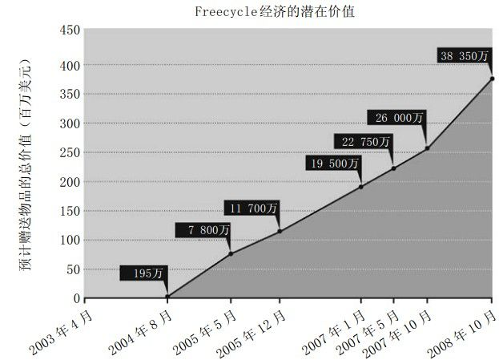

如果不是金钱的话，是什么因素激发了“门外汉”的创造才能？许多人认为大多数情况下礼品经济是由慷慨推动的，但如海德在对太平洋岛国的观察中发现的，这一经济形态并非如此毫不利己。亚当·斯密说得对，理性而开明的利己主义是人性中最强大的力量。人们“义务劳动”一般都有自己的理由：因为觉得有趣，因为他们要表达自己的某些感受，因为他们希望人们能关注自己，因为他们希望自己的观点能得到大家的认可，以及其他不计其数的个人原因。

2007年，O'Reilly传媒公司的编辑安迪·欧瑞望着那些令人眼花缭乱的用户自创文档—软件、硬件和游戏的使用手册，这些超出了原创者提供的文档范围—他在思考是什么激励着人们这么做。他开展了一项为期一年的调查，而后将调查结果罗列出来。居首的一个原因就是“社团”—人们感到自己是某个社团的组成部分且希望为社团的活跃和发展贡献一份力量。其次是“个人发展”，在这一点上又回归到马斯洛“金字塔”模型的最高一层，即自我实现。再次是“相互扶持”，很多此类贡献者都是社会学家所说的“行家”，即乐于与他人分享自己所拥有知识的人。（有趣的是，在欧瑞的调查结果中，声誉在所有激励因素中的排位相对较低。）

那么人们又是从哪儿挤出来的时间呢？只能是不做其他一些事—放弃那些无法获得相同社会和情感奖励的事。只消想想如果我们能充分利用浪费在看电视上的一小部分会怎样。（实际上，无须想象那种情况：各种事情的等级排序变化趋势表明，收看电视节目这一活动的排位已经达到顶级，而我们现在已经越来越倾向于选择那些既允许我们消费又给予我们创造空间的节目。）

在食物、住所及马斯洛“层次需求”中其他物质需求已经得到满足而无须再从早到晚躬耕垄亩的世界里，我们发现自己拥有大量“空闲时间”，或者说是社会学家眼中的“认知盈余”，即我们在工作中并未将自身的能量和知识完全释放出来。与此同时，我们的情感和智力需求在工作中也并未完全得到满足。在我们重视的某个领域中，我们自身的“空闲劳动力”让我们拥有了尊重、关注、表达和观众。

简言之，不领受报酬而做我们喜欢做的事使我们感到比干工作更开心。尽管我们仍必须填饱肚子，但如马斯洛所言，我们的生活本来就不只是解决温饱问题。以一种具有创造性且受到赞许的方式为所在社团作贡献这样的机会，正是马斯洛视为高于所有其他需求的一种自我实现。而且这种机会也是很多工作无法提供的。难怪在志愿工作的推动下网络发展如此迅猛—这些志愿工作使人们乐于进行创造性工作，乐于奉献，乐于对外界施加影响，而且乐于被视为某一领域的专家。几个世纪以来我们的社会中一直存在实现这种非货币性产品经济的潜力，等待着能够完全实现这一经济形式的社会系统和工具的出现。互联网提供了这些工具，而转瞬间一个免费交换市场就随之兴起。

## 有时浪费是一种美德：创造富足生活的最佳方式就是放弃控制

### 导读

我们同时要在匮乏和充裕两个市场进行竞争。

一代的匮乏是另一代的充裕。自然在浪费生命的过程中寻找存活率更高的生命。它使DNA发生变异，在一次又一次失败后不断进行生命的创造，以期偶尔会产生一种胜过之前出现各种基因排序情况的新排序，而人类将不断进化。个性化就是商业世界的生物多样性。

自然界如此挥霍的原因在于各种“遍地撒网”战略是实现数学家们所说“全面开发潜在空间”目标的最佳方法。

从数学家所说的“局部极值”中得到“全球极值”的方法，就是在整个进程中探索众多无结果的“最小值”。这么做是在浪费时间，但最终它将给人们带来回报。

也许慷慨接收废物的最佳之处就是YouTube 网站了。我们总是选择那些我们真正想看的“低质量”视频而非那些我们对其并不感兴趣的“高品质”视频。事实上，个性化不是低质量，而是切合实际；大规模也非高品质，而是脱离语境。卡拉OK的歌声不是低质量的，而是符合当下心情的；机器发出的歌声虽然完美，但不一定能针对每个人当下打动人心。价值的高低正在颠倒。

关键点在于：匮乏让大规模更具价值，充裕让多样化更具价值。

我们擅长匮乏思维—这是20世纪的组织模式。现在我们也必须学着善于进行充裕思维。

工作中我不时收到来自IT部门的电子邮件，告诉我们现在是时候让员工们“从共享文件夹中删除不需要的文件”了，这说明不需要的文件占满了员工们电脑存储空间。由于我们是遵守规章制度的员工，我们都一丝不苟地查看我们在公司服务器上存放的共享文档，扫描其中文件以确定我们是否真的需要它们，并删除那些我们用不到的文件。也许你也在这么做。

这么做了很多年后，有一天我开始猜想IT部门实际为我们办公室究竟预留了多大容量的存储空间。在我心中生出上述疑问时，一兆兆字节（1000GB）存储空间约合130美元（这可能使你对这一问题有一个直观的感受）。最近，当我们在家中配置标准戴尔台式电脑时，这些孩子们用来玩游戏的电脑已经装上了存储空间达兆兆字节的硬盘驱动器。

那么我们整个办公室的电脑有多大存储空间？原来并没有那么多：500GB，也就是兆兆字节的一半。我的孩子们拥有的计算机存储空间竟然是我所在整个工作场所存储空间的两倍。

这是怎么回事？答案很简单：不知何故我们一直以为存储空间较为昂贵而实际上它已经变得非常便宜。我们将数量充足的东西，如硬盘驱动器空间视为稀缺之物，而真正稀缺之物—人们的时间在我们看来又似乎是充裕的。我们将方程式左右两项掉了个个儿。（在这儿简单提一下，我所在办公室的计算机很快增加了大量存储空间而那些让我们删除不需要的文件的邮件再也没有现身！）

这种情况随处可见。当电话公司通知你语音信箱已满，那其实是一种人为的匮乏—存储100条语音信息的成本不足5美分，而且普通的iPod就能存储3万条语音信息（记录语音信息的质量比音乐质量低，因此它们占的空间更少）。通过迫使用户花时间删除语音邮件，电话公司节省了用做存储成本的一部分现金却浪费了消费者的大量宝贵时间。他们管理自身能够衡量的稀缺物（存储）却忽视了去管理他们拥有的客户美誉度这一更为重要的稀缺物。在最受消费者厌恶公司排行榜上，电话公司仅次于有线电视公司位居第二也就不足为奇了。

这就是浪费带给我们的教训。正如卡沃·米德鼓吹损耗晶体管而艾伦·凯就在滤镜软件上大量使用晶体管作为响应，这一软件使计算机变得更易操控。因此今天的改革派是那些发现新的充裕之物并搞清楚如何将它们浪费掉的群体—当然是用一种好方法！

但与浪费有关的趣事是它总与你对事物的稀缺判断有关。我们的祖辈生活在一个长途电话被视为昂贵奢侈品的年代，因此打长途电话前总是要预先计算好时间并尽量缩短通话时长。即使今天，很多人发现很难使那个时代的人煲一次长时间的长途电话“粥”—他们仍能听到脑子里的计时器在滴滴作响，好像很快将到时限。但我们的孩子们生活在一个足不出户，用他们自己的手机自由自在与远方好友联络的时代。他们乐于煲上几个小时的“电话粥”。从20世纪50年代电信成本的角度看，这可是惊人的浪费。但是如今，当上述成本已经下跌为零时，我们就不会再有半点犹豫了。这似乎并不是浪费，换句话说，一代的匮乏是另一代的充裕。

### 自然界“浪费”生命

我们的大脑似乎有抵制浪费的本能，在这一点上作为哺乳动物的我们相对自然界其他物种显得更为独特。在动物王国中哺乳动物的后代最少，因此我们投入大量时间和精力保护我们的每一个后代，从而使他们都能长大成人。一个人的死是个悲剧，有些时候甚至是令生者永远无法从悲恸中平复的悲剧。我们更珍视个体的生命高于一切。

因此，我们对浪费这种品性有着很深的心理感受。对那些遭到抛弃的玩偶或者吃剩的食物，我们总是感到不舒服。有时这么想是很有道理的，因为我们明白肆意挥霍的巨大社会成本，但通常情况下这仅仅是因为我们作为哺乳动物大脑思考问题的程序就是如此。

然而，其他各物种本性的作用原理与此并不相似。在一个产卵季，一条金枪鱼能产下1000万个受精卵，也许只有10个能发育到成年，每存活一个的同时将有百万个死去。

自然在浪费生命的过程中寻找存活率更高的生命，它使DNA发生变异，在一次又一次失败后不断进行生命的创造，以期偶尔会产生一种胜过之前出现各种基因排序情况的新排序，物种将不断进化。在很短时间内将所创造的大多数生物扼杀，自然借此检验万物，而“血爪獠牙”的战斗正决定了繁殖的优势所在。

自然界如此挥霍的原因在于各种“遍地撒网”战略是实现数学家们所说“全面开发潜在空间”目标的最佳方法。想象在一片沙漠里有两片相隔一段距离的水泊。如果你是生长在这两个水泊其中一个近旁的一株植物，你可以在两种繁殖策略中选择其一。你可以在根部附近播种，在那儿找到水的机会较大。这样做是安全的，但很快就会导致空间不足。或者你可以将种子抛向空中并让它们飘向远方，这意味着几乎所有飘出去的种子都将死亡，但这也是发现另一片水泊的唯一方法，在那里生命能够演进到一个新的生态环境中，也许是个营养更为充足的生态环境。从数学家所说的“局部极值”中得到“全球极值”的方法，就是在整个进程中探索众多无结果的“最小值”。这么做是在浪费时间，但最终它将给人们带来回报。

科幻小说作家考瑞·多克特罗（Cory Doctorow ）将这种做法称之为“像蒲公英一样思考”。他写道：从蒲公英的角度看，一粒，甚至大多数种子的去向并不重要，重要的是在每个春天，每一条街道上都飘满了蒲公英。蒲公英不想亲自照顾每一粒宝贵的种子，而是希望它们离开巢，认真把握自己漂泊的方向，以找到最佳生长环境，在那儿繁衍生息。蒲公英只是希望确保充分利用了每一个繁衍的机会。

这就是接受浪费行为的方式。种子便宜得可以忽略不计，将它们扔到如此远的地方这一做法似乎不妥，甚至有些特立独行，但这正是恰当利用大量机会的正确方式。

思索下Roomba机器人吸尘器的情况。很难看住它而且总是为它的蠢笨感到遗憾，因为它在房间里随意蹦来跳去，来回移动着吸尘却漏过了最明显的脏地方。但是最终，不管怎样，正是由于机器人在房间里的随机“走动”覆盖了房间的每一个角落，地毯变干净了。它可能会花一小时去做你5分钟就搞定的事情，但花的不是你的时间，是机器的时间，而机器有的是时间。

### 让娱乐视频播放起来更加安全

也许慷慨接收废物的最佳之处就是YouTube 网站了。我经常听到人们抱怨说Youtube根本无法与电视进行竞争，因为它里面“满是废物”。是的，我想人们说得没错。问题在于我们没有人能在“废物”是指什么方面达成一致，因为我们对它的对立面“品质”的看法同样莫衷一是。你可能正在寻找可爱的宠物视频，而对我钟爱的焊接教程不感兴趣。同时，我想要观看滑稽的视频游戏，而对你的烹调指南不感兴趣。我们当然乐于观看那些有关自己家人的视频，而对外人而言这些内容完全索然无趣。废物或者垃圾只是在旁观者的眼中如此。

即使最风行的YouTube视频也完全达不到标准的好莱坞“产品质量”界定，因为这些视频分辨率低且画面阴暗，更别提它们糟糕透顶的音质和压根儿就不存在的情节。但这些都不重要，最重要的是相关性。我们总是选择那些我们真正想看的“低质量”视频而非那些我们对其并不感冒的“高品质”视频。

之前的很多个周末，我的孩子们总要选择如何欢度他们在周六和周日的两个小时“荧屏时间”。我提议说今天看《星球大战》应该是个很不错的选择。他们可以从海量DVD里随便选择观看6部大片中的任一部，而且还有美味的爆米花做伴。或者他们可以去YouTube，欣赏由9岁儿童创造的《星球大战》乐高定格动画。无须犹豫抉择—孩子们已经跑向了电脑。

这表明我的孩子们及其他很多孩子打心眼儿里并不喜欢乔治·卢卡斯拍的《星球大战》。他们对同龄小伙伴创作的《星球大战》更感兴趣，而从不介意那晃来晃去的摄像机和镜头里略显粗糙的人物形象。当我渐渐长大时，商家们设计出了很多意在将《星球大战》电影的特许经营权延伸到儿童世界的巧妙的小玩意儿，从玩偶到便当盒，但据我所知没有人想起孩子们自己动手创作的乐高定格动画。

对定格动画版《星球大战》的需求肯定一直都存在着，但却并未显现出来，因为市场上没有商家想要开发这种商品。但有了YouTube之后情况就大不相同了，我们无须得到商家的许可即可做这些事，一个无形市场陡然浮出水面。而且，我们发现了一个被商家忽略的类别。（还有很多类似的业余爱好者《星球大战》市场，从同人小说 <sup>[1]</sup> （fan fiction）到成年人组成的第501军团，他们自己动手制作令人惊诧的“风暴兵”服装，并集结起来重现真人版的星战传奇。）

出现在YouTube上的所有这些随机制作的视频就像纷飞在空中的蒲公英种子，它们寻找着适于扎根的沃土。在某种意义上，我们在搜寻质量更高的视频过程中不断“浪费视频”，不断发掘电影表现形式的潜在发展空间。YouTube就是这样一个规模庞大的试图创造未来电视呈现模式的聚合性试验，用户每次上传的内容都未及深究且数量庞杂。总有一天，借助YouTube和其他与之类似的平台，每一部能够进行制作的视频都将被搬上银幕，而每一位有能力成为电影制作者的电影人都能实现自己的梦想，每一个可能的利基市场都将得到开发。如果你降低对某一领域进行探索的成本，那么你在探索过程中就会随性而为、不受羁绊。

没有人决定某一视频节目是否足够优秀而应当占用稀有的频道空间，因为频道空间本就很充裕，如今进行空间分配的成本几乎为零。现在向一位观众播放一小时视频节目的成本约为0.25美元，明年这一成本将下降至0.15美元。再过一年将少于0.1美元。这就是为何YouTube的创建者决定把它奉送给大家，不仅免费而且可自由取予。结果虽然造成了杂乱不堪的格局且与职业电视人的本意背道而驰，但这符合充裕的需求。如果YouTube没有这么做，也会另有他人这么做。

上述做法可被归结为充裕意识和匮乏意识的差别。如果你正控制着稀缺资源（比如黄金时间广播计划表），你在安排节目时必然会存在偏见。播放大量长达半小时的网络节目确实要付出一定成本，而且因为这些节目的观众数量达不到千万而遭到的惩罚明明白白地体现为公司的财务赤字和丢掉的饭碗。这就难怪网络影视公司的高管们折回到连续剧套路上并求助于明星大腕—在这场昂贵的游戏中他们才是稳赚不赔的赌注。

但是如果你手里握有丰富的资源，那么你就能冒险碰碰运气，因为失败的成本非常低。如果你上传到YouTube的视频只有你妈妈一个人欣赏，也不会导致任何人被炒鱿鱼。

然而，对于YouTube取得的所有成功而言，迄今为止它尚未赚钱为Google赢利。这家互联网业界巨擘一直没能弄清楚如何使视频广告与内容相匹配，就像它在网上将文本广告与文本内容相搭配。它实际上并不知道你上传的视频包含哪方面内容，而且即便它知道，可能也没有一个相关视频与之搭配。与此同时，广告客户明显对他们的品牌与用户自创内容相抵触感到很不舒服，这会令用户生厌。

电视网络在这一缺陷中发现了机会而且创造出一种颇具竞争性的视频服务，它就是Hulu。它提供的大部分视频为商业视频，而它们中的大部分来自电视节目，但却像YouTube那样便捷和易得。由于其发布的视频内容数量有限，通常与广告客户自电视节目中已经买下的内容相同，他们乐于将这些商业广告插播为前置贴片式广告和后置贴片式广告，甚至直接在节目播放过程中插播这些广告。当然，这是免费的。它与YouTube的做法不同，它让你用自己的时间和烦恼为它们买单—就像普通电视节目中恼人的广告一样。但是如果播出的节目是你想看的《我为喜剧狂》，而且你特别想在电脑上看这部片子，那么这就是你能得到它的唯一合法方法。

### 匮乏管理

YouTube的模式是完全免费—免费观看，免费上传你自己制作的视频，免受干扰，但它并不赢利。Hulu则只允许用户免费观看，用户不得不通过观看他们可能关心或者并不感兴趣的广告为行之有效的老办法买单，然而这产生了增长势头良好的收益。这两种视频发布途径说明了不同免费模式间的张力。尽管消费者更喜欢100%的免费，但少许人造匮乏是赚钱的最佳方式。

作为杂志编辑，我每天所见皆是如此，我正生活在这样两个世界里。杂志交付印刷时，我根据稀缺原则尽心操作，因为每一页都是那么昂贵，而我手中的页码数量有限。由于对一项稿件建议说“是”的代价如此昂贵，这些建议往往出自将参与到工厂印刷工作的很多人口中，而某一天工厂也许会把这些修改建议印到纸面上，但这将进一步增加成本，所以我的工作就是向几乎所有的稿件建议说“不”。要么就明确地拒绝建议，要么更普遍的做法是将门槛设得很高以致大多数建议并未在第一时间被送到我手上。因为我负责分配各种昂贵资源，我借助于一种传统的、自上而下的管理等级层次，在这一等级体系里要将某些东西交付印刷必须经过一连串批准。

我们的页码不仅价格高，而且它们也是不可更改的。一旦印刷机开动起来，我们的判断错误和失误就会被永久保存在纸面上（或者至少保留到它们被当做废品回收利用前）。当我在编辑杂志过程中做出一项决定之后，我们就走上了一条一旦偏离航向就要付出高昂代价的路。即使沿途有更好的事物出现，或者我的决定并不像几个星期之前显得那样机智，有时无论如何我们也必须继续走下去，充分利用它。在这种情况下，我们被迫聚焦经济成本，忽略所有其他途径可能更为巨大的机会成本—由于受匮乏思维驱动的出版模式而未采纳这些途径。

然而，在网络上，页码是无限的而且页码间排序可以无限度变化。这是一种充裕经济而且借用了一种完全不同的管理方式。在我们的网站上有很多博主，他们中的许多都是业余爱好者，他们可以随意书写心中所想而不加编辑。在网站的某些部分，我们邀请用户贡献出他们自己的内容。我们对投稿的默认回应是yes，或者更确切地说：“你为何还要问我？”一个乏味故事所要付出的成本大体就是无人欣赏，而非它将取代一个潜在的更为有趣的故事。成功者平步青云，失败者堕入社会最底层。任何情况都会出现且会引起人们关注—因自身价值或取得成功或遭遇失败，这不是管理人员对人们心理愿望的主观臆测。

当然，管理这两个世界的现实情况并不是“非黑即白”。即使我们在网络上编辑的稿件数量有限，但我们仍然以保持稿件质量的高水准著称，而且我们需要维护品牌的声誉，因此并非一切都是免费和自由的。相反，它是一种混合结构，在其中成本和控制趋于平行变化：成本越低，我们需要施加的控制就越弱。精确和公平此类的标准适用于整个编辑过程，但在印刷过程中我们必须下大力气尽量保证作品出版前所有内容都是正确的，尽管在网络上我们可以随时对错误进行更正。因为我们同时要在匮乏和充裕两个市场进行竞争，“均码”管理结构并不适合所有情况—我们需要同时追求控制和混乱。

听起来是否有点精神错乱？这只是我们进入的混合世界的本来面目，匮乏和充裕在其中并存。我们擅长匮乏思维—这是20世纪的组织模式，现在我们也必须学着善于进行充裕思维，这儿就有它如何发挥作用的一些实例。

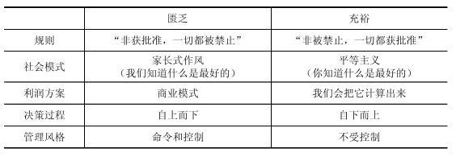

[1] 同人小说，指书迷根据原作自己改写，并且把作品贴在网上的创作方式。—编者注

## 免费世界：免费世界的前沿阵地在中国和巴西，我们能从中学到什么呢？

导读

免费世界的前沿阵地在中国和巴西，它们是免费经济的现代化测试场，我们能从中学到什么呢？

香香是一位21岁的中国流行歌手，因那首俏皮的《猪之歌》而成名。她最近的一张专辑销售量接近400万。问题在于售出的几乎所有CD均为盗版。更确切地说，这是她所属经纪公司的问题。她觉得这并没有什么不好的。至少就她而言，如果歌迷们必须全价购买专辑，那么她可能就不会拥有400万歌迷。

盗版是她的最佳市场推广商。

“在中国你什么时候对音乐下载收费，什么时候你就砍掉了99%的听众。”盗版并未摧毁市场—它为中产阶层消费者引领的一股新消费潮流准备好了市场。

免费世界新的大陆架，建立在开源代码基础上，其中巴西占据世界领先位置。在政府开展的“数字包容”项目中，Linux是首选操作系统。

在免费世界，中国、巴西和美国，谁比谁更现代化？

我正在中国广州参加一场盛宴，坐在前排观看精彩节目。我们已经欣赏了扣人心弦的杂技、出神入化的中国功夫、引人入胜的舞蹈和令人捧腹的喜剧表演。现在轮到真正的大明星，来自台湾的流行音乐巨星蔡依林出场了。在她演唱那几首最为人熟知的代表作时，现场的观众报以热情的喝彩，她那华丽的晚礼服在灯光照射下闪闪发光，她那俏丽的面孔也被放大显示在背后巨大的幕墙上。

然而这并不是一场演唱会。这是一场由中国移动员工和合作伙伴共同参加的销售推介会。我们已经进行了为期一天的电信业务演讲，只是依照惯例以一场时尚秀收场。而对蔡小姐而言，也许她从这场表演中得到的出场费远高于她全年CD的销售收入。

每年中国国内都会举行反盗版行动，也会向某些规模较大的经营盗版产品的Web网站征缴罚款，但这并未阻止普通的中国音乐消费者从各种途径免费获得几乎一切想听的东西。

新生代中国音乐人正在接受这一现实而不是主动出击反盗版。盗版是零成本市场营销的一种方式，它将这些音乐人的作品推销给尽可能最多的听众。这就最大限度地提升了他们的知名度（至少在短期内可以提高任何一位中国流行音乐歌星的人气），而且还可以指望他们把人气转化为钞票。

香香是一位21岁的中国流行歌手，因那首俏皮的《猪之歌》而远近闻名。她最近的一张专辑销售量接近400万。问题在于售出的几乎所有CD均为盗版。更确切地说，这是她所属经纪公司的问题。她觉得这并没有什么不好的，至少就她而言，如果歌迷们必须全价购买专辑，那么她可能就不会拥有400万歌迷。她喜欢歌迷们对新专辑给出的反馈和赞扬，她也喜欢现场签售赚来的大把钞票，所有这一切都因专辑盗版产生的人气而成为可能。此后她计划于2009年夏在14个城市举行巡回演唱会。可以说，盗版是她的最佳市场推广商。

盗版音像制品的销量约占中国国内同类产品销量的95%，这已迫使唱片公司开始全盘重新思考它们所处行业的情况。由于它们无法从塑料音乐磁盘的销售中获利，便开始用另一种方式对其进行包装。它们要求歌手们为广播剧录制单曲而不是像以往那样面向消费者制作专辑。它们充当了歌手们的个人才艺经纪公司，从歌手录制商业和广播预告节目的片酬中分成。即便在经纪公司的斡旋下，广告商愿意为演唱会提供赞助，这些经纪公司也极尽舞台包装之能事，以便最大限度地从赞助商处捞得回报。主要问题在于歌手们抱怨这些无休止的巡演，巡演为他们带来的只有微薄收入，却给他们的声带带来了巨大痛苦。

“中国将成为世界音乐行业的一个范本。”沈黎辉预言道，他创办了摩登天空（Modern Sky）—更具创新性的中国新音乐独立唱片公司。该公司出品的CD很少赚钱，因为其中流行的专辑很快就遭盗版。但公司找到了其他赚钱的门路，即制作视频而且目前在网站推出的视频数量日益增多。而且它还主办了一个为期三天的音乐节，吸引全国各地的乐迷前来参加。票房是收入的一部分，而公司赞助商是现金的主要来源，这些“大头”中不乏摩托罗拉、李维斯、迪赛及其他知名公司。

这并不是说你没法在这样的市场卖唱片—完全可以，只要歌曲长度少于20秒。铃声和回铃音市场巨大：中国移动（中国境内最大的电信运营商）2007年报告的音乐业务收益超过10亿美元。当然大部分收益由中国移动掌握，但剩下的也是实实在在的现钞。

艾德·派图这位旅居北京的英国人正试图找到另一种方法将音乐转化为一项生意。他的MicroMu公司签约刚出道的独立艺术家，并联系各大品牌赞助商以按月付费的形式赞助整个公司的运营。对一个西方唱片厂商而言，它的工作方式听起来也许莫名其妙，但对中国的作品市场推广商而言，这一运作模式堪称绝妙。在这个等式中，后者才是真正买单的客户。

MicroMu 尽量以低廉的成本为艺术家录制作品，要么在有赞助商赞助的表演中在观众面前进行现场录制，要么在租金便宜的录音室或排练厅里录制。他们将与这些录制过程相关的一切都拍成电影并制作出一系列带有厂商标记的视频内容。可以从MicroMu网页的一篇博文中找到录制的每一段内容，配有免费下载MP3单曲、全辑、参与人名单、作品等等的链接。而且公司还定期主办现场表演，包括在大学校园中的巡演。

牛仔裤和饮料等品牌赞助MicroMu，而非直接赞助艺术家个人（以免有损他们的独立制作人声誉）。根据他们的音乐在网站的下载次数，各位艺术家分享一定比例的赞助费。

“在中国你什么时候对音乐下载收费，什么时候就砍掉了99%的听众。”派图说道，“对于中国的中产阶层而言，音乐是种奢侈品，属于不当支出。我们创造的这种模式则与之相对应。我们只是将免费音乐和媒体作为表达‘欢迎诸位’的方式，与乐迷们进行对话，构筑一个共同体，成为中国草根音乐运动中值得信赖的一个品牌。然而，为了实现这些目标，我们必须变得八面玲珑—唱片厂商、在线社区、现场演唱会主办方、商品零售商、电视制作公司。”

与中国的情况相似，世界其他地方亦是如此。2008年美国的唱片销量再次下降了近10个百分点，且远未触底。当众多厂商完全接受和复制中国模式时，触底的时刻也许就到了。其时允许音乐免费下载变成了一干天才的市场营销手段，各大厂商以非传统方式实现了这些音乐天才们的市场价值，比如签售、赞助。这一点已初见端倪：罗比·威廉姆斯与百代公司间的合作就基于对他的全部收益的分成，包括巡演和唱片销售收入。各大艺人经纪公司，如创新艺人经纪公司（CAA）和国际创意管理公司（ICM）正考虑转型为音乐厂商，省去中间人。在如今这个音乐产业的定义发生着日新月异变化的世界，始终不变的是音乐总会造就名人。与将名声转化为金钱所面临的挑战相比，还有更难应付的问题。

### 香奈儿赝品经济

盗版并未止于电影、软件和音乐。从深圳刚下火车你就会发现冒牌劳力士手表、香奈儿香水和古奇包，以及数不清的仿制玩具和小玩意。当然，就像街角摊贩兜售的盗版CD，这些东西并不是免费的，它们只是非常便宜，而且原创者并未从这些销售额中拿到一分钱的回报。知识产权是免费的，你只需为这些具体的商品买单。但和音乐市场面临的情况相似，这一领域盗版行为的根源和后果较显露出来的情形更为微妙。

实际上盗版已蔓延到各行各业。如今，存在一个迅速克隆设计师作品的完整产业链：各大工厂可以用软件将时装周模特们的照片从网站上拷贝下来，并在几个月之内制作出与设计师作品相似的仿制品，这就经常造成原版正品滞销。

是否买个冒牌路易斯·威登的包这一决定不涉及道德评判，只关乎产品质量、社会地位和风险的化解。如果人们手中有钱，他们宁愿买正品，因为通常情况下正品质量更可靠，但大多数人只能买得起冒牌货。

就像各大粤语流行音乐下载网站，尽管它们销售情况日渐惨淡，却声名鹊起，盗版产品不仅利用他人的设计作品赚钱，而且也成为了这些设计作品的零成本品牌推广形式。一个冒牌古奇包仍自称“古奇”，而且处处皆是。这就产生了混合结果：负面的“替换效应”（盗版产品夺走了由正版开发的客户需求）与积极的“刺激效应”（盗版产品创造在别处能发挥作用的品牌知名度）相结合。

2007年，中国市场调查集团在中国大城市消费者（主要是年轻女性消费者）中开展了调查。调查中发现了一种非常实用的盗版仿冒方法。这些消费者明白原装正品与盗版产品间存在的差别，且如果价格能负担得起更倾向于选择正品。有时他们会买一件正品，而后其他全部用仿冒品。

研究人员肖恩·雷恩报告指出，一些月薪400美元的年轻女性自称她们愿意省出三个月的薪水去买一个价值千元的古奇手包或一双巴利（Bally）女鞋。一位23岁的受访女士说：“目前我没钱去买那么多正牌普拉达（Prada）或寇驰（Coach），所以我买冒牌货。我希望将来我能买得起正品，但现在我想要打扮起来像那么回事儿”。

“像那么回事儿”并非总是意味着购买令人信服的冒牌货，它创造出了一个冒牌“证据”市场，这个市场中的产品并不是冒牌货。（你从中也能找到创新之处。）你可以买回“高价”价签将它们贴到“低价”衣服上（看到有人戴着还贴有价签的太阳镜这很正常）。而且，还存在一个创造冒牌收入的二级市场。产品是一回事，而附加在产品之上的身份或地位则显得更加重要。

在一家跨国公司上班的一位27岁女士承认她确实买过冒牌货，但她说：“如果你穿太多冒牌衣服或用太多仿名牌手包，你的朋友就会知道，所以你并不能愚弄任何人。最好还是用正牌货。”

这突出了数码产品和实物商品间的差别。盗版的数字产品与正品质量相差无几，但通常情况下冒牌实物产品却与正品差别巨大。经历了多年低劣有时甚至含有有毒物质的国内假冒儿童和宠物食品丑闻后，中国消费者高度警惕在灰色经济中与购物相关的风险。

赴香港旅游以购买正版奢侈品的大批消费者，便是内地普遍存在的对设计师作品进行剽窃仿制等违法行为所产生效应的明证：消费者非常关注西方世界的奢侈品牌，他们将这些奢侈品与风格和品质联系在一起，而且在能负担得起时他们热切希望能买到真品。随着国内经济发展，他们的购买能力也越来越强。

盗版并未摧毁市场—它为中产阶层消费者引领的一股新消费潮流准备好了市场。过去10年间，中国人均收入已经增长了一倍多，从1996年的633美元到2007年的1537美元，且在这一过程中并未显现出增速放缓的迹象。中国约有25万百万富翁，而且这一数字与日俱增。如今，中国已成为世界上合法奢侈品消费的第三大市场。就经济效益而言，相比其满足的消费需求，盗版或仿制行为刺激了更多的市场需求。

冒牌货实际上对正品特别是时尚圈的正品有益这一观点并无新意。在经济学中，这一观点被称为“盗版悖论”，由法律教授卡尔·劳斯蒂亚和克里斯托弗·斯普里格曼首创。

悖论源自支撑时尚经济学的一种基本两难困境：消费者喜欢当年的设计风格，但很快也会对它们感到不满意，因此他们会“移情别恋”到下一年的设计作品。例如，与高科技企业有所不同，服装公司不能辩称下一年的设计模板表现力更出色—它们只是看起来有所不同。因此它们需要另找理由使消费者不再迷恋于今年的设计风格。解决方案就是：将一种专有设计方案转化成某一大众市场商品广泛复制。设计师作品的神秘性被满大街廉价的复制品暴露无遗，而有辨别能力的消费者不得不继续寻找独具一格且款式新颖的服饰。

这就是劳斯蒂亚和克里斯托弗所说的“诱导性过时”。复制使得时尚很快就从其最初的创造者延伸到社会大众，迫使最初的创造者采用更新的设计理念。在中国，最初的创造者是新兴的富人阶层和中产阶层，而更多普通大众可以借助做工精巧的赝品在奢侈品市场中分一杯羹。两种商品—真品和冒牌货—针对的市场区域各不相同，但二者相辅相成，而且这种情况不仅在中国出现。

### 巴西街头商贩们的威力

在巴西圣保罗市喧闹的街角，商贩们在兜售着最新的“Tecnobrega”CD，包括当红乐队“Banda Calypso”的一张专辑。“Brega”大体上意指“低劣”、“粗俗”，而来自帕拉州北部贫民区的这种音乐表达着桀骜群体的声音，它是由机械式节拍演奏出的土著巴西音乐。就像街头摊贩们兜售的CD，这些音乐并非出自大厂商的官方作品，但它们也非法律禁止的音乐。

这些CD出自当地录音棚，而这些录音棚大多由当地DJ经营。他们从乐队手中拿到母带及附带宣传海报，与当地聚会策划人、街头摊贩及广播站合作为即将开始的巡演造势。有时当地DJ们实际上集这些角色于一身，为他们自己组织的巡演制作、销售和推广CD。

Banda Calypso并不介意自身并未从中赢利，因为出售光盘并非Calypso的主要收入来源。乐队做的其实是演出生意—这生意做得很好。借助在各个城镇间开展的巡演，外加巨便宜CD掀起的一股抢购风，Banda Calypso一年可以举办数百场演出。该乐队每周大概演出两到三场，坐着面包车或划着船在村镇间穿梭。

但并非只有陆地和水上旅行，人类学家及巴西音乐学者赫尔曼为我们讲述了Banda Calypso的一则故事，以阐明他们的成功之道。在为这支乐队的Globo TV音乐秀做策划时，赫尔曼提供了Globo拥有的一架飞机以搭载乐队在偏远地区间往返。Calypso作何反应？压根儿用不着，我们有自己的飞机。

某种意义上，街头商贩们已经变成了Calypso造访各个城镇的先头部队。他们通过兜售乐队CD赚钱，这些CD在他们手中仅卖0.75美元，而且他们会在巡演中演奏CD上的曲目。没有人认为商贩们手中廉价的CD属盗版碟。这只是市场营销的手段而已，利用街头经济创造直观的街头信誉。因此，每当Banda Calypso乐队来到镇上时，每个人都会知道。乐队吸引了大批拥趸参加他们的“立体声版”演唱会，现场不仅收门票而且提供付费饮料和食品。乐队成员还对演出进行录像并现场烧制CD和DVD，然后以大概2美元的价格出售，这样音乐会的常客就能随时重放他们看过的表演。

Banda Calypso乐队的CD已卖出超过千万张，大部分不是他们自己出售的。当然，不单他们一家乐队如此。“Tecnobrega”这一行目前包括了数百只乐队和每年数千场演出。罗纳德·雷蒙斯和他的同事们在位于里约热内卢巴西商业学校的科技和社会研究中心开展的一项研究发现，演出和音乐，这一行业每年创收约2000万美元。

90%的乐队既没签约也没自己的厂商。它们不需要这些。允许乐迷们免费欣赏他们的音乐这一做法本身就创造了一个经济回报远胜过唱片销售所得的产业。较其他大多数事物而言，这才是巴西对此理解和把握得更好之处—2008年前该国文化部部长吉尔伯特·吉尔一直在一个免费的知识共享协议之下发布自己的音乐。

与中国相似，在巴西向免费迈进的动力远不只在音乐领域。1996年，作为对巴西惊人的艾滋病感染率的回应，时任总统费尔南多·卡多佐领导的政府保证向全国所有HIV携带者分发新研制的“鸡尾酒”疗法药品。5年之后，随着艾滋病发病率的下降，这一方案的明智之处得以显现，但就为“鸡尾酒”中含有的专利药物支付昂贵药费所需的成本而言，这一做法又是完全难以为继的。

因此巴西卫生部部长找到了这一重要专利的持有人—美国制药巨头默克公司和瑞士罗氏公司，要求它们给予一定程度的优惠。当两家公司拒绝这一请求时，卫生部部长赛拉提高了谈判筹码。他通知对方，根据巴西法律，他有权在国家紧急情况下许可当地实验室生产专利药物，免征专利权税，而且必要情况下他将动用这一权力。公司最终让步了，而且价格下降幅度超过了50%。如今，巴西拥有世界上最大的非专利药产业。不仅免费，而且免征专利权税，这就是这一行业与Tecnobrega的DJ们分享获得知识产权的方式。

之后是开放源代码领域，其中巴西占据世界领先位置。该国建立了世界上首个基于Linux的ATM网络。联邦信息技术研究院的重要指令就是在政府及全国范围内推进免费软件的采用。政府各部门和学校在其办公领域推广开放源系统。而且在政府开展的“数字包含”项目中（该项目旨在使80%尚未接触过计算机的巴西人接触这一高科技产品），Linux是首选操作系统。

“在巴西获得一套Office加Windows软件许可证—这个国家还有2200万人在挨饿—意味着必须出口60麻袋大豆。”巴西免费软件项目协调官马塞洛·伊利亚·布兰克告诉作家茱莉娅·迪拜尔。在他看来，免费软件不仅给消费者带来实惠，而且有益于整个国家。

## 想象充裕：“后匮乏”社会的思维实验，从科幻到宗教

导读

从单调乏味的物质世界，到丰富多彩的精神世界，我们由匮乏进入充裕。

天堂是人们对充裕和富足的终极设想：天使们在鹅绒般的云层里拍着翅膀，弹奏竖琴，超越了所有的物质需求。那些虔诚赴死的人死后变得圣洁、光辉和完美。身体曾经承受的各种自然缺陷被统统抹去。

如果我们得到了我们一直苦苦寻找的东西，我们很快就会对其漠然处之，而后发现一种新的可供追求的匮乏事物。我们始终被自己不曾拥有的而非已经拥有的事物激励着。

这就是为何30岁以下的读者谈及接近零边际成本的互联网经济收益时，他们总是认为“那当然”。在传统观念里，如此廉价的数字产品被视为几乎难以想象的“聚宝盆”。但在新范式中，这可以说根本不值得计算在内。充裕始终是前面一座闪烁着耀眼光芒的山巅，却从来不是在我们脚下的这座山。从经济学角度看，充裕是创新和增长的推进器。但从心理学角度看，匮乏才是我们真正理解的一切。

数字时代的到来以及互联网的普及为科幻小说提供了有关充裕的更具说服力的源泉：让自己置身于虚拟世界（Metaverse）之中吧，你能变成你想要成为的任何人；匮乏仅仅是虚拟现实的一种构造物，而且如果你能对付得了它，你就能得到你想要的一切。当代作家对充裕抱以更为积极的态度，因为他们已经在体验享受充裕的美妙感觉—互联网使信息的匮乏一去不返。

所有的科幻小说作者都知道这条不成文的法则：在每个故事中，你只能打破一到两次物理学定律。毕竟，自然界和人类社会的规律一贯有效。因此你可以进行时间旅行，拍一部《黑客帝国》，或者把我们放到火星上。除此之外，在波澜不惊的日子里我们还是平头百姓。科幻小说之所以引人入胜，就在于它揭示了人类对这种大错位会作何反应。

科幻小说在作家克莱夫·汤普森看来就是“哲理类作品的最后堡垒”。汤普森指出，它是对现实生活的一种模拟，在模拟过程中我们改变了某些基本规则而后对自身有了更为深入的了解。“如果我们能活到500岁，爱将如何改变？如果你能及时回到过去推翻原来的决定，你会这么做吗？如果你能遇到这种情况，能与过去的人进行交谈，或者能杀死神灵，又会怎样呢？”

科幻小说作者们反复讨论的一个话题就是发明某种能够使匮乏之物变得充裕的机器。例如《星际迷航》（Star Trek）中的物质复制机（只需按一下按钮，任何想要的实体物都将立刻出现在你面前），还有出现在《机器人总动员》（WALL-E）中机器人驾驭的太空飞行（人类变得肥胖而笨拙，他们斜倚在漂浮着的水上躺椅上打发时间，饮料就放在手边）里的情形。

在科幻界（以及对更为边缘化的技术乌托邦而言），这就是所谓的“后匮乏经济学”（post-scarcity economics）。在这种背景下，很多科幻作品不仅在讲故事，在这一过程中它们也在进行贵重物品几乎变成免费品所引发后果的思维实验。

以E·M·福斯特1909年出版的短篇小说《机器休止》（The Machine Stops）为例。这部科幻小说的早期代表作为读者呈现出一个人类撤回到地下的世界，他们生活在单独的狭小空间里，所有的面对面接触和互动都不存在。一台巨型机器为所有的生命提供服务，确保饮食、娱乐等人类社会基本活动顺利进行并使人类免遭地球表面有毒物质的侵害，就像个体形庞大的“机械上帝”。确实，小说中的人最终都渐渐开始对这个庞然大物顶礼膜拜。那么这是为什么呢？在相互分隔开的房间里，所有的人类需求都得到关照：到处都有按钮和开关—按钮用来呼叫食物、音乐和衣物。有一个洗热水澡的按钮，一按这个按钮，一个（仿造的）大理石浴盆就从地板下升了上来，盛满了一大盆暖暖的洗澡水。还有一个冷水浴按钮。除此之外还有编写文学作品的按钮。当然她（瓦实提，小说中的主要人物）与朋友们进行交流用的按钮也已准备妥当。

瓦提实没有工作或者目标，除了通过即时视频通信设备为她的朋友们开讲座。对于如今20～30岁的年轻父母而言，我相信这听起来并不陌生。

现在因为机器使你拥有了充裕。那么情况又如何呢？并不是特别好。因为机器取代了人与人之间的互动，人们丢掉了进行面对面交流的能力，而且开始对彼此见面感到恐惧。依靠这台机器的人认为所有信息在收集过程中都应当经过三手、四手甚至更多手的中转，以免除信息接收者的直接体验。不幸的是，避免互动就意味着终结了所有共同开展的创造性活动，而社会的进步也就此停止。人类失去了自身的使命感，甚至将艺术和文学创作都交给机器去完成。

最终当机器渐渐停止运转时，没有人知道如何将它修复。因此随着机器崩溃，地球上依靠机器的多数人一同死去，剩下的在底下拥挤不堪的藏身之处苟延残喘。然而，在小说的结尾，其中一位主人公在奄奄一息时透露，他已经发现了一个仍生活于地球表面的由被放逐者组成的社会，他们得以免遭充裕的毒害。喔！20世纪初的其他科幻小说也是同样黯淡的基调。工业革命引发的混乱仍在持续，而且机械化、城市化和全球化带来的剧烈变革令人深感不安。机器创造的充裕只属于少数特权阶层，这些实业家是真正的受惠者，而其他人只能在其开办的工厂中辛苦劳作。

在佛列·朗执导的科幻电影《大都会》（Metropolis）中，人类社会被划分成两类：一类是居地面之上生活奢华的设计师和思想者，而另一类则是在地下居住和讨生活的工人，他们奔波劳作以开动维持富人奢侈生活的机器。这部电影讲述的是工人的反抗，但更宽泛的意图指向非常明显—付出一定代价才能换来充裕，而代价就是别处的匮乏。

两次世界大战几乎浇灭了科幻乌托邦主义的热情，但太空时代的到来又让它复活，而这一次前景不像原来那么黯淡。正如前面提到的那些科幻小说，亚瑟·克拉克1956年创作的《城市和星星》（City and the Stars）一书中开篇就提到了一个与世隔绝的密闭“技术城市”，在这个城市里各种机器为人们提供所需的一切物品而且没有人死亡。市民们在哲学讨论中度日，进行艺术创作并参加虚拟现实探险。几千年之后，他们返回到“万物神殿”将他们的意识再一次数字化。克拉克将这一场景描绘得如同田园诗般美妙动人，却让人感到生活在其中略显乏味。他笔下的主人公决定冒险到周围的沙漠里转一转，看看那儿是否有更多值得探索的东西，最终他发现了一个更像我们所处社会的世界，在那里生老病死的自然循环为生命赋予了鲜活的意义。

数字时代的到来以及互联网的普及为科幻小说提供了有关充裕的更具说服力的源泉：让自己置身于虚拟世界之中吧，你能变成你想要成为的任何人；匮乏仅仅是虚拟现实的一种构造物，而且如果你能对付得了它，你就能得到你想要的一切。当代作家对充裕抱以更为积极的态度，因为他们已经在体验享受充裕的美妙感觉—互联网使信息的匮乏一去不返。

当然情节要更为紧张，因此在这些有关充裕的科幻小说中一切并不是按部就班进行的。在考瑞·多克特罗的小说《魔法王国历险记》（Down and Out in the Magic Kingdom）中，Bitchun 社会控制的某种未进行描述的科技“几乎令医生这一职业荒废：当你能够进行克隆，获得身体某部位的备份且因新生的身体而重新恢复活力时，为何还要为外科手术烦心？一些人甚至可以交换器官以避免感冒”。然而，结果却是人们变得烦闷且冷漠。书中一位人物解释道：“吸毒者并非失去了理智，只是因为他们忘记了一切都是多么尖锐，忘记了痛苦如何使快乐变得更为甜蜜。我们无法记住拼命工作以挣钱糊口是怎样一种感觉，担心挣的钱还不足以维持生计是怎样一种感觉，担心可能会得病或被公共汽车撞倒是怎样一种感觉。”

在多克特罗笔下的世界里，名誉或者说“喝彩”承担着着数字货币的功用，可以用其与他人交换善行，它也会因你的劣迹而减少。平面显示器展示着每个人获得的“喝彩”，这成为衡量身份的一种标准。当所有物质需求都得到满足时，最值钱的商品就变成了社会资本。

在尼尔·斯蒂芬森的《钻石年代》（The Diamond Age or， A Young Lady's Illustrated Primer）中，充裕来自纳米技术驱动的“物质编码器”，它能够制造各种东西—从气垫到食物，无所不包。唯一需要人类动手做的就是设计出交由编码器制作的新东西，而且这也不需要很多人去做。20亿工人无所事事。这部小说描述了一个人为发明一种教育众人的方法而付出的努力（图解绘本）。这与第一次工业革命时期作家们笔下与之颇为相似的一个主题相呼应—当机器包揽了所有工作，我们继续前进的动力何在？

在某些作品里，劳动力的富余解放了人们的思想，终结了人类对资源的争夺，且创造出一种作为精神、哲学存在的文化。换句话说，匮乏的终结使我们变得懒惰、颓废、愚蠢和卑鄙。

### 未来

除了在宗教中可以发现一二，其他领域也许没有充裕/匮乏引发的极端现象更为显著的例子。

天堂是人们对充裕和富足的终极设想：天使们在鹅绒般的云层里挥着翅膀，弹奏竖琴，超越了所有的物质需求。那些虔诚赴死的人死后变得圣洁、光辉和完美。身体曾经承受的各种自然缺陷被统统抹去。还有一些更为清晰的描述：天堂的居住者年龄和身材都完全相同；他们穿着昂贵的罩衫，戴着手镯，抹着香水，躺在镶满金银或名贵珠宝的床上；他们参加高雅的聚会，由长生不老的仆人端着银盘服侍左右；食物包括既不会致醉更不会引发祸端的清澈美酒。

乔治·奥威尔曾不无讽刺地描绘了这一版本的富足天堂。在他的《动物庄园》一书中，家畜被告之在它们悲惨命运结束之后，它们将去往天堂，那里“一周7天全是礼拜天，一年四季都有鲜美的苜蓿可供享用，而且块糖和亚麻仁饼就长在树篱上”。

但《纽约客》杂志用几幅漫画就揭示了如果我们太把天堂的富足神话当回事儿，那么我们很快就能想象出整天待在那儿会多么无聊。罩袍、竖琴，每天都像在经受临终祷告。这就无怪乎科幻小说中的充裕很快导致人生目标的彻底丢失和《机器人总动员》中人类惰性的膨胀。匮乏的终结同时意味着纪律和动力的终结？

为了找到上述问题的答案，有必要看一看雅典文明与斯巴达文明的历史对比。在大批奴隶人口的支撑下，这两个古典城邦均处于国力无比充裕的时期。奴隶们提供所有的物质生活必需品，与机器或Bitchun社会颇为相似。如果你足够幸运地出身于“正确”的阶级，你甚至不用为生存而工作。

上述两个社会没有一个发现自己因缺乏目的性而陷入困顿或停滞不前状态中。雅典人成为了艺术家和哲学家，努力探寻着抽象世界的意义，而斯巴达人则穷首于对军事力量和权力的追求。物质方面的富足创造了一种意味深远的匮乏，并没有夺去生活的意义。雅典人沿着马斯洛“需求层次”金字塔拾阶而上，探索伟大的科学和创造力。而斯巴达人渴求战争？我想马斯洛也会将它称之为自我实现的一种形式。

从科幻中得到的经验教训就是实际上我们并不能想象出充裕和富足的恰当形态。我们的大脑已习惯于进行匮乏思维。我们关注那些我们并非充分享有的事物，从时间到金钱。这就是我们前进的动力之源。如果我们得到了我们一直苦苦寻找的东西，我们很快就会对其漠然处之，而后发现一种新的可供追求的匮乏事物。我们始终被自己不曾拥有的而非已经拥有的事物激励着。

这就是为何30岁以下的读者谈及接近零边际成本的互联网经济收益时，他们总是想当然。在传统观念里，如此廉价的数字产品被视为几乎难以想象的“聚宝盆”。但在新范式中，这可以说根本不值得计算。充裕始终是前面闪烁着耀眼光芒的山峰，从来不会是我们脚下这座山。从经济学角度看，充裕是创新和增长的推进器。但从心理学角度看，匮乏才是我们真正理解的一切。

在本章的讨论行将告一段路时，我想列举英国什罗普郡这个工业革命发源地的一个例子。1770年，当地炼铁厂已经具备了冶铸大截面铁器的能力。为了展示这一耐用新式建筑材料的优势，工厂主请工程师们建造一座完全由铁做原材料的桥。横跨塞文河的“铁桥”如今仍然吸引着游人的目光，不仅因为这座桥建造者的雄心及其令人惊异的构思，而且因为它在建设过程中完全遵循了木结构桥的建筑原理。

铁桥主体的各部分是单独进行浇铸的，而将各组成部分连接起来的是与木制工艺中使用的楔子如榫眼、榫头和隐鸠尾榫斜接类似的扣件。拱顶的半肋拱由螺栓固定。上千块铁板被固定在一起，就像它们都是用木头做的。结果，这座桥的设计规格远远超出了安全标准规定的范围，没出几年，在重达380吨的铁质桥身重压下，桥的钻石结构开始出现裂缝。

又过了很多年人们才意识到铁有许多不同的功用。铁没有木头在长度和辐射半径方面的弱点，铁桥可以设计更长的桥拱而且可以对其进行焊接，当然后来铁桥的重量不到之前所建铁桥重量的一半。

## “一分钱一分货”：对免费的其他疑问

导读

作者批驳了14种最常见的对基于免费的经济观念的异议：

1.世上没有免费午餐

2.免费背后总存在隐性成本/免费是个把戏

3.互联网并非真正免费，因为你要为接入服务付费

4.只有广告是免费的（而且是有限的）

5.免费意味着更多的广告，也意味着更少的隐私

6.没有成本，没有价值

7.免费削弱创新

8.枯竭的海洋、肮脏的公厕和全球变暖都是免费的真正代价

9.免费鼓励盗版

10.免费正哺育着“目空一切”的一代

11.你无法与“免费”进行竞争

12.我将自己的资产尽数赠送而且并没有赚多少钱

13.如果另有人买单，那么“免费”就再好不过了

14.免费驱逐专业人士而青睐业余爱好者，付出的代价就是质量

2007年末，《纽约时报》社论版编辑安德鲁·罗森塔尔就《纽约时报》做出的取消之前为专栏作家保留的“时报精选”付费专栏，从而在线免费开放其全部内容的决定接受了《雷达》杂志采访。

他是这么说的：

我认为报界正一起为一个不明确的理由纵身跳下悬崖—当我们向全世界宣布免费的这个决定时。而且从一开始我们就应当一致对我们的网站收费，这应该是网站经营的一部分。

你必须付钱买报纸。你必须付钱搞网络发行。这些都需要钱。我认为免费是个巨大的错误，但对此现在我也无能为力。如果你看一眼互联网，唯一一件免费的东西就是我们创造的—信息，其他的一切都要钱。定制回铃音须付费1美元，接入互联网须付费，发送电子邮件须付费。所有人都说电子邮件是免费的。其实不然，你要向你的互联网服务提供商（ISP）付费。如果你使用类似Google邮件这样的服务，你其实正在把自己变成一家大公司的一条广告渠道。互联网上没有免费的服务，那全是瞎扯。

撇开罗森塔尔逻辑中某些明显的问题（如果对公司广告渠道的认识出了问题，那么可以断定他选错了公司），他的话确实触及到了某些重要主题。最初我引用他的言论是因为我能想象到当很多人初次读到他的观点时会表示赞同（而且在这儿再次读到时会再次点头称赞）。他也做出了一些我每天都能听到的假设—“一分钱一分货”，“你必须为网络发行买单”，互联网上没有免费的午餐，“因为你一直都在向ISP支付互联网接入服务费”，互联网上唯一免费的东西就是“信息”。

这些说法都有一定道理，但这种思维模式却是错误的—差不多属于那种特别令人挠头的错误。每天我都能听到许多这种对免费的质疑，而这些质疑显然构想拙劣（除通常贴着“支持免费”标签外，我还发现它们非常滑稽可笑，即便我知道自己不应该这么认为）。因此，接下来我将介绍14种最常见的对基于免费的经济观念的异议，每一种附加一个例子，以及我的观点。

### 世上没有免费午餐

你，我/心知肚明/握着我的手/最后一次机会，小鬼/难道它还不够奢华/这可是场交易，是一次偷窃/三十个银币/一言为定/在这儿签上名/我将归你而你将归我/没有什么是免费的/最终/没有什么是免费的

——《没有什么是免费的》埃利斯·库珀

上面这段话所反映的是经济学世界的“TANSTAFL” <sup>[1]</sup> ，是米尔顿·弗雷德曼—这位前芝加哥大学经济学教授、赫赫有名的诺贝尔奖获得者的经典言论。它简单明白地表明一个人或一个社会不可能白占便宜而有所收获。即使某些东西看似免费，但对于个人或作为一个整体的社会而言总是存在一定成本，这种成本也许被隐藏了起来或被分散了。

这始终是正确的吗？这实际上牵涉两个问题，一个是经济学问题，一个是实际操作问题。理论上，我们认为在某些地方某人必须付钱，对吗？对于我们自己也是如此，不是吗？

对第一个问题可以简单回答“是的”。最终某人必须支付所有费用。然而，正在发生变化的是这些成本或费用正从大部分为“隐性”支付（你必须为那顿午餐消费的啤酒买单）转变为“分布式”支付（某人在付款，但可能不是你；确实，成本也许被广泛地分摊开来以致我们个人根本没有感觉到）。

经济学家总是在“封闭型市场”中考察这一规律，例如提供那顿午餐的饭店的资产负债表。如果你没有结账，与你一起共进午餐的伙伴一定得买单。而如果她不付钱，那么饭店经营者就得为你们买单。如果饭店经营者也不付钱，食品供应商就得付。依此类推。不管怎样，从账目上看必须是收支平衡。

但这个世界有很多市场并不属于“封闭型”的，而且它们在向周围的市场渗透。我们可以对其中一些进行测量，另外一些则无法测量。我们已经看到货币市场与非货币市场间的互动。在货币市场中对你而言午餐也许是免费的，但你在注意力和声誉市场中“付出”了自己的时间和形象。这些就是所谓的外部因素，也是经济学家处理不符合标准模型情况的方式。这些外部因素之一便是“机会成本”——你将花在午餐上的时间用来做其他事情创造的价值。

如果我们能在所有可能存在的市场—货币市场和非货币市场中权衡利弊，并且计算出合适的转化率，那么无疑弗里德曼是正确的。但是我们无法做到这一点，因此我们能够从理论上计算你刚才喘口气所分摊的生态成本，但实际上它是免费的。

经济学（至少以其理想化形式看）遵循守恒定律，即有进有出。举个例子，如果你发行一定数额的货币，依据标准货币理论在你印发更多货币后，之前同等数额的货币就贬值了。

然而，实际上，经济学被称为一门“枯燥的科学”不无道理—就像研究人类行为的其他学科，它令人感到模糊不清。在经济学体系中无法直接衡量的事物被一律划归为“外部因素”（例如，当你购买一双鞋时，你并没有为在这双鞋制造过程中释放的碳对环境造成的影响支付任何费用，而对环境的影响就是所谓的“负面外部因素”，我们将在后面对此进行详细讨论）。从学术上讲，免费午餐中的很多成本都可归入外部因素类别中，但对你而言这无关紧要。

为了证明这一点，让我们试着跟踪一下为浏览一次维基百科所支付费用的去向。维基基金会为运营维基百科所租借的服务器和带宽支付费用，它是由法人和个人等捐助者赞助的非营利性组织。假设你并非个人捐助者（只有很少一部分维基用户属于个人捐助者），而是某一维基法人捐助者的客户，例如太阳微系统公司。在这种情况下，你可能愿意为太阳微系统公司（而不是其他公司）服务器的租用费支付更多的钱，从而增加太阳微系统公司的净利润，使其能够为维基慷慨解囊。如果不是太阳微系统公司的客户呢？没关系，Google公司也是维基的捐助者。也许你为一份天价Google公司广告支付的费用远比在Google不捐助维基的情况下支付的广告费高出许多。如果你不是一位广告商呢？那也没问题，也许你曾经从Google的广告商那儿买过产品，而由于这一系列连锁反应，该产品的“身价”将暴涨至其最初价格的数倍。

在这一点上，我们正在讨论“一分”钱的若干份额，也可以说是在讨论一美分的若干份。换句话说，尽管你可以说你最终还是为浏览维基付了钱，但这只在下面这层意义上是正确的，即远在中国的一只蝴蝶扇动一下翅膀就能影响你所在地方明天的天气。从理论上讲，这其中存在某种联系，但这种联系过于细微以致无法测量，因此我们也就不必为此费神了。

现在让我们重新回顾一下罗森塔尔那学究般的评论——“你不得不为网络发行买单”。是的，从技术角度看这无疑是正确的，但作为一家既做平面出版业务又做电子出版业务的媒体编辑，我知道这二者的区别远大于相似之处。我们需花大笔钱印刷、装订并把杂志邮递到你手上（这并不包括内容采写编辑方面的任何成本），但只需拿出很少一部分资金运营网上杂志。这就是我们能够将其视为免费的原因，因为事实上，在每个用户的基础上，这一成本过于微小以致无法计算。

整体上看，我们每月的服务器和带宽费用高达数千美元，但借此我们能够为数以千万计的读者提供服务。相比那些读者为我们创造的价值，我们更乐于免费提供电子版内容。当然，我们姑且赞同老爱唱反调者的观点：免费并非真正的免费。但在很多情况下，也可能是真的免费。这就是决定我们如何经营自己的生活和生意的最关键之处。

### 免费背后总存在隐性成本/免费是个把戏

如今的免费与往日相比已经大不相同，特别是互联网上的免费，它的历史和科技都基于这样一种观念，即在线信息和其他几乎一切东西都准备免费提供给众人。互联网接入成本的低廉正渐渐让人们付出越来越高的代价，这突出表现在计算机故障、受挫以及隐私和安全保障的丢失—更别提对大规模音乐下载进行昂贵法律诉讼的威胁。

——《纽约时报》，约翰·施瓦茨

与其说这是一种谬论不如说这是一种陈词滥调。是的，某些情况下免费确实伴有某些附加条件。广告打乱了你对版面的设计；各种限制条件被强加于你；你会收到各种你不需要的产品的促销广告，或者受困于某些并非总是免费的东西；你被引诱上钩，而后转变了原来的决定。

但这描述得更像是20世纪的而非21世纪的免费。在一般意义上，常识是一位好向导：如果某事物好得不像真的，它很可能就不是真的。百货商场里试用香水的边际成本低得足以使人们相信这些香水是免费的，但你还是会认为最终你总会以某种方式为这种免费试用买单。

然而，在21世纪的免费模式中，这种免费基于边际成本近乎零的数字信号，并没有隐性成本的需求。如施瓦茨想要提醒我们的，它们也许仍然在那儿，但这更说明了这样一个事实，即免费产品没有保证，这就是当东西坏了时不保修的成本（将其称之为买者自慎）。这一模式并未对隐性成本做出要求。免费可以像付费一样让人感到舒服，或者更舒服：没有花招，没有圈套，或者附加的各种条件（例如开源软件）。

是时候不再把数字信息当做原子对待了，假定相同的限制条件仍然适用。欺骗不再是这一模式的必要组成部分。

### 互联网并非真正免费，因为你要为接入服务付费

请问互联网什么时候真正免费过？就像言论自由一样，互联网是自由的，但使用互联网并不像免费品尝啤酒那样也是免费的。我们所有人要接入网络都必须向ISP付钱，因此可以说我们一直在为网上内容买单。

——劳里·朗汉姆发的一个帖子

这是一个令人普遍感到困惑的现象，即我们每月花在互联网接入上的30～40美元资助了整个互联网。这笔钱实际上确实有助于传输基础设施取得物质回报，但它与这一基础设施传输的内容并无干系。与此类似，使用移动电话的分钟数并不代表在这几分钟里通话内容具有的价值，你只是在为传递给你的数字信号而非这些数字信号存在的价值买单。这就是“内容”与“载体”之间的区别，二者分属不同的市场部门。载体并不免费，但内容通常是免费的。你支付的ISP月租费包含了内容递送，但内容的创造却是由一个完全不同的经济模型掌控。

很容易明白为何人们会对此感到困惑，因为也存在一些载体资助内容的市场。例如，就有线电视而言，地方有线公司要为其通过自己拥有的线路传输的大部分视频支付执照费，而这费用就出自你交给有线公司的月租。但互联网的运作模式与之不同：你的ISP并未控制其传输的数字信息，也没有为此付费。（在法律术语中，这被称为“公共承载商”，像电话公司就是如此。）

### 只有广告是免费的（而且是有限的）

在今天这个“免费”世界里，大多数在线业务领域，根本不可能开办一家小型自立公司并发展壮大。这是因为在数字世界里，广告业务（唯一真正的收入来源）无法支撑一家小型数字企业的生存和发展。如果依据人们为服务买单这一理念开展业务，那么小公司就能够在小范围业务领域中取得成功并不断成长。但当你的竞争对手采取免费策略时，你很难对自己的客户收费。

——汉克·威廉姆斯，发表于《硅巷观察家》

有关互联网上免费的最严重谬论是仅有广告是免费的。尽管基于广告业务的经营模式主导了互联网发展的初期这一说法是正确的，但如今的免费加收费模式—在这一模式下一部分客户直接付费，并支持另外许多免费享用服务的客户—正处于高速发展中，与前一模式展开竞争（如我们在第一章中所见）。例如，在线视频游戏通常采取的就是这种免费加收费策略，而它也是基于互联网的软件（被称为“作为一项服务的软件”）中发展速度最快的一类。在互联网业务规模都较小且很难指望广告业务支撑一家小企业运营方面，威廉姆斯是正确的。但认为这是在线公司可用的唯一经营模式就错了。越来越多的公司正在采取与芝加哥37signals公司类似的经营模式，即借助免费样品和试用对软件进行市场推广，取代老套的营销模式（由客户直接付费使用）。

这听起来过时了？也许，但如果选对了市场这一营销策略仍能发挥作用。戴维·汉森（37signals的创始人之一）认为该公司的成功之道不在于将客户锁定为大众用户（很难让他们掏腰包）或大公司（各大公司是众人追捧的对象，从它们那儿获得业务订单难度大而且大公司采购进程缓慢），相反，该公司的目标客户是“财富500万”的小公司，这些公司有着尚未完全满足的各种特殊需求。为20人团队开发的项目管理软件就是37signals销售的产品，而且由于深受大公司开发的“万用”软件和蹩脚开源软件之苦，这些公司乐于支付几百美元的年租使用37signals的版本。

你只需观察一下iPhone的“App 商店”（你可以将iTunes上的所有程序下载到你的手机上），就能发现上百家小企业（它们中的很多是只有几个程序员组成的小公司）通过在其他公司免费赠送软件的市场领域销售软件从而取得了可观的收益。不需要做广告—这是一种单边销售模式，或者预先为产品做广告或者为免费试用品的高级版本做广告。对于上千家仅配售在线针对性实用程序的公司而言，这么做无疑是正确的，此类应用程序提供给客户免费试用的机会。这并无新意—共享软件市场已经存在数十年了，但随着这种软件发展为基于互联网的软件，在共享软件市场推行这一经营模式就变得越来越容易了。

对“互联网上只有广告是免费的”这一论断的另一质疑在于，该观点暗示了免费是有条件的—广告业这个大蛋糕只能是这么大。尽管这也许是对的，但完全不清楚什么地方有限制，在线广告业务规模能增大多少倍。Google已经向我们展示了在线广告可以做得与众不同—可测量、有针对性且仅按照绩效付费，从而吸引一个崭新的广告商阶层—按每点击一次几美分的价格购买关键字的中小企业。Google并未抢占更多的广告市场份额，相反它创造了一个规模更大的广告业市场。

### 免费意味着更多的广告，也意味着更少的隐私

我问过许多终日与Facebook为伴的人他们会付给这家网站多少钱，而他们异口同声说零。由此看来，Facebook变成了广告业务的奴隶，并且为了赚每一分钱竭力美化用户的个人信息。认为人们会为其个人信息不免费公开的服务买单这一想法并非不切实际。

——保罗·埃利斯，pseudosavant.com网站

这是通常人们对广告业总体状况的看法。人们经常假定任何开展广告业务的网站必然会跟踪用户行为并将信息出售给广告商。这一论点支撑了下述假设，即免费力度如此之大是因为受到了广告收入的支持，所以免费是一种具有腐蚀性的力量，它将市场营销中的不当方式散布到它所在的各个领域。

事实上，Facebook的例子只是特例而非规律。大多数由广告业务作为主要收入来源的网站均规定了相应的隐私政策，禁止将用户信息泄露给广告商（而且大多数广告商不知道如何处理，即使他们得到了这些信息）。

埃利斯认为直接为服务买单而非让广告商代你支付相关费用，这将使这些网站更倾向于保护你的个人隐私—也就是说，他们为你而非广告商服务。尽管这有可能是正确的，但并不是必然的。

数十年来，媒体界已经知道如何平衡客户和广告商间的利益，从行业指导方针到将编辑职责与经营业务相分离的媒体“中国墙”。这并非新近出现的问题，而且我们已经注意到有可能实现编辑的自主权，即便在广告商支付广告费的情况下。

然而，值得注意的是隐私的含义是不断变化的。在欧洲，庞大的法律系统保护私人信息，但在美国这更大程度上与个别公司行为规范和客户压力有关。然而如今在互联网上成长起来的一代人，并没有我们20年前对隐私权保护的预期。当你在互联网上“过度分享”最近一次老友聚会上的醉酒照片且大谈刚刚经历的一场风流韵事之后，如果某一商家基于你的上述表现而发给你一份服装生产线的折扣广告，你会很生气吗？

### 没有成本，没有价值

人们感觉音乐应当是免费的，这让我感到难过，因为看起来我们所做的工作并未受到重视。请朋友们烧制CD而使音乐成为免费品时，就不会对全身心投入制作专辑这项工作产生应有的认识。

——雪莉·克罗，接受《纽约时报杂志》采访时所言

要指出这一谬论，即衡量价值的唯一标准是金钱？互联网主要建立在两种物物交换经济形态之上—关注度（流量）和声誉（链接）—二者均从免费内容和服务中获利颇丰，而且很容易将这两种“通货”中的任一种转换成现金。瞟一眼Google的资产负债表就能对此作出解释；或者出席TED大会，该会议的门票价格高达数千美元，尽管在线同步播放会议所有讲话。当然，克罗因她的乐迷朋友们复制她的唱片并为更多朋友烧录而大赚了一笔。一张CD这样的礼物是来自可信任的朋友们的推荐，而那些唱片公司将会竭力推进这种可信性强且收效迅速的“口耳相传”式宣传。

当人们复制并烧录CD时（或者，如今他们更可能通过iTunes或其他分享软件在互联网上共享音乐），并不是否定克罗在专辑中投入的心血，实际上是说她未在特定的推广行动—数字拷贝的制作中花费心思和精力。确实，她没有那么做。对她而言，这种转换业务的边际成本为零，而且热衷于文件交换的一代年轻人特有的对数字经济的敏感和认知有助于得出如下结论，即她在转换业务中的投入也应当为零。

通过举办音乐会、推出各种商品以及获得商业广告或唱片销售许可等方式，最终克罗将获得物质回报。当然，她还可以借助向那些仍钟情于CD或更喜欢在线购买音乐的听众推销自己的某些作品赚钱。而她从热衷于文件交换的听友（他们选择下载她的音乐）或CD交换者（他们选择复制和烧录唱片）那儿得到的声誉和信任将发挥作用—至少，文件分享为她赢得了声誉和信任这种“通货”。不可能从数量方面确定通过这些方式声誉财富中的多少能转化为现金，但肯定不会是零。那会比她在乐迷们付费听她的音乐这种情况得到的直接收入多吗？我们永远也不会知道答案。

在本书结尾，我列出了超过100种建立在免费基础上的商业运作模式，而现实生活中这样的案例不只这些，它们无不建立在免费事物都有自身价值且我们通过人们的行动对其价值进行衡量等观念上。对于人们重视什么，以及他们选择将时间花在哪儿，这些问题没有更宏大的衡量指标—尽管我们的生活正越过越殷实，但我们每天拥有的时间却不会增加。史上最无法专心致志的一代人正听着克罗的音乐，每时每刻都面对着无数选择和最激烈的竞争，以及比获得关注更严重的问题。

### 免费削弱创新

世界各经济体中，如今相信知识产权的较以往越来越多。

——比尔·盖茨 2005年接受采访时言

认为免费损害了专利权和版权等知识产权的言论所讨论的主题介于“自由”（libre）和“免费”（gratis）之间。其思维方式如下：如果人们不能因此得到回报，他们就不会进行发明创造。专利权和版权是我们确保创造者劳有所偿的方法。但如果市场预期价格为零，专利权和版权又有什么意义呢？

实际上，在《知识产权法》的发展史上，免费的力量已经完全得到认可。基于科学世界的悠久传统，该领域的研究者们免费借鉴前人已发表的作品和成果开展研究。与之相同，专利体系的创建者们（以托马斯·杰斐逊为首）希望鼓励信息共享，但他们也认识到人们认为能因自己的发明创造而得到物质回报的唯一途径就是保守其中的秘密。因此他们找到了保护发明者的另外一种方法—17年专利保护期。作为对外公布一项发明（自由）的交换条件，发明者能够向在专利权有效期内使用该专利的任何人索取一笔许可费（并非免费的）。但收费之后，知识产权将是免费的。

因此，专利的免费空间始于17年专利权有效期结束后。（版权也有有效期，但国会可以延长有效期。）当然，一个日渐壮大的创造者团体不希望等这么长时间。他们正打算拒绝这些权利并根据“知识共享”或各种开放源软件许可协议公开他们的创意（无论是文字、图片、音乐还是代码）。他们相信能够通过使其他人更易于在已公开成果基础上混合、聚合以及创建新内容的真正免费—既免费又自由—鼓励创新。

至于赚钱，他们则是间接实现的，或者销售免费产品的支持性服务（如支持Linux的各种服务），或者寻找能将他们允许他人借鉴自己作品而得到的声誉财富（伴以应得的信誉度）转化成现金的途径，如待遇更好的工作、有偿演出等。

### 枯竭的海洋、肮脏的公厕和全球变暖都是免费的真正代价

免费停车引发了一系列问题，包括人们对汽车依赖的增强、快速的城市扩张、过度能源消耗以及其他许多问题。城市规划者批准免费停车以期缓解城市道路拥堵，但最终却扭曲了人们对交通工具的选择，导致降低城市设计规格、破坏经济良性发展以及生态环境退化。无处不在的免费停车有助于解释为何我们的城市一定规模的扩张对车而非人更有利，以及为何如今美国机动车消耗了全球1/8的石油总产量。

——唐纳德·肖普《免费停车的高昂代价》

不讨论免费就能避免“公地悲剧” <sup>[2]</sup> （The Tragedy of the Commons）。如果我们不必付钱就能享用某些东西，我们就会倾向于对其进行过度消费。“公地悲剧”的典型事例（生物学家加雷特·哈丁曾在1968年的一篇文章中引用这个例子）就是在公共草场上牧羊。由于牧羊者无须为使用草场付费，他们就不会受到物质激励去保护草场。而现实生活中的实际情况更糟糕：由于他们知道其他牧羊者同样能够浪费资源，他们往往选择更快地浪费资源从而获取更大份额的收益，具体做法包括放牧更多的羊群，延长放牧时间，很快绿草地就变黄了。

这就是经济学家所说“无补偿负面外部因素”造成的影响。当某些事物实际上非常稀缺（有限）而我们对其的标价似乎表明它们非常富余（实际上并非有限）时，不利情况就会出现。

以全球变暖为例。现在我们认识到向大气层排放大量碳元素的代价就是全球气温将出现上升趋势并造成各种极端严重后果。但我们对大气层碳元素排放这一事件的评估似乎表明它根本不会产生任何后果，这就是说我们根本无须对其进行估价。你可以自由地向大气层排放碳元素，想排放多少就排多少，因此我们向大气中排放了尽可能多的碳元素。换句话说，碳的环境成本对我们的经济体系而言属“外部性”因素，结果证明它也是负面因素。当前征收烟尘排放税、设置排放上限的努力以及其他限制条件都是为补偿那些将它们“内化”为我们经济体系的组成部分而付出的代价。

这一问题在我们周围随处可见。我们在近海过度捕捞，因为各种限制条件要么不存在、要么没有强制执行，且渔民将海里的鱼视为“自家的”。从个人层面看，如果你走进一间令人作呕的公共厕所，你就能闻到未获补偿的负面外部因素散发出的“恶臭”。厕所可供人们免费使用而且清理费用由另外某些人承担，因此人们通常不会像对待他们自己家的卫生间那样对待公共厕所，在这儿可以很直观地感受到免费带来的成本。除此之外还有很多实例，从垃圾到森林砍伐比比皆是。免费会导致狼吞虎咽，从而搅了参加宴会的每个人的胃口。

但应当注意到在现实世界中多半能感觉到免费的环境成本。如我们之前所谈论的，现实情况中很难真正做到免费—我们并未感受到这些环境成本的原因仅仅是我们尚未对市场进行正确估价。那些塑料袋都是免费的，因为我们并未直接支付将它们从树上收下来的清理费用。但渐渐地，我们开始衡量和解释负面外部因素（使它们具有各种负面的内在属性，因为它们现在显然已经是一种封闭型经济体系的组成部分）。因此，你开始注意到要么超市对使用非一次性购物袋的顾客打折（这实际上与向使用塑料袋的顾客收取额外费用的效果相同），要么全面禁止使用塑料袋。

在数字信息领域，环境成本远称不上问题。对处理、存储和贷款的挥霍基本上可以归结到电的问题上，而且市场在对电的环境成本进行定价时也表现得越来越成熟。碳排放上限、要求使用可再生能源的监管政策，以及地方烟尘废气排放限制条件等，推动Google、微软及雅虎等大公司将其自己的数据中心设立在离水力发电资源较近的地方，水力发电不会产生碳排放。最终，它们将被设置在接近太阳能、风能和地热能等电力资源的地点。运用简单的经济学常识就能对此作出解释，这是使煤电成为比可再生电更贵的监管措施—而这将确保那些浪费掉的数字资源不会给铺张浪费的现实世界带来环境影响。

但是数字信息的免费也有着无法解释的成本。考虑一下固定费率宽带接入，在这项业务中对客户增加的使用不收费。（这是为你的线缆调制解调器或DSL连接设定的标准规划。）某些人凭借此种免费空间适时地改变了他们的上网方式且与对等网络文件交换软件，如BitTorrent分享数量庞大的文件。这一少数派最终占用了大部分网络容量，而且如此一来我们所有的互联网接入都减速了。

这就是为何互联网业务提供商（ISP）如您所在国家的有线电视公司对那些占用过多空间的个体用户设置上限，或者向那些愿意交换更多数据的用户收取更多费用的原因。这显然是一个不会对我们大部分人产生影响的极高上限，而且各ISP都小心翼翼地保持这种状态。但由于我们中的大部分拥有宽带提供商选择权，因此很少有ISP愿意被扣上“慢速”的帽子。

### 免费鼓励盗版

内容创作者们应当有偿转让他们出版的内容。现在在这儿我承认我下载了内容而且我将继续从我能搞到手的地方窃取内容。但我并未试图用“当资源匮乏情况不存在时就会出现经济学”这种花言巧语为自己的不道德行为做辩护。

——“Xenohacker”对“技术污点”网站迈克·马斯尼科的回应

不，恰恰相反，免费并未鼓励盗版行为，反而是盗版催生了免费。当市场意识到某产品复制和分销的边际成本明显低于其销售价格时，盗版就随之出现。换句话说，支撑价格的唯一因素是保护知识产权的法律。如果你违法造假，价格就能降下来，某些情况下甚至会一路跌至零。这条规律适用于一切商品，从假冒的路易·威登牌行李箱（此类冒牌货的价格会很低，但不至于免费）到MP3音乐（无须付费即可进行交换）。

因此，盗版就像地球引力。如果你把某件东西高高举起，迟早地球引力将发挥作用而它也会掉回到地面。对于数码产品而言，道理相同—编写进法律或软件中的版权保护方案也仅仅是保护价格免受万有引力规律的影响。但迟早价格会降下来，无论是由于卖家做出妥协或由于盗版猖獗迫使其降价。

这并非要纵容或鼓励盗版，只是说这更像一种自然力量而非社会行为（能够针对后者开展相应培训或者借助法律手段制止这种不道德行为）。制造盗版数字产品的经济刺激因素，包括零成本以及与正品几乎完全相同的回报—如此诱人以致可以假定任何有利可图的数字产品最终都会遭遇盗版且被免费分发。有时这种现象存在于某一阴暗的亚文化群中（企业软件），有时它也会进入主流文化圈（如音乐和电影）。但这种盗版侵权行为几乎不可能停止。经济学并未给道德留下一席之地，就像进化论并不为物种灭绝所动—它只是描述自然界中发生了什么，而非应当发生什么。

### 免费正哺育着“目空一切”的一代

仅仅在几十年前，人们的期望值还比较低而且为了生活而拼命工作。他们不知道还有免费这回事，而且也从来没有对此有过奢望。但如今出现的潮流却反其道而行，免费成了互联网上值得期待的东西。现在的新一代—期待着“不劳而获”的这一代人还会努力工作以维持我们创造的高质量生活吗？

——亚历克斯·埃斯科尔德，读写网（ReadWriteWeb）

自工业革命以来，这一直是令人担忧的情况，即“蒸汽”取代了“自由”之后你能够想象到维多利亚时代人们对孱弱的肌肉和软弱的思想的担忧。无疑每一代人都将父辈们珍视的东西视为理所当然，但这并不意味着每一代人对所有其他事物的重视程度会降低，只是他们真正在乎的东西与前辈有所不同。在并未丧失全部工作热情的情况下，我们总是想方设法不在拂晓起床挤牛奶。

显然如今在宽带家庭里成长起来的这一代更愿意假定所有数字化设备及服务都应当是免费的（也许因为它们中的大多数是免费的）。让我们姑且将他们称做“免费的一代”。

这一群体—其中大多数人是来自发达国家的不到20岁的年轻人—期望信息能够是无限且迅速的。（他们也被认为是“Google一代”。）他们越来越不愿意为各种信息和其他娱乐消遣活动付钱，因为他们手头上有这么多免费的替代品。他们就是这么一代人—不会想到入店行窃但对从文件交换网站下载音乐却毫不犹豫。他们已经深刻理解了现实对网络经济学的真谛，并且认识到在现实世界里必须支付实际产生的费用，而在网络这个虚拟世界里则不必如此。从这一角度看，入店行窃是偷盗而文件交换则是不伤害他人的“犯罪”。

他们坚持要求的免费不仅在价钱方面而且在取消限制方面：他们反对注册门槛、版权保护方案以及他们无法控制的内容。问题不是“它值多少钱”，而是“为何我们应该付这么多钱”。这不是傲慢或特权—这是经验。他们已经在一个免费的世界里混迹多年。

当我解释在书中提出的观点—围绕“免费”赚钱将是商业发展的前景时，对于30多岁的人来说，通常的回应是“绝不”，而那些不到30岁的小伙子们则通常会不屑地说“嗨”。这就是“数字原生代”与我们这代人的区别。他们似乎从出生时起就明白近乎零的边际成本的含义（尽管表达方式不同）。

但“免费一代”并未假设随着网络的发展，现实世界也应当随之出现同样的变化。他们并未期待免费得到心仪的衣服或属于自己的住房，不可否认他们比以往任何时候为这些东西付出的都多。给予孩子们信任：他们能够区分现实情况和虚拟世界，而且他们会根据所处领域的不同调整自己的行为模式。在线免费更有可能导致人们产生线下同样免费的预期，而非人们应当像他们在“魔兽争霸”中扮演的角色那样行事的预期。

### 你无法与“免费”进行竞争

没有哪一种商业模式能被与“免费”展开竞争的人的劳动和思维成功驾驭，这根本无法做到。如果我开了家比萨店，我的比萨售价1.5美元，而某人在我的店附近也开了家比萨店并免费赠送比萨，你认为谁将获得这笔买卖呢？

——杰克·瓦伦蒂，美国电影协会前主席

第十四章的内容全部与此有关，特别分析了微软如何与开源软件展开竞争，简而言之就是很容易与对手的免费政策进行竞争：仅需提供某些更好的商品或者至少与其免费版本不同的商品。白领们对厨房中现成的免费咖啡不屑一顾，而要去星巴克买一杯4美元的大杯拿铁咖啡—只因星巴克咖啡的味道更好。此外少许消费者心态也在发生作用—去星巴克喝咖啡可以说是件乐事，也是稍微纵容自己奢侈一下的老办法。很容易就能找到免费咖啡，但星巴克提供的不只是咖啡。

这正是瓦伦蒂先生假设的很少见的一种情况：在一家普通比萨店旁边开了一家免费比萨店。如果开在“必胜客”旁边的店配送时间超过30分钟，那有可能是一家像达美乐一样提供免费比萨的比萨店。有多种不同服务，而免费只是决定选择何种服务的其中一项因素。

与免费展开竞争的方式是跨过充裕找到与其毗邻的匮乏。如果软件是免费的，就对相应的支持服务收费。如果打电话是免费的，就对那些进行免费呼叫所需的远距离人力和技术收费（简言之就像印度软件外包业务模式）。如果你掌握的技能正被转化为一种可以用软件进行开发的商品（例如，旅行社、股票经纪人和房地产经纪人所具备的特殊资质），而后你会接触到需要人工操作来解决的更为复杂问题。在这种情况下你能够与免费展开竞争，而且需要这些自定义解决方案的人通常也是最愿意为它们支付高额费用的人。

### 我将自己的资产尽数赠送，并没有赚多少钱！

然而，如果她无法从她开展的艺术活动中赚钱，作家或音乐家还会做什么？很简单，瑟拉斯多特指出：通过现场演奏赚钱（如果你是那些现场演奏者中的一员），或者兜售T恤或商品，或者提供其他某种“增值”服务。对我而言，许多此类言论似乎都仅仅是有关“信息何以变免费”的骄傲理想主义掩盖下的贪婪心理。

——史蒂文·普尔，《激发快乐》一书作者

5年前史蒂文·普尔写了一本很棒的关于电子游戏文化的书，但遗憾的是他进行了一项并非彻底免费的实验。2007年，当自己的书在大部分书店下架后，他将书中内容作为一篇文章贴在他的博客中（免费），然后他又在博客中添加了一个“储蓄罐”，这样如果读者想要买书就可以直接把钱交给他。但实际情况是很少有人这么做—每1750位博客浏览者中只有一位希望购书者，因此他宣布活动破产。

确实，最终结果表明他的实验失败了，但这里的“失败”更多是对实验而非“免费”而言。在“技术污点”网站（Techdirt，一家新闻和分析网站）的迈克·马斯尼科看来，把“储蓄罐”放在免费商品旁边这种做法犯了“免费赠送却祈求施舍”的错误。可以说这根本谈不上商业模式，也就无所谓一种失败了的商业模式。

那么更好的模式是什么样呢？当然，对初入行者而言，更好的商业运作模式就是在该书邻近出版前而非出版若干年后把内容免费发在网上。2007年保罗·科埃略卖出了1亿多本书，他在一定程度上将这一销售佳绩归功于当初把自己的新书《炼金术士》（Alchemist）及对等文件免费（如在Bit Torrent上下载的自己其他一些新出的多个翻译版本）发表在博客上，供读者在线免费浏览而引起的轰动效应。

最初，他的出版商哈珀·柯林斯曾经反对作者“盗版”自己的著作这一想法，因此科埃略建立了一个博客，名为“盗版科埃略”，表面上看这是由一位旨在“广泛宣传”这些作品的科埃略迷所写。这引起了社会各界广泛关注，甚至使他早先出版的著作也回到了《纽约时报》畅销书单中。当他的又一本书《波特贝罗女巫》（The Witch of Portobello）于2008年初出版时，他如法炮制，而这本书同样跻身畅销书之列。

后来这引起了哈珀·柯林斯的注意。出版商决定在其网站每月赠送一本科埃略的新书（尽管每月只有一本，而且是那些不允许销售的稍有缺陷的样书）。

“我确实想过当一位读者有可能读到其中某些章节时，他往往会决定读完之后买这本书。”科埃略在一次访谈中说道，“一位作者的最终目标是拥有读者，金钱位居其次。”

即使并不是很知名的作者也能高效地运用“免费”策略。马特·麦森—《盗版的悖论》（Pirate's Dilemma）一书作者—就在其电子书推广中使用了一种自主定价模式（零定价作为一种选择）。当你结账时，使用PayPal支付则默认价格为5美元。在近8000位下载此书的读者中，约6%的读者支付了书费，所付书费均价为4.2美元。虽然总共只有几千美元的直接收入，但他估计自己从这一模式运用中获得的关注使他额外赚了5万美元演讲费。

与这些例子相比，将数字“储蓄罐”摆在一本已出版7年之久的著作的PDF免费版本旁边简直就是开玩笑（对不起，普尔）。从我的角度看，普尔对于在一本书的销售周期将尽时又拥有32000名新读者并未感到高兴，这有些怪异。从这一视角看，如果他未能将增加的读者群转化为某种直接收入源—无论是说、教、继续写作、咨询，或者仅仅是其博客的更多访问量，都说明他不如我想象的那样聪明。

免费不是一颗魔法子弹。免费赠送你的劳动成果这一做法本身并不会使你变得更富有，你必须富有创造性地思考如何将你能从“免费”策略中得到的声誉和关注转化为现金。每个人和每个项目都要求对这一挑战做出不同的回应，尽管有时这并不起作用。这就像我们生活中的其他事物—唯一令人费解的是为何人们会因自己缺乏想象力及无法容忍可能出现的失败而怪罪于“免费”。

### 如果另有人买单，那么“免费”就再好不过了

我们不想在一件产品或一项服务上浪费我们的时间—如果它没有任何价值。我们想要有价值的东西，而且我们不想花大把时间来确定提供给我们的东西是否能派上用场。作出判断的最简单方法，就是看看是否有其他人在用并付了钱。

——马克·库班，身为亿万富翁的科技企业家和NBA达拉斯小牛队老板

库班有这么一套理论：我们经常根据我们自认为的市场价格对某一免费物品的价值进行主观判定。就像“五折”特卖会诱使你购买那些其实并不需要的东西，因为你无法抵挡省钱的诱惑，免费得到那些别人付钱才能买到的东西能使其看起来更有吸引力—这显然是戴着涂有“免费色彩”的眼镜看问题。

从以下两点看这更多的是例外而非规律。其一，占据优势地位的免费加收费模式可以在实际上不符合其具体解释的情况下很好地应对库班所说的挑战。在免费加收费模式中，其他人会为服务或产品买单，而他们购买的是你所得到的免费产品的升级版。这表明即便免费版无法让你满意，但它的“姊妹版”已经通过了“钱包测试”而且你会对这一系列的产品充满信心。例如，你也许感到“Google地球”（Google Earth）具有专业品质，因为它与“Google地球专业版”（Google Earth Pro）相同，只是去除了几项特色服务。（平心而论，库班承认免费加收费模式符合他的要求，但因为他夸大了自己的理论而且赞同其观点的大有人在，我将继续戳穿他的漏洞。）

认为库班的理论仅限于此的第二点理由是，现实生活中有众多反例。没有人会因为Facebook免费或渴望得到一款人们为其付费的Web浏览器，而看低Facebook。当某件商品或某项服务过去收费而现在免费时，你可能会认为它不像过去那么值钱了—例如一家之前一向很火的俱乐部现在免收门票。但如果某个东西一直是免费的而且在收费方面预期不会出现其他变化，那么人们就几乎不会看低它。人们会根据功用对Web网站进行评估，而且如今的网站访问者已经意识到较免费网站而言，收费网站更有可能存在“敲诈问题”，因为它浪费的不仅是访问者宝贵的时间。

### 免费驱逐专业人士而青睐业余爱好者，付出的代价就是质量

当你看好鼓励人们免费赠送他们所创作内容的《赫芬顿邮报》时，你也应该担忧职位减少及职业记者这一行当的消失，这并非巧合。

——安德鲁·基恩，《业余爱好者崇拜》作者

没错，免费确实倾向于为专业人士和业余爱好者创造平等条件。随着越来越多的人出于非经济原因创建内容，对于那些为赚钱而创作的人而言，竞争在不断加剧。（作为很多职业记者们的雇主，我一直在思考业余爱好者和专业人士的相对角色。）所有这一切意味着出版不再是付费者的专享特权（这并不意味着你无法在出版这一行中得到报酬）。

相反，那些认为自己的工作即将消失的职业记者则属于他们的老板没能在这个信息爆炸的世界里为报社找到新定位的一类从业者。总的来看，这意味着报纸很可能将不得不像音乐厂商一样进行大规模改革。业内顶级刊物（《纽约时报》、《华尔街日报》等）有可能将会缩水，而位列之后的各类刊物则有可能销量骤减。

但走出“大萧条”之后，职业记者将迎来新的角色定位。职业记者的从业人数有可能增加而非减少，因为开展新闻工作须具备的能力已经超越了传统媒体的文字领域。但他们领受的薪酬会少得多，而且对很多人而言，做新闻不再是一项全职工作。作为职业的新闻业将与作为业余爱好的新闻业同场竞技。职业记者将运用掌握的技能教授和组织业余爱好者更好地报道他们所在的社区，从而更多地扮演编辑/“教练”而非作者的角色。若果真如此，利用免费效应—为职业记者支付报酬使其能够教授其他业余新闻爱好者在不求物质回报的情况下创作新闻，而不是为职业记者发薪水让他们自己写新闻—将不会对职业记者的生存和发展构成威胁。相反，这也许是对他们的救赎。

[1] “There aint no such thing as free lunch”的首字母缩写，意为没有免费的午餐。—编者注

[2] 该理论由美国生物学家加雷特• 哈丁提出，他认为当一项资源由大家共同拥有时（或从另一角度说，其实没有人对该资源拥有绝对的所有权），该资源最终将被人们消耗殆尽。—编者注

## 经济危机时代的免费

导读

我们惊讶地发现实际上不可能观察到纳斯达克股市崩盘对互联网发展造成冲击引发的影响。“数字革命”并未成为海市蜃楼，或者更糟糕的—一个骗局。现在市场再次崩盘。免费模式只能更具吸引力。

经济衰退时正是真正的创新蓬勃发展之时。现在是企业家们大刀阔斧进行改革的时候了，不仅在产品方面推陈出新，还要在经营模式方面求得创新。

2001年股市崩盘后，互联网经济这一商业模式大白于天下。我们一直对“眼球经济”是某种生意的良好基础信以为真，这种想法多么愚蠢！当我们的投资组合里满是在线出售猫粮狗粮的公司的股份时，作为投资者的我们作何感想？《Amazon.Bomb》这一标题着实戏谑了亚马逊一把。在拥抱那充满幻想的“新经济”时，我们羞愧地低下了头。

几年之后，当市场重振，我们回过头来看时，我们惊讶地发现实际上不可能观察到股市崩盘对互联网发展造成冲击所引发的影响。正如之前影响仍在扩展和蔓延，由于公开市场已变得千疮百孔，这种影响几乎没有出现一点减弱迹象。“数字革命”并未成为海市蜃楼，或者更糟糕地说，并未成为一个骗局。在整个过程中网民数量的攀升速度与网络流量的增速相同，而且这场革命所造成影响的其他各方面衡量指标均出现相同增长趋势。

这就是华尔街泡沫，而非技术泡沫。即便由最不切实际的预言家预测，Web网络也同样非常重要—只不过与股市预期的情况相比，股市互联网行业需要经过更长时间以实现其目标。

现在市场再次崩盘。免费模式将会像Web网流量那样继续增长，还是像在线宠物食品公司的股票那样暴跌？

从消费者的角度看，在经济衰退时免费更具吸引力。毕竟，当你钱袋空空时，零美元是非常不错的价格。可以预期向开源软件（免费的）和基于Web的生产力工具—如“Google文件”（Google Docs，同样免费）—的转变正在加速。如今最便宜且最酷的电脑当属“上网本”（netbooks），这款笔记本电脑售价只有250美元，而且搭载有免费的Linux版本操作系统或老版Windows 操作系统，这种操作系统比微软最新的操作系统更便宜。购买这款笔记本的人并未安装Office软件，也未支付给微软数百美元的正版使用费。相反，他们使用在线版软件，就像“上网本”这一名称暗示的，这些在线版本基本都是免费的。

同样是这批消费者，他们节省了开支并且玩免费版电子游戏、听潘多拉的免费音乐、取消基本电报业务、在Hulu网上观看免费视频，并用Skype软件免费打国际长途。这是消费者的天堂：Web网已经成了史上最大的商店而且每件商品都是100%折扣。

那些试图在Web网上做生意的公司又是怎样一种情况呢？过去（应在2008年9月前）这一经营模式非常简单：（1）拥有一个伟大的设想；（2）募集资金在市场上将想法付诸实践，理想状况下运用免费策略使其市场覆盖面尽可能广；（3）如果证明这一模式非常流行，那就继续募集资金将其做大；（4）循环往复直至你的公司被一家更大的公司并购。

如今步骤2～4已经不再适用，因此Web网上的初创企业现在不得不从下述难以想象的“步骤”做起：当它们仍处于刚刚起步阶段时就提出一种带来真实收益的商业模式。

当然，在商业世界里这并无任何新意，但在Web网络世界里这多少引起了一番震动。在这个世界里“注意力”和“声誉”是需求量最大的货币形式，人们预期未来某一天，某种方式的足够数量的“注意力”或“声誉”都将转化为金钱。

适用于实际上尚未采纳某种商业模式的Web公司的标准商业模式就是广告宣传。一项广受欢迎的服务将拥有众多用户，而作为副业的广告收入将用于支付服务运营成本。这一模式的关键在于两个方面：在线广告的价格及点进率。Facebook是一项深受广大用户欢迎的服务，但它也是一个效率出奇低下的广告发布平台。即便你能指出一幅高中女生聚会照片旁的恰当广告意欲何为，她们也不会点击它。这就难怪每浏览1000次Facebook应用软件的费用不足1美元（与Web网站上主流媒体约合20美元的软件和服务费相比）。

Google公司已经在其目标文本广告的支持下建立起一个令人羡慕的经济引擎，但发布广告的各个网站很少出现利润丰厚的情况。在自己博客一侧刊登Google的广告，无论这则广告多么受欢迎，Google都不会为你花在创作广告上的时间支付哪怕最低报酬。运营状况好的一个月，Google也许会承担你的服务器托管费用，这也只是我的经验之谈。

本书中提到的最老套骗局，即表面免费实际上收费又是怎样的呢？经济衰退时正是真正的创新蓬勃发展之时。现在是企业家们大刀阔斧进行改革的时候了，不仅在产品方面推陈出新，还要在经营模式方面求得创新。

以Tap Tap Revenge（iPhone 的一款流行音乐游戏程序）编写者Tapulous公司为例。就像在《吉他高手》或《摇滚乐团》中，各种音符从手机屏幕上方移动到下方，而你必须按照节拍将它们各个击中。数百万人已经试玩过这款游戏的免费版，而且他们中的很多人表示愿意在Tapulous推出有关特定乐队（如Weezer和Nine Inch Nails）的收费版游戏时掏腰包。（《华尔街日报》正在其网站上推行同时发布免费和付费内容的战略。）

与提供免费商品和服务这一商业模式背道而驰的是微软公司，它现在不得不与Google等提供免费文字处理软件和电子表格的在线竞争对手竞争。面对这种局面，微软并未抱怨不公平竞争（这种说法颇具讽刺意味），而是推出了Web版商业软件，且将它们免费提供给中小企业使用。如果你的公司成立不足三年且营业收入低于100万美元，你就可以借助微软的BizSpark项目免费使用微软开发的软件。当这些公司逐步壮大后，微软相信它们将继续使用自己的软件并成为付费用户。与此同时，该项目的成本几乎为零。

但在免费基础上创建一种商业模式并非总是那么轻而易举，特别是当你的用户已经习惯吃“免费大餐”时。以Twitter为例，这个非常流行（当然，也是免费的）的短信服务平台允许用户发送140字内的文字信息，告诉别人自己正在做什么，一次发布一小条资讯。在风靡全球或者说至少征服了这个世界上的前卫人群后，这家网络公司现在发现自己的收入不足以支付高额的宽带租用费。去年，它聘请了一位颇有经验的财务高管试图找到一种适合自己的商业模式，并宣布将于2009年初公布其发展战略。外界对其可能采取的战略产生了种种猜测，包括将各公司的“隐性广告”推荐给消费者，借此向公司收费（有些像在Facebook上为BurgerKing建立顾客群），以及验证用户身份，以防假冒。总的来说，这位财务高管的任务艰巨。

与此同时，YouTube仍尽力确保经营收入与受欢迎程度二者兼得；而Facebook正在以超低价出售广告位，此前公司一度试图向弹出广告收费，但这一做法引起了用户的强烈反对。新闻分享网站Digg虽然拥有百万用户却没有分文进账。一年前，这种状况无关紧要—创建那种商业模式的目的就是“为了方便日后撤资退市，最好是带着现金开溜”。但现在“开溜”的大门已经关闭，现金主宰一切。

这意味着免费将在经济衰退时逐渐消失？也许情况并不这么糟。免费模式的心理需求和商业案例并为过时—各种数码产品的边际成本都以每年50%的速率下降，这导致价格一路跌向谷底，而且“免费”仍像过去一样对消费者心理产生重要影响。但当前的情形确实表明仅有免费已经不够。免费模式必须与收费模式相匹配。就像安全剃刀发明人金·吉列赠送免费刀架是为了把高价刀片推销出去，因此今天的网络企业家不仅应当发明消费者喜爱的产品，而且应当发明消费者愿意付钱的产品。免费可能是最佳定价，但不能将其作为唯一定价。

# 第四部分 免费法则

## 充裕思维的十大原则

1.如果是数字产品，迟早它将变成免费商品在一个竞争市场中，价格会下跌到与边际成本持平。互联网是这个世界上最具竞争性的市场，而且它赖以运行的科技边际成本—处理、带宽和存储—每年的成本越来越接近零。免费不是其中一个选项，而是一种必然选择。数字信息希望成为免费的。

2.实物产品厂商也希望自己的产品是免费的，但它们在这方面表现得并不积极在数字商业领域之外，实物产品的边际成本几乎不可能降为零。但从消费者心理角度看，免费是如此具有吸引力以致各大厂商总是希望找到方法推出免费产品，它们通常的做法是重新调整经营策略从而在出售其他产品时免费赠送某些产品—实际上并不是免费的，很有可能出现的情况是你迟早都要付费，尽管这种收费行为通常都是强制性的。如今，通过创造性地扩展其所处行业的经营范围，从航空到汽车等行业的各大公司已经找到了相应的经营模式，从而能够借助销售其他产品免费赠送自己的核心产品。

3.你无法阻止免费

在数字产品领域你可以借助法律和各种限制性措施尽量拒绝免费，但最终仍敌不过经济“万有引力”的作用。这意味着如果阻碍你的产品成为免费品的唯一因素是一条密码或骇人的警告，可以肯定总会有人战胜它。你应该从盗版中“夺回”免费产品并出售升级版产品。

4.你能够从免费中赚钱

人们愿意为节省时间买单，愿意为降低风险买单，愿意为他们喜欢的东西买单，愿意为获得相应的身份或地位而付出金钱的代价—如果你让他们为这些付钱，他们愿意掏腰包（一旦他们对此着迷）。可以借助很多方法围绕“免费”这一主题赚钱（在附录中我列出了101种方法）。免费经营策略扩大了企业的知名度，使企业推出的产品被更多消费者了解。免费并不意味着你无法从中盈利。

5.重新界定你的市场

Ryanair航空公司的竞争对手主要在航班座位经营领域，于是它决定打破传统，采用“旅行”经营模式。这里面的区别在于：在旅行中有很多种赚钱的方法，从汽车租赁到希望招揽游客的目的地城市给予航班补贴。这家航空公司的航班票价很便宜，有些班次甚至是免费的，从而能用这些廉价或“免费”航班运送更多游客，通过其他方式赚更多钱。

6.四舍五入

如果某件产品的成本接近于零，免费只是时间问题而非可能性问题。为何不在竞争对手实行免费策略前抢先一步呢？第一家采用免费经营模式的公司将得到公众关注，而且有很多方法将关注转化为现金。如今什么能让你采取免费策略？

7.迟早你要与免费进行竞争

无论通过交叉补贴还是借助软件，你所在行业的某家公司将找到一种方法免费赠送你作为收费产品推出的某些产品。也许与你推出的产品并不完全相同，但价钱方面100%的折扣却更为重要。你的选择就是比照这一价格出售其他产品，或者确保质量方面的差异压倒价格方面的差异。

8.接受浪费行为

如果某件商品非常便宜以致无法计算其费用，那么就不要再计算。从固定费用到免费，最具革新精神的公司正是那些能洞察定价趋势的变化并提前做出判断和选择的公司。“您的语音邮件收件箱已满”便是在一个容量充足的世界里受匮乏经营模式所困的行业发出的临终哀鸣。

9.免费使得其他商品变得更贵

每一种形式的充裕都创造出一种新的匮乏。100年前，娱乐稀少而时间充裕，如今则恰恰相反。当一种商品或服务不再收费时，价值就会转移到另一个更高的层次上。去那里寻找商机吧。

10.管理充裕而非匮乏

当资源匮乏时，它们的价格相应地保持在高位—你必须非常仔细地使用它们。因此传统的自上而下式管理方法均属于为避免代价昂贵的错误而实施的控制。但是当资源价格相对较低时，你就不必用相同的方式进行管理。随着商业的数字化，也可以在没有丧失主业风险的情况下进行更为独立的运营。